# Vent Gate Project: Data Preparation Run Book

M Candia & P Candia

September 4, 2022

## Objective

Determine whether there is a causal relationship between the vent gates openness and Seeing measurments. Measure the effect of vent gates openness on the Seeing, accounting for wind conditions and other relevant factors. Given wind conditions, determine the vengate openness for optimal Seeing (Minimum).

## Background

The telescope has two vent gates (East, West) on the side of the dome. Each vent gate can open about 160 degrees. The vent gates open in percentage settings tipically: 10%, 30% …100%. The telsecope operator decides how much to open each vent gate; each vent gate may be opened independently.

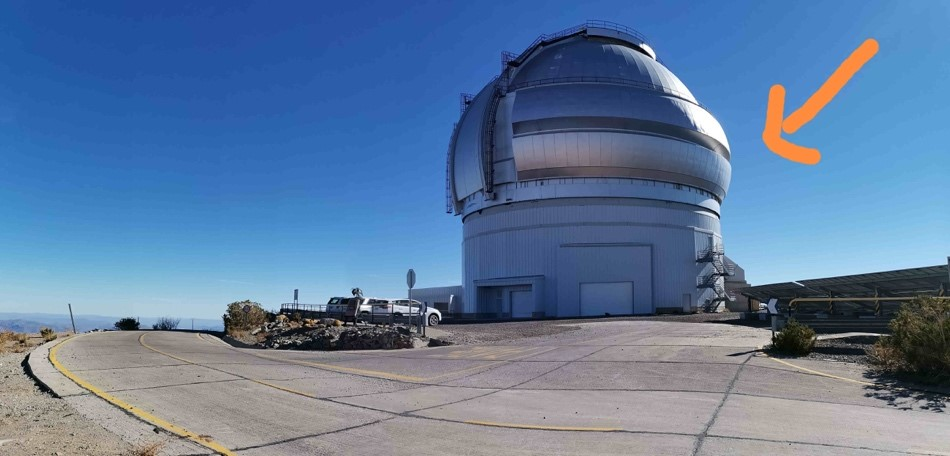

*Telescope dome vent gates, one of the vents is not vissible because it is in the oposite side.*

*“[Astronomical seeing](https://www.innovationsforesight.com/education/astronomical-seeing-tutorial/) refers to the blurring of astronomical objects caused by the Earth atmospheric turbulence. Thermal convection and winds produce turbulence cells having different optical refraction indexes, leading to perturbations and distortions of the incoming light wavefronts. It is worth noting that air motion and associated turbulence do not impact the light path itself, unless there is a change in refraction index, typically coming from temperature differences across the air mass involved in the process.”*

The seeing varies between 0.3 and 2.0 arc seconds approximately. A seeing of 0.3 is very good (stable and sharp image); in contrast, aseeing of 2.0 arc seconds is very bad (unstable and out of focus [blurry] image). For example this image of the Moon has high seeing measurement. [see example](https://upload.wikimedia.org/wikipedia/commons/e/ef/Seeing_Moon.gif)

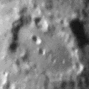

Moon image deteriorated because of the atmospheric turbulence.

## Vent Gate Raw Data

Upload Vent Gate raw data (for April, 2022) into R after manually removing header text, then check the structure and print a few records, and then save the data frame as *df202204a.Rdata*. Note that we extracted the tab delimited records first, this is because of the format the data was provided.

```r
df202204a = read.delim("D:/PROJECTS/R_Projects/Vent_Gates_Proj/VentGateProject-main/Datos_mes_edit_1/Vent_Gate_Project/apr1_30_bothVent_1.txt", header=FALSE, sep="\t")

str(df202204a)
```

```
## 'data.frame':    589256 obs. of  5 variables:
##  $ V1: chr  "04/01/2022 16:10:16.768737641" "04/01/2022 17:59:59.362571548" "04/01/2022 18:00:04.762571548" "04/01/2022 18:00:05.762571548" ...
##  $ V2: chr  "#N/A" "0.10638298" "0.12765957" "0.10638298" ...
##  $ V3: chr  "<no data>" "" "" "" ...
##  $ V4: chr  "0.23404255" "0.23404255" "0.23404255" "0.23404255" ...
##  $ V5: chr  "" "" "" "" ...
```

```r
head(df202204a)
```

```
##                              V1         V2        V3         V4 V5
## 1 04/01/2022 16:10:16.768737641       #N/A <no data> 0.23404255
## 2 04/01/2022 17:59:59.362571548 0.10638298           0.23404255
## 3 04/01/2022 18:00:04.762571548 0.12765957           0.23404255
## 4 04/01/2022 18:00:05.762571548 0.10638298           0.23404255
## 5 04/01/2022 18:00:09.762571548 0.12765957           0.23404255
## 6 04/01/2022 18:00:12.362571548 0.10638298           0.23404255
```

```r
save(df202204a, file="df202204a.Rdata")
```

Keep only columns *V1, V2, V4* and then check structure, print a few records, and save as *df202204b.Rdata*.

```r
df202204b = df202204a[, c('V1','V2','V4') ]

str(df202204b)
```

```
## 'data.frame':    589256 obs. of  3 variables:
##  $ V1: chr  "04/01/2022 16:10:16.768737641" "04/01/2022 17:59:59.362571548" "04/01/2022 18:00:04.762571548" "04/01/2022 18:00:05.762571548" ...
##  $ V2: chr  "#N/A" "0.10638298" "0.12765957" "0.10638298" ...
##  $ V4: chr  "0.23404255" "0.23404255" "0.23404255" "0.23404255" ...
```

```r
head(df202204b)
```

```
##                              V1         V2         V4
## 1 04/01/2022 16:10:16.768737641       #N/A 0.23404255
## 2 04/01/2022 17:59:59.362571548 0.10638298 0.23404255
## 3 04/01/2022 18:00:04.762571548 0.12765957 0.23404255
## 4 04/01/2022 18:00:05.762571548 0.10638298 0.23404255
## 5 04/01/2022 18:00:09.762571548 0.12765957 0.23404255
## 6 04/01/2022 18:00:12.362571548 0.10638298 0.23404255
```

```r
save(df202204b, file="df202204b.Rdata")
```

Note that all fields are character fields. Furthermore,inspection of the data shows some rows with *“#N/A”* values for *V2* and *V4*. The *“#N/A”* values were replaced by R missing values, and then a new data frame was produced and saved as *df202204c.RData*.

```r
library(naniar) #package to assign missing values to given values

df202204c <- df202204b %>% replace_with_na(replace = list( V2="#N/A", V4="#N/A"))

str(df202204c)
```

```
## 'data.frame':    589256 obs. of  3 variables:
##  $ V1: chr  "04/01/2022 16:10:16.768737641" "04/01/2022 17:59:59.362571548" "04/01/2022 18:00:04.762571548" "04/01/2022 18:00:05.762571548" ...
##  $ V2: chr  NA "0.10638298" "0.12765957" "0.10638298" ...
##  $ V4: chr  "0.23404255" "0.23404255" "0.23404255" "0.23404255" ...
```

```r
head(df202204c)
```

```
##                              V1         V2         V4
## 1 04/01/2022 16:10:16.768737641       <NA> 0.23404255
## 2 04/01/2022 17:59:59.362571548 0.10638298 0.23404255
## 3 04/01/2022 18:00:04.762571548 0.12765957 0.23404255
## 4 04/01/2022 18:00:05.762571548 0.10638298 0.23404255
## 5 04/01/2022 18:00:09.762571548 0.12765957 0.23404255
## 6 04/01/2022 18:00:12.362571548 0.10638298 0.23404255
```

```r
save(df202204c, file="df202204c.RData")
```

Convert *V2* and *V4* to numeric (*V2_num* and *V4_num*), and then round to nearest integer (*V2_nrnd* and *V4_nrnd*).

```r
library(dplyr)  #package to add mutate fuction

df202204c_num=mutate(df202204c,V2_num=as.numeric(df202204c$V2), V4_num=as.numeric(df202204c$V4))
df202204c_nrnd=mutate( df202204c_num, V2_rnd=round(df202204c_num$V2_num), V4_rnd=round(df202204c_num$V4_num))
str(df202204c_nrnd)
```

```
## 'data.frame':    589256 obs. of  7 variables:
##  $ V1    : chr  "04/01/2022 16:10:16.768737641" "04/01/2022 17:59:59.362571548" "04/01/2022 18:00:04.762571548" "04/01/2022 18:00:05.762571548" ...
##  $ V2    : chr  NA "0.10638298" "0.12765957" "0.10638298" ...
##  $ V4    : chr  "0.23404255" "0.23404255" "0.23404255" "0.23404255" ...
##  $ V2_num: num  NA 0.106 0.128 0.106 0.128 ...
##  $ V4_num: num  0.234 0.234 0.234 0.234 0.234 ...
##  $ V2_rnd: num  NA 0 0 0 0 0 0 0 0 0 ...
##  $ V4_rnd: num  0 0 0 0 0 0 0 0 0 0 ...
```

```r
head(df202204c_nrnd)
```

```
##                              V1         V2         V4    V2_num    V4_num
## 1 04/01/2022 16:10:16.768737641       <NA> 0.23404255        NA 0.2340425
## 2 04/01/2022 17:59:59.362571548 0.10638298 0.23404255 0.1063830 0.2340425
## 3 04/01/2022 18:00:04.762571548 0.12765957 0.23404255 0.1276596 0.2340425
## 4 04/01/2022 18:00:05.762571548 0.10638298 0.23404255 0.1063830 0.2340425
## 5 04/01/2022 18:00:09.762571548 0.12765957 0.23404255 0.1276596 0.2340425
## 6 04/01/2022 18:00:12.362571548 0.10638298 0.23404255 0.1063830 0.2340425
##   V2_rnd V4_rnd
## 1     NA      0
## 2      0      0
## 3      0      0
## 4      0      0
## 5      0      0
## 6      0      0
```

Split date-time field *V1* into *V1_date* and *V1_time* fields.

```r
library("stringr")
df202204c_nrnd$V1_date=substr(df202204c_nrnd$V1,1,10)
df202204c_nrnd$V1_time=substr(df202204c_nrnd$V1,11,23)
str(df202204c_nrnd)
```

```
## 'data.frame':    589256 obs. of  9 variables:
##  $ V1     : chr  "04/01/2022 16:10:16.768737641" "04/01/2022 17:59:59.362571548" "04/01/2022 18:00:04.762571548" "04/01/2022 18:00:05.762571548" ...
##  $ V2     : chr  NA "0.10638298" "0.12765957" "0.10638298" ...
##  $ V4     : chr  "0.23404255" "0.23404255" "0.23404255" "0.23404255" ...
##  $ V2_num : num  NA 0.106 0.128 0.106 0.128 ...
##  $ V4_num : num  0.234 0.234 0.234 0.234 0.234 ...
##  $ V2_rnd : num  NA 0 0 0 0 0 0 0 0 0 ...
##  $ V4_rnd : num  0 0 0 0 0 0 0 0 0 0 ...
##  $ V1_date: chr  "04/01/2022" "04/01/2022" "04/01/2022" "04/01/2022" ...
##  $ V1_time: chr  " 16:10:16.768" " 17:59:59.362" " 18:00:04.762" " 18:00:05.762" ...
```

```r
head(df202204c_nrnd)
```

```
##                              V1         V2         V4    V2_num    V4_num
## 1 04/01/2022 16:10:16.768737641       <NA> 0.23404255        NA 0.2340425
## 2 04/01/2022 17:59:59.362571548 0.10638298 0.23404255 0.1063830 0.2340425
## 3 04/01/2022 18:00:04.762571548 0.12765957 0.23404255 0.1276596 0.2340425
## 4 04/01/2022 18:00:05.762571548 0.10638298 0.23404255 0.1063830 0.2340425
## 5 04/01/2022 18:00:09.762571548 0.12765957 0.23404255 0.1276596 0.2340425
## 6 04/01/2022 18:00:12.362571548 0.10638298 0.23404255 0.1063830 0.2340425
##   V2_rnd V4_rnd    V1_date       V1_time
## 1     NA      0 04/01/2022  16:10:16.768
## 2      0      0 04/01/2022  17:59:59.362
## 3      0      0 04/01/2022  18:00:04.762
## 4      0      0 04/01/2022  18:00:05.762
## 5      0      0 04/01/2022  18:00:09.762
## 6      0      0 04/01/2022  18:00:12.362
```

Convert date-time field *V1* into a date-time field *V1_date_time* with POSIXct format. The numeric value of *V1_date_time* corresponds to the number of seconds since 1970. Then save data frame as *df202204c_nrnd.RData*.

```r
op <- options(digits.sec=9)
df202204c_nrnd$V1_date_time=as.POSIXct(df202204c_nrnd$V1, format="%m/%d/%Y %H:%M:%OS")
class(df202204c_nrnd$V1_date_time)
```

```
## [1] "POSIXct" "POSIXt"
```

```r
str(df202204c_nrnd$V1_date_time)
```

```
##  POSIXct[1:589256], format: "2022-04-01 16:10:16" "2022-04-01 17:59:59" "2022-04-01 18:00:04" ...
```

```r
head(unclass(df202204c_nrnd$V1_date_time)) # Number of seconds since 1970 for first 6 records
```

```
## [1] 1648854617 1648861199 1648861205 1648861206 1648861210 1648861212
```

```r
head(df202204c_nrnd$V1_date_time)          # POSIXct format for first 6 records
```

```
## [1] "2022-04-01 16:10:16 PDT" "2022-04-01 17:59:59 PDT"
## [3] "2022-04-01 18:00:04 PDT" "2022-04-01 18:00:05 PDT"
## [5] "2022-04-01 18:00:09 PDT" "2022-04-01 18:00:12 PDT"
```

```r
head(df202204c_nrnd)
```

```
##                              V1         V2         V4    V2_num    V4_num
## 1 04/01/2022 16:10:16.768737641       <NA> 0.23404255        NA 0.2340425
## 2 04/01/2022 17:59:59.362571548 0.10638298 0.23404255 0.1063830 0.2340425
## 3 04/01/2022 18:00:04.762571548 0.12765957 0.23404255 0.1276596 0.2340425
## 4 04/01/2022 18:00:05.762571548 0.10638298 0.23404255 0.1063830 0.2340425
## 5 04/01/2022 18:00:09.762571548 0.12765957 0.23404255 0.1276596 0.2340425
## 6 04/01/2022 18:00:12.362571548 0.10638298 0.23404255 0.1063830 0.2340425
##   V2_rnd V4_rnd    V1_date       V1_time        V1_date_time
## 1     NA      0 04/01/2022  16:10:16.768 2022-04-01 16:10:16
## 2      0      0 04/01/2022  17:59:59.362 2022-04-01 17:59:59
## 3      0      0 04/01/2022  18:00:04.762 2022-04-01 18:00:04
## 4      0      0 04/01/2022  18:00:05.762 2022-04-01 18:00:05
## 5      0      0 04/01/2022  18:00:09.762 2022-04-01 18:00:09
## 6      0      0 04/01/2022  18:00:12.362 2022-04-01 18:00:12
```

```r
save(df202204c_nrnd, file="df202204c_nrnd.RData")
options(op)
```

Prepare the data for concatenation with the seeing data by adding a column to align with the seeing measured by the P2 detector: a) Create Seeing indicator and set to zero; b) order columns.

```r
#Prepare Vent-Gate data for concatenation
df202204d=subset(df202204c_nrnd, select=c(V2_rnd,V4_rnd, V1_date,V1_date_time))
df202204e=mutate(df202204d, P2_ind=0)

#Reorder columns
df202204f=df202204e[, c("P2_ind","V1_date", "V1_date_time", "V2_rnd", "V4_rnd")]
str(df202204f)
```

```
## 'data.frame':    589256 obs. of  5 variables:
##  $ P2_ind      : num  0 0 0 0 0 0 0 0 0 0 ...
##  $ V1_date     : chr  "04/01/2022" "04/01/2022" "04/01/2022" "04/01/2022" ...
##  $ V1_date_time: POSIXct, format: "2022-04-01 16:10:16" "2022-04-01 17:59:59" ...
##  $ V2_rnd      : num  NA 0 0 0 0 0 0 0 0 0 ...
##  $ V4_rnd      : num  0 0 0 0 0 0 0 0 0 0 ...
```

```r
head(df202204f)
```

```
##   P2_ind    V1_date        V1_date_time V2_rnd V4_rnd
## 1      0 04/01/2022 2022-04-01 16:10:16     NA      0
## 2      0 04/01/2022 2022-04-01 17:59:59      0      0
## 3      0 04/01/2022 2022-04-01 18:00:04      0      0
## 4      0 04/01/2022 2022-04-01 18:00:05      0      0
## 5      0 04/01/2022 2022-04-01 18:00:09      0      0
## 6      0 04/01/2022 2022-04-01 18:00:12      0      0
```

```r
save(df202204f, file="df202204f.RData")

df202204f_VG <- df202204f

head(df202204f_VG)
```

```
##   P2_ind    V1_date        V1_date_time V2_rnd V4_rnd
## 1      0 04/01/2022 2022-04-01 16:10:16     NA      0
## 2      0 04/01/2022 2022-04-01 17:59:59      0      0
## 3      0 04/01/2022 2022-04-01 18:00:04      0      0
## 4      0 04/01/2022 2022-04-01 18:00:05      0      0
## 5      0 04/01/2022 2022-04-01 18:00:09      0      0
## 6      0 04/01/2022 2022-04-01 18:00:12      0      0
```

Rename V2_rnd to V2_rnd_VG_East and V4_rnd to V4_rnd_VG_West.

```r
#Rename V2_rnd to V2_rnd_VG_East and V4_rnd to V4_rnd_VG_West

library("tidyverse")
df202204g_VG = rename(df202204f_VG, c("V2_rnd_VG_East" = "V2_rnd", "V4_rnd_VG_West" = "V4_rnd"))
```

```r
str(df202204g_VG)
```

```
## 'data.frame':    589256 obs. of  5 variables:
##  $ P2_ind        : num  0 0 0 0 0 0 0 0 0 0 ...
##  $ V1_date       : chr  "04/01/2022" "04/01/2022" "04/01/2022" "04/01/2022" ...
##  $ V1_date_time  : POSIXct, format: "2022-04-01 16:10:16" "2022-04-01 17:59:59" ...
##  $ V2_rnd_VG_East: num  NA 0 0 0 0 0 0 0 0 0 ...
##  $ V4_rnd_VG_West: num  0 0 0 0 0 0 0 0 0 0 ...
```

```r
head(df202204g_VG, n = 6L)
```

```
##   P2_ind    V1_date        V1_date_time V2_rnd_VG_East V4_rnd_VG_West
## 1      0 04/01/2022 2022-04-01 16:10:16             NA              0
## 2      0 04/01/2022 2022-04-01 17:59:59              0              0
## 3      0 04/01/2022 2022-04-01 18:00:04              0              0
## 4      0 04/01/2022 2022-04-01 18:00:05              0              0
## 5      0 04/01/2022 2022-04-01 18:00:09              0              0
## 6      0 04/01/2022 2022-04-01 18:00:12              0              0
```

```r
save(df202204g_VG, file = "df202204g_VG.RData")
```

## Seeing Raw Data

Upload seeing raw data measured by the detector P2 (for April, 2022) into R after manually removing header text, then check the structure and print a few records, and then save the data frame as *df202204P2a.Rdata*. Note that we extracted the tab delimited records first, this is because of the format the data was provided.

```r
#read source text data
df202204P2a = read.delim("D:/PROJECTS/R_Projects/Vent_Gates_Proj/VentGateProject-main/Datos_mes_edit_1/Vent_Gate_Project/P2seeing_apr1_31_1.txt", header=FALSE, sep="\t")

#Check structure and View
str(df202204P2a)
```

```
## 'data.frame':    8467 obs. of  3 variables:
##  $ V1: chr  "04/01/2022 12:02:40.106355905" "04/01/2022 20:21:13.980065107" "04/01/2022 20:21:44.143955945" "04/02/2022 07:06:32.931230560" ...
##  $ V2: chr  "6.8260944" "0.48289563" "0.49089873" "#N/A" ...
##  $ V3: chr  "" "" "" "Disconnected" ...
```

```r
head(df202204P2a)
```

```
##                              V1         V2           V3
## 1 04/01/2022 12:02:40.106355905  6.8260944
## 2 04/01/2022 20:21:13.980065107 0.48289563
## 3 04/01/2022 20:21:44.143955945 0.49089873
## 4 04/02/2022 07:06:32.931230560       #N/A Disconnected
## 5 04/02/2022 07:06:32.931239067       #N/A  Archive_Off
## 6 04/02/2022 07:06:41.583477096 0.49089873
```

```r
#Save a copy of dataframe
save(df202204P2a, file="df202204P2a.Rdata")
```

Keep the first two columns.

```r
#Keep first 2 columns
df202204P2b = df202204P2a[, c('V1','V2') ]
str(df202204P2b)
```

```
## 'data.frame':    8467 obs. of  2 variables:
##  $ V1: chr  "04/01/2022 12:02:40.106355905" "04/01/2022 20:21:13.980065107" "04/01/2022 20:21:44.143955945" "04/02/2022 07:06:32.931230560" ...
##  $ V2: chr  "6.8260944" "0.48289563" "0.49089873" "#N/A" ...
```

```r
head(df202204P2b)
```

```
##                              V1         V2
## 1 04/01/2022 12:02:40.106355905  6.8260944
## 2 04/01/2022 20:21:13.980065107 0.48289563
## 3 04/01/2022 20:21:44.143955945 0.49089873
## 4 04/02/2022 07:06:32.931230560       #N/A
## 5 04/02/2022 07:06:32.931239067       #N/A
## 6 04/02/2022 07:06:41.583477096 0.49089873
```

Note that all fields are character fields. Furthermore, inspection of the data shows some rows with *“#N/A”* values for *V2*. The *“#N/A”* values were replaced by R missing values, and then a new data frame was produced and saved as *df202204P2c.RData*.

```r
df202204P2c <- df202204P2b %>% replace_with_na(replace = list( V2="#N/A"))

str(df202204P2c)
```

```
## 'data.frame':    8467 obs. of  2 variables:
##  $ V1: chr  "04/01/2022 12:02:40.106355905" "04/01/2022 20:21:13.980065107" "04/01/2022 20:21:44.143955945" "04/02/2022 07:06:32.931230560" ...
##  $ V2: chr  "6.8260944" "0.48289563" "0.49089873" NA ...
```

```r
head(df202204P2c)
```

```
##                              V1         V2
## 1 04/01/2022 12:02:40.106355905  6.8260944
## 2 04/01/2022 20:21:13.980065107 0.48289563
## 3 04/01/2022 20:21:44.143955945 0.49089873
## 4 04/02/2022 07:06:32.931230560       <NA>
## 5 04/02/2022 07:06:32.931239067       <NA>
## 6 04/02/2022 07:06:41.583477096 0.49089873
```

```r
save(df202204P2c, file="df202204P2c.RData")
```

```r
df202204P2d=mutate(df202204P2c,V2_seeing_num=as.numeric(df202204P2c$V2))
df202204P2e=mutate(df202204P2d, V2_seeing_rnd=round(df202204P2d$V2_seeing_num, digits=3))
str(df202204P2e)
```

```
## 'data.frame':    8467 obs. of  4 variables:
##  $ V1           : chr  "04/01/2022 12:02:40.106355905" "04/01/2022 20:21:13.980065107" "04/01/2022 20:21:44.143955945" "04/02/2022 07:06:32.931230560" ...
##  $ V2           : chr  "6.8260944" "0.48289563" "0.49089873" NA ...
##  $ V2_seeing_num: num  6.826 0.483 0.491 NA NA ...
##  $ V2_seeing_rnd: num  6.826 0.483 0.491 NA NA ...
```

```r
head(df202204P2e)
```

```
##                              V1         V2 V2_seeing_num V2_seeing_rnd
## 1 04/01/2022 12:02:40.106355905  6.8260944     6.8260944         6.826
## 2 04/01/2022 20:21:13.980065107 0.48289563     0.4828956         0.483
## 3 04/01/2022 20:21:44.143955945 0.49089873     0.4908987         0.491
## 4 04/02/2022 07:06:32.931230560       <NA>            NA            NA
## 5 04/02/2022 07:06:32.931239067       <NA>            NA            NA
## 6 04/02/2022 07:06:41.583477096 0.49089873     0.4908987         0.491
```

```r
df202204P2e$V1_date=substr(df202204P2e$V1,1,10)
df202204P2e$V1_time=substr(df202204P2e$V1,11,23)
df202204P2e$V1_date_time=as.POSIXct(df202204P2e$V1, format="%m/%d/%Y %H:%M:%OS")

str(df202204P2e$V1_date_time)
```

```
##  POSIXct[1:8467], format: "2022-04-01 12:02:40" "2022-04-01 20:21:13" "2022-04-01 20:21:44" ...
```

```r
head(unclass(df202204P2e$V1_date_time))
```

```
## [1] 1648839760 1648869674 1648869704 1648908393 1648908393 1648908402
```

```r
head(df202204P2e$V1_date_time)
```

```
## [1] "2022-04-01 12:02:40 PDT" "2022-04-01 20:21:13 PDT"
## [3] "2022-04-01 20:21:44 PDT" "2022-04-02 07:06:32 PDT"
## [5] "2022-04-02 07:06:32 PDT" "2022-04-02 07:06:41 PDT"
```

Flag dates and date-times when the detector P2 was active, and then keep those records for which P2 was active.

```r
#P2-active date selection indicator
df202204P2e$Date_in1=(df202204P2e$V1_date %in% c("04/02/2022",
                                                               "04/04/2022",
                                                               "04/05/2022",
                                                               "04/06/2022",
                                                               "04/07/2022",
                                                               "04/08/2022",
                                                               "04/10/2022",
                                                               "04/11/2022",
                                                               "04/16/2022",
                                                               "04/18/2022",
                                                               "04/19/2022",
                                                               "04/20/2022",
                                                               "04/21/2022",
                                                               "04/22/2022",
                                                               "04/23/2022",
                                                               "04/24/2022",
                                                               "04/25/2022",
                                                               "04/26/2022",
                                                               "04/27/2022",
                                                               "04/28/2022",
                                                               "04/29/2022",
                                                               "04/30/2022"))

#P2-active date-time selection indicator
#First time period for which P2 was active

df202204P2e$Datetime_in1 = (as.numeric(as.POSIXct("2022-04-02 23:01:00")) <= df202204P2e$V1_date_time & df202204P2e$V1_date_time < as.numeric(as.POSIXct("2022-04-02 23:34:59.999"))) +
  (as.numeric(as.POSIXct("2022-04-04 23:51:00")) <= df202204P2e$V1_date_time & df202204P2e$V1_date_time < as.numeric(as.POSIXct("2022-04-04 23:59:59.999"))) +
  (as.numeric(as.POSIXct("2022-04-05 00:00:00")) <= df202204P2e$V1_date_time & df202204P2e$V1_date_time < as.numeric(as.POSIXct("2022-04-05 2:56:59.999"))) +
  (as.numeric(as.POSIXct("2022-04-06 03:38:00")) <= df202204P2e$V1_date_time & df202204P2e$V1_date_time < as.numeric(as.POSIXct("2022-04-06 05:05:59.999"))) +
  (as.numeric(as.POSIXct("2022-04-07 02:44:00")) <= df202204P2e$V1_date_time & df202204P2e$V1_date_time < as.numeric(as.POSIXct("2022-04-07 03:31:59.999"))) +
  (as.numeric(as.POSIXct("2022-04-08 03:32:00")) <= df202204P2e$V1_date_time & df202204P2e$V1_date_time < as.numeric(as.POSIXct("2022-04-08 05:04:59.999"))) +
  (as.numeric(as.POSIXct("2022-04-10 05:25:00")) <= df202204P2e$V1_date_time & df202204P2e$V1_date_time < as.numeric(as.POSIXct("2022-04-10 06:01:59.999"))) +
  (as.numeric(as.POSIXct("2022-04-11 00:16:00")) <= df202204P2e$V1_date_time & df202204P2e$V1_date_time < as.numeric(as.POSIXct("2022-04-11 00:56:59.999"))) +
  (as.numeric(as.POSIXct("2022-04-16 02:07:00")) <= df202204P2e$V1_date_time & df202204P2e$V1_date_time < as.numeric(as.POSIXct("2022-04-16 02:25:59.999"))) +
  (as.numeric(as.POSIXct("2022-04-18 02:31:00")) <= df202204P2e$V1_date_time & df202204P2e$V1_date_time < as.numeric(as.POSIXct("2022-04-18 02:42:59.999"))) +
  (as.numeric(as.POSIXct("2022-04-19 00:00:00")) <= df202204P2e$V1_date_time & df202204P2e$V1_date_time < as.numeric(as.POSIXct("2022-04-19 03:58:59.999"))) +
  (as.numeric(as.POSIXct("2022-04-20 00:00:00")) <= df202204P2e$V1_date_time & df202204P2e$V1_date_time < as.numeric(as.POSIXct("2022-04-20 06:23:59.999"))) +
  (as.numeric(as.POSIXct("2022-04-21 00:25:00")) <= df202204P2e$V1_date_time & df202204P2e$V1_date_time < as.numeric(as.POSIXct("2022-04-21 06:17:59.999"))) +
  (as.numeric(as.POSIXct("2022-04-22 19:30:00")) <= df202204P2e$V1_date_time & df202204P2e$V1_date_time < as.numeric(as.POSIXct("2022-04-22 23:59:59.999"))) +
  (as.numeric(as.POSIXct("2022-04-23 00:00:00")) <= df202204P2e$V1_date_time & df202204P2e$V1_date_time < as.numeric(as.POSIXct("2022-04-23 06:41:59.999"))) +
  (as.numeric(as.POSIXct("2022-04-24 00:00:00")) <= df202204P2e$V1_date_time & df202204P2e$V1_date_time < as.numeric(as.POSIXct("2022-04-24 01:57:59.999"))) +
  (as.numeric(as.POSIXct("2022-04-25 00:00:00")) <= df202204P2e$V1_date_time & df202204P2e$V1_date_time < as.numeric(as.POSIXct("2022-04-25 05:31:59.999"))) +
  (as.numeric(as.POSIXct("2022-04-26 00:00:00")) <= df202204P2e$V1_date_time & df202204P2e$V1_date_time < as.numeric(as.POSIXct("2022-04-26 05:58:59.999"))) +
  (as.numeric(as.POSIXct("2022-04-27 01:11:00")) <= df202204P2e$V1_date_time & df202204P2e$V1_date_time < as.numeric(as.POSIXct("2022-04-27 02:53:59.999"))) +
  (as.numeric(as.POSIXct("2022-04-28 00:00:00")) <= df202204P2e$V1_date_time & df202204P2e$V1_date_time < as.numeric(as.POSIXct("2022-04-28 06:19:59.999"))) +
  (as.numeric(as.POSIXct("2022-04-29 00:04:00")) <= df202204P2e$V1_date_time & df202204P2e$V1_date_time < as.numeric(as.POSIXct("2022-04-29 03:21:59.999"))) +
  (as.numeric(as.POSIXct("2022-04-30 00:15:00")) <= df202204P2e$V1_date_time & df202204P2e$V1_date_time < as.numeric(as.POSIXct("2022-04-30 04:42:59.999"))) +

   #Second time period for which P2 was active

  (as.numeric(as.POSIXct("2022-04-05 04:32:00")) <= df202204P2e$V1_date_time & df202204P2e$V1_date_time < as.numeric(as.POSIXct("2022-04-05 04:50:59.999"))) +
  (as.numeric(as.POSIXct("2022-04-07 05:15:00")) <= df202204P2e$V1_date_time & df202204P2e$V1_date_time < as.numeric(as.POSIXct("2022-04-07 06:07:59.999"))) +
  (as.numeric(as.POSIXct("2022-04-18 19:57:00")) <= df202204P2e$V1_date_time & df202204P2e$V1_date_time < as.numeric(as.POSIXct("2022-04-18 20:13:59.999"))) +
  (as.numeric(as.POSIXct("2022-04-19 19:30:00")) <= df202204P2e$V1_date_time & df202204P2e$V1_date_time < as.numeric(as.POSIXct("2022-04-19 19:46:59.999"))) +
  (as.numeric(as.POSIXct("2022-04-20 19:30:00")) <= df202204P2e$V1_date_time & df202204P2e$V1_date_time < as.numeric(as.POSIXct("2022-04-20 20:54:59.999"))) +
  (as.numeric(as.POSIXct("2022-04-23 19:30:00")) <= df202204P2e$V1_date_time & df202204P2e$V1_date_time < as.numeric(as.POSIXct("2022-04-23 21:09:59.999"))) +
  (as.numeric(as.POSIXct("2022-04-24 03:42:00")) <= df202204P2e$V1_date_time & df202204P2e$V1_date_time < as.numeric(as.POSIXct("2022-04-24 06:12:59.999"))) +
  (as.numeric(as.POSIXct("2022-04-25 20:29:00")) <= df202204P2e$V1_date_time & df202204P2e$V1_date_time < as.numeric(as.POSIXct("2022-04-25 21:14:59.999"))) +
  (as.numeric(as.POSIXct("2022-04-27 21:19:00")) <= df202204P2e$V1_date_time & df202204P2e$V1_date_time < as.numeric(as.POSIXct("2022-04-27 23:59:59.999"))) +
  (as.numeric(as.POSIXct("2022-04-30 19:30:00")) <= df202204P2e$V1_date_time & df202204P2e$V1_date_time < as.numeric(as.POSIXct("2022-04-30 23:59:59.999"))) +

  #Third time period for which P2 was active

  (as.numeric(as.POSIXct("2022-04-18 23:10:00")) <= df202204P2e$V1_date_time & df202204P2e$V1_date_time < as.numeric(as.POSIXct("2022-04-18 23:59:59.999"))) +
  (as.numeric(as.POSIXct("2022-04-19 21:27:00")) <= df202204P2e$V1_date_time & df202204P2e$V1_date_time < as.numeric(as.POSIXct("2022-04-19 23:59:59.999"))) +
  (as.numeric(as.POSIXct("2022-04-23 22:57:00")) <= df202204P2e$V1_date_time & df202204P2e$V1_date_time < as.numeric(as.POSIXct("2022-04-23 23:59:59.999"))) +
  (as.numeric(as.POSIXct("2022-04-24 20:41:00")) <= df202204P2e$V1_date_time & df202204P2e$V1_date_time < as.numeric(as.POSIXct("2022-04-24 23:59:59.999"))) +
  (as.numeric(as.POSIXct("2022-04-25 23:12:59")) <= df202204P2e$V1_date_time & df202204P2e$V1_date_time < as.numeric(as.POSIXct("2022-04-25 999-23:59:59")))


#Filter valid P2 records
df202204P2f =df202204P2e[df202204P2e$Datetime_in1 > 0,]

str(df202204P2f)
```

```
## 'data.frame':    7755 obs. of  9 variables:
##  $ V1           : chr  "04/02/2022 23:01:14.130250930" "04/02/2022 23:01:44.294039011" "04/02/2022 23:02:14.458241939" "04/02/2022 23:02:44.622322082" ...
##  $ V2           : chr  "0.39821874" "0.44567433" "0.42914129" "0.41808554" ...
##  $ V2_seeing_num: num  0.398 0.446 0.429 0.418 0.339 ...
##  $ V2_seeing_rnd: num  0.398 0.446 0.429 0.418 0.339 ...
##  $ V1_date      : chr  "04/02/2022" "04/02/2022" "04/02/2022" "04/02/2022" ...
##  $ V1_time      : chr  " 23:01:14.130" " 23:01:44.294" " 23:02:14.458" " 23:02:44.622" ...
##  $ V1_date_time : POSIXct, format: "2022-04-02 23:01:14" "2022-04-02 23:01:44" ...
##  $ Date_in1     : logi  TRUE TRUE TRUE TRUE TRUE TRUE ...
##  $ Datetime_in1 : int  1 1 1 1 1 1 1 1 1 1 ...
```

```r
head(df202204P2f)
```

```
##                               V1         V2 V2_seeing_num V2_seeing_rnd
## 17 04/02/2022 23:01:14.130250930 0.39821874     0.3982187         0.398
## 18 04/02/2022 23:01:44.294039011 0.44567433     0.4456743         0.446
## 19 04/02/2022 23:02:14.458241939 0.42914129     0.4291413         0.429
## 20 04/02/2022 23:02:44.622322082 0.41808554     0.4180855         0.418
## 21 04/02/2022 23:03:14.786847114 0.33854191     0.3385419         0.339
## 22 04/02/2022 23:03:44.955780029 0.58897957     0.5889796         0.589
##       V1_date       V1_time        V1_date_time Date_in1 Datetime_in1
## 17 04/02/2022  23:01:14.130 2022-04-02 23:01:14     TRUE            1
## 18 04/02/2022  23:01:44.294 2022-04-02 23:01:44     TRUE            1
## 19 04/02/2022  23:02:14.458 2022-04-02 23:02:14     TRUE            1
## 20 04/02/2022  23:02:44.622 2022-04-02 23:02:44     TRUE            1
## 21 04/02/2022  23:03:14.786 2022-04-02 23:03:14     TRUE            1
## 22 04/02/2022  23:03:44.955 2022-04-02 23:03:44     TRUE            1
```

```r
#Save a copy of dataframe
save(df202204P2f, file="df202204P2f.Rdata")
```

Prepare the data for concatenation with the vent gate data: a) Create Seeing indicator and set to one; b) select and order columns.

```r
df202204P2g=subset(df202204P2f, select=c(V2_seeing_rnd, V1_date,V1_date_time))
df202204P2h=mutate(df202204P2g, P2_ind=1)
df202204P2i=df202204P2h[, c("P2_ind","V1_date", "V1_date_time", "V2_seeing_rnd")]
str(df202204P2i)
```

```
## 'data.frame':    7755 obs. of  4 variables:
##  $ P2_ind       : num  1 1 1 1 1 1 1 1 1 1 ...
##  $ V1_date      : chr  "04/02/2022" "04/02/2022" "04/02/2022" "04/02/2022" ...
##  $ V1_date_time : POSIXct, format: "2022-04-02 23:01:14" "2022-04-02 23:01:44" ...
##  $ V2_seeing_rnd: num  0.398 0.446 0.429 0.418 0.339 ...
```

```r
head(df202204P2i)
```

```
##   P2_ind    V1_date        V1_date_time V2_seeing_rnd
## 1      1 04/02/2022 2022-04-02 23:01:14         0.398
## 2      1 04/02/2022 2022-04-02 23:01:44         0.446
## 3      1 04/02/2022 2022-04-02 23:02:14         0.429
## 4      1 04/02/2022 2022-04-02 23:02:44         0.418
## 5      1 04/02/2022 2022-04-02 23:03:14         0.339
## 6      1 04/02/2022 2022-04-02 23:03:44         0.589
```

```r
#Save a copy of dataframe
save(df202204P2i, file="df202204P2i.Rdata")
```

## Merging Vent Gate and Seeing Data

Concatenate *df202204g_VG* and *df202204P2i* data frames and sort by V1_date_time_sorted.

```r
#Concatenate april2022P2_sub2 and april2022VG_sub2
df202204_VG_P2_a <-bind_rows(df202204P2i,df202204g_VG)
df202204_VG_P2_b =mutate(df202204_VG_P2_a,V1_date_time_num=as.numeric(df202204_VG_P2_a$V1_date_time))
V1_date_time_sorted <- order(df202204_VG_P2_b$V1_date_time_num)
df202204_VG_P2_c <- df202204_VG_P2_b[V1_date_time_sorted, ]
str(df202204_VG_P2_c)
```

```
## 'data.frame':    597011 obs. of  7 variables:
##  $ P2_ind          : num  0 0 0 0 0 0 0 0 0 0 ...
##  $ V1_date         : chr  "04/01/2022" "04/01/2022" "04/01/2022" "04/01/2022" ...
##  $ V1_date_time    : POSIXct, format: "2022-04-01 16:10:16" "2022-04-01 17:59:59" ...
##  $ V2_seeing_rnd   : num  NA NA NA NA NA NA NA NA NA NA ...
##  $ V2_rnd_VG_East  : num  NA 0 0 0 0 0 0 0 0 0 ...
##  $ V4_rnd_VG_West  : num  0 0 0 0 0 0 0 0 0 0 ...
##  $ V1_date_time_num: num  1.65e+09 1.65e+09 1.65e+09 1.65e+09 1.65e+09 ...
```

```r
head(df202204_VG_P2_c[df202204_VG_P2_c$V1_date_time_num  > 1651308780,]) #Print a few records with active
```

```
##        P2_ind    V1_date        V1_date_time V2_seeing_rnd V2_rnd_VG_East
## 592124      0 04/30/2022 2022-04-30 01:53:00            NA             80
## 7473        1 04/30/2022 2022-04-30 01:53:13         0.841             NA
## 7474        1 04/30/2022 2022-04-30 01:53:43         0.872             NA
## 7475        1 04/30/2022 2022-04-30 01:54:13         1.349             NA
## 592125      0 04/30/2022 2022-04-30 01:54:25            NA             80
## 592126      0 04/30/2022 2022-04-30 01:54:25            NA             80
##        V4_rnd_VG_West V1_date_time_num
## 592124              5       1651308780
## 7473               NA       1651308793
## 7474               NA       1651308823
## 7475               NA       1651308854
## 592125              5       1651308865
## 592126              5       1651308866
```

```r
head(df202204_VG_P2_c)
```

```
##      P2_ind    V1_date        V1_date_time V2_seeing_rnd V2_rnd_VG_East
## 7756      0 04/01/2022 2022-04-01 16:10:16            NA             NA
## 7757      0 04/01/2022 2022-04-01 17:59:59            NA              0
## 7758      0 04/01/2022 2022-04-01 18:00:04            NA              0
## 7759      0 04/01/2022 2022-04-01 18:00:05            NA              0
## 7760      0 04/01/2022 2022-04-01 18:00:09            NA              0
## 7761      0 04/01/2022 2022-04-01 18:00:12            NA              0
##      V4_rnd_VG_West V1_date_time_num
## 7756              0       1648854617
## 7757              0       1648861199
## 7758              0       1648861205
## 7759              0       1648861206
## 7760              0       1648861210
## 7761              0       1648861212
```

```r
save(df202204_VG_P2_c, file = "df202204_VG_P2_c.RData")
```

Add lag variables for the vent gate fields and P2_ind.

```r
df202204_VG_P2_d = mutate(df202204_VG_P2_c, lagvg_east=lag(V2_rnd_VG_East), lagvg_west=lag(V4_rnd_VG_West), lagp2_ind=lag(P2_ind), lag_date_time=lag(V1_date_time))
str(df202204_VG_P2_d)
```

```
## 'data.frame':    597011 obs. of  11 variables:
##  $ P2_ind          : num  0 0 0 0 0 0 0 0 0 0 ...
##  $ V1_date         : chr  "04/01/2022" "04/01/2022" "04/01/2022" "04/01/2022" ...
##  $ V1_date_time    : POSIXct, format: "2022-04-01 16:10:16" "2022-04-01 17:59:59" ...
##  $ V2_seeing_rnd   : num  NA NA NA NA NA NA NA NA NA NA ...
##  $ V2_rnd_VG_East  : num  NA 0 0 0 0 0 0 0 0 0 ...
##  $ V4_rnd_VG_West  : num  0 0 0 0 0 0 0 0 0 0 ...
##  $ V1_date_time_num: num  1.65e+09 1.65e+09 1.65e+09 1.65e+09 1.65e+09 ...
##  $ lagvg_east      : num  NA NA 0 0 0 0 0 0 0 0 ...
##  $ lagvg_west      : num  NA 0 0 0 0 0 0 0 0 0 ...
##  $ lagp2_ind       : num  NA 0 0 0 0 0 0 0 0 0 ...
##  $ lag_date_time   : POSIXct, format: NA "2022-04-01 16:10:16" ...
```

```r
head(df202204_VG_P2_d[df202204_VG_P2_d$V1_date_time_num  > 1651308780,]) #Print a few records which include P2 active
```

```
##        P2_ind    V1_date        V1_date_time V2_seeing_rnd V2_rnd_VG_East
## 591841      0 04/30/2022 2022-04-30 01:53:00            NA             80
## 591842      1 04/30/2022 2022-04-30 01:53:13         0.841             NA
## 591843      1 04/30/2022 2022-04-30 01:53:43         0.872             NA
## 591844      1 04/30/2022 2022-04-30 01:54:13         1.349             NA
## 591845      0 04/30/2022 2022-04-30 01:54:25            NA             80
## 591846      0 04/30/2022 2022-04-30 01:54:25            NA             80
##        V4_rnd_VG_West V1_date_time_num lagvg_east lagvg_west lagp2_ind
## 591841              5       1651308780         80          5         0
## 591842             NA       1651308793         80          5         0
## 591843             NA       1651308823         NA         NA         1
## 591844             NA       1651308854         NA         NA         1
## 591845              5       1651308865         NA         NA         1
## 591846              5       1651308866         80          5         0
##              lag_date_time
## 591841 2022-04-30 01:52:59
## 591842 2022-04-30 01:53:00
## 591843 2022-04-30 01:53:13
## 591844 2022-04-30 01:53:43
## 591845 2022-04-30 01:54:13
## 591846 2022-04-30 01:54:25
```

```r
save(df202204_VG_P2_d, file = "df202204_VG_P2_d.RData")
```

Keep only valid P2 records

```r
#Filter valid P2 records
df202204_VG_P2_e =df202204_VG_P2_d[df202204_VG_P2_d$P2_ind > 0,]
str(df202204_VG_P2_e)
```

```
## 'data.frame':    7755 obs. of  11 variables:
##  $ P2_ind          : num  1 1 1 1 1 1 1 1 1 1 ...
##  $ V1_date         : chr  "04/02/2022" "04/02/2022" "04/02/2022" "04/02/2022" ...
##  $ V1_date_time    : POSIXct, format: "2022-04-02 23:01:14" "2022-04-02 23:01:44" ...
##  $ V2_seeing_rnd   : num  0.398 0.446 0.429 0.418 0.339 ...
##  $ V2_rnd_VG_East  : num  NA NA NA NA NA NA NA NA NA NA ...
##  $ V4_rnd_VG_West  : num  NA NA NA NA NA NA NA NA NA NA ...
##  $ V1_date_time_num: num  1.65e+09 1.65e+09 1.65e+09 1.65e+09 1.65e+09 ...
##  $ lagvg_east      : num  30 30 30 30 30 30 30 30 30 30 ...
##  $ lagvg_west      : num  30 30 30 30 30 30 30 30 30 30 ...
##  $ lagp2_ind       : num  0 0 0 0 0 0 0 0 0 0 ...
##  $ lag_date_time   : POSIXct, format: "2022-04-02 23:01:09" "2022-04-02 23:01:43" ...
```

```r
head(df202204_VG_P2_e)
```

```
##       P2_ind    V1_date        V1_date_time V2_seeing_rnd V2_rnd_VG_East
## 40409      1 04/02/2022 2022-04-02 23:01:14         0.398             NA
## 40418      1 04/02/2022 2022-04-02 23:01:44         0.446             NA
## 40431      1 04/02/2022 2022-04-02 23:02:14         0.429             NA
## 40446      1 04/02/2022 2022-04-02 23:02:44         0.418             NA
## 40463      1 04/02/2022 2022-04-02 23:03:14         0.339             NA
## 40472      1 04/02/2022 2022-04-02 23:03:44         0.589             NA
##       V4_rnd_VG_West V1_date_time_num lagvg_east lagvg_west lagp2_ind
## 40409             NA       1648965674         30         30         0
## 40418             NA       1648965704         30         30         0
## 40431             NA       1648965734         30         30         0
## 40446             NA       1648965765         30         30         0
## 40463             NA       1648965795         30         30         0
## 40472             NA       1648965825         30         30         0
##             lag_date_time
## 40409 2022-04-02 23:01:09
## 40418 2022-04-02 23:01:43
## 40431 2022-04-02 23:02:10
## 40446 2022-04-02 23:02:39
## 40463 2022-04-02 23:03:12
## 40472 2022-04-02 23:03:30
```

Keep selected fields.

```r
df202204_VG_P2_f=subset(df202204_VG_P2_e, select=c(P2_ind, V1_date, V1_date_time, V2_seeing_rnd, V1_date_time_num,lagvg_east, lagvg_west, lagp2_ind,lag_date_time))
head(df202204_VG_P2_f)
```

```
##       P2_ind    V1_date        V1_date_time V2_seeing_rnd V1_date_time_num
## 40409      1 04/02/2022 2022-04-02 23:01:14         0.398       1648965674
## 40418      1 04/02/2022 2022-04-02 23:01:44         0.446       1648965704
## 40431      1 04/02/2022 2022-04-02 23:02:14         0.429       1648965734
## 40446      1 04/02/2022 2022-04-02 23:02:44         0.418       1648965765
## 40463      1 04/02/2022 2022-04-02 23:03:14         0.339       1648965795
## 40472      1 04/02/2022 2022-04-02 23:03:44         0.589       1648965825
##       lagvg_east lagvg_west lagp2_ind       lag_date_time
## 40409         30         30         0 2022-04-02 23:01:09
## 40418         30         30         0 2022-04-02 23:01:43
## 40431         30         30         0 2022-04-02 23:02:10
## 40446         30         30         0 2022-04-02 23:02:39
## 40463         30         30         0 2022-04-02 23:03:12
## 40472         30         30         0 2022-04-02 23:03:30
```

Create additional flags.

```r
df202204_VG_P2_g=mutate(df202204_VG_P2_f,lead1=lead(lagp2_ind), lpl_flag1=as.numeric(as.logical(lagp2_ind + lead1)) )
df202204_VG_P2_h=mutate(df202204_VG_P2_g, upchange=ifelse((lagp2_ind==0 & lead1==1),1,0))
str(df202204_VG_P2_g)
```

```
## 'data.frame':    7755 obs. of  11 variables:
##  $ P2_ind          : num  1 1 1 1 1 1 1 1 1 1 ...
##  $ V1_date         : chr  "04/02/2022" "04/02/2022" "04/02/2022" "04/02/2022" ...
##  $ V1_date_time    : POSIXct, format: "2022-04-02 23:01:14" "2022-04-02 23:01:44" ...
##  $ V2_seeing_rnd   : num  0.398 0.446 0.429 0.418 0.339 ...
##  $ V1_date_time_num: num  1.65e+09 1.65e+09 1.65e+09 1.65e+09 1.65e+09 ...
##  $ lagvg_east      : num  30 30 30 30 30 30 30 30 30 30 ...
##  $ lagvg_west      : num  30 30 30 30 30 30 30 30 30 30 ...
##  $ lagp2_ind       : num  0 0 0 0 0 0 0 0 0 0 ...
##  $ lag_date_time   : POSIXct, format: "2022-04-02 23:01:09" "2022-04-02 23:01:43" ...
##  $ lead1           : num  0 0 0 0 0 0 0 0 0 0 ...
##  $ lpl_flag1       : num  0 0 0 0 0 0 0 0 0 0 ...
```

```r
head(df202204_VG_P2_h[df202204_VG_P2_h$V1_date_time_num > 1648966227,], n=15L)
```

```
##    P2_ind    V1_date        V1_date_time V2_seeing_rnd V1_date_time_num
## 19      1 04/02/2022 2022-04-02 23:10:27         0.336       1648966227
## 20      1 04/02/2022 2022-04-02 23:10:57         0.363       1648966257
## 21      1 04/02/2022 2022-04-02 23:11:27         0.459       1648966287
## 22      1 04/02/2022 2022-04-02 23:11:57         0.344       1648966318
## 23      1 04/02/2022 2022-04-02 23:12:27         0.404       1648966348
## 24      1 04/02/2022 2022-04-02 23:12:57         0.395       1648966378
## 25      1 04/02/2022 2022-04-02 23:13:28         0.369       1648966408
## 26      1 04/02/2022 2022-04-02 23:13:58         0.919       1648966438
## 27      1 04/02/2022 2022-04-02 23:14:28         0.448       1648966468
## 28      1 04/02/2022 2022-04-02 23:14:58         0.537       1648966499
## 29      1 04/02/2022 2022-04-02 23:15:28         0.451       1648966529
## 30      1 04/02/2022 2022-04-02 23:15:58         0.353       1648966559
## 31      1 04/02/2022 2022-04-02 23:16:29         0.476       1648966589
## 32      1 04/02/2022 2022-04-02 23:16:59         0.363       1648966619
```

[output cut: 17 more lines]

```r
save(df202204_VG_P2_h, file = "df202204_VG_P2_h.RData")
```

Split data frame *df202204_VG_P2_h* into two data frames *df202204_VG_P2_i* and *df202204_VG_P2_j*. The data frame *df202204_VG_P2_i* contains all records with *lpl_flag1 > 0* that together with the *upchange* field will help to identify the groups of records for which the seeing needs to be averaged.

```r
df202204_VG_P2_i = df202204_VG_P2_h[df202204_VG_P2_h$lpl_flag1 > 0,]
df202204_VG_P2_j = df202204_VG_P2_h[df202204_VG_P2_h$lpl_flag1 == 0,]
head(df202204_VG_P2_i)
```

```
##    P2_ind    V1_date        V1_date_time V2_seeing_rnd V1_date_time_num
## 21      1 04/02/2022 2022-04-02 23:11:27         0.459       1648966287
## 22      1 04/02/2022 2022-04-02 23:11:57         0.344       1648966318
## 23      1 04/02/2022 2022-04-02 23:12:27         0.404       1648966348
## 24      1 04/02/2022 2022-04-02 23:12:57         0.395       1648966378
## 27      1 04/02/2022 2022-04-02 23:14:28         0.448       1648966468
## 28      1 04/02/2022 2022-04-02 23:14:58         0.537       1648966499
##    lagvg_east lagvg_west lagp2_ind       lag_date_time lead1 lpl_flag1 upchange
## 21         30         30         0 2022-04-02 23:11:09     1         1        1
## 22         NA         NA         1 2022-04-02 23:11:27     1         1        0
## 23         NA         NA         1 2022-04-02 23:11:57     1         1        0
## 24         NA         NA         1 2022-04-02 23:12:27     0         1        0
## 27         30         30         0 2022-04-02 23:14:03     1         1        1
## 28         NA         NA         1 2022-04-02 23:14:28     0         1        0
```

```r
head(df202204_VG_P2_j)
```

```
##   P2_ind    V1_date        V1_date_time V2_seeing_rnd V1_date_time_num
## 1      1 04/02/2022 2022-04-02 23:01:14         0.398       1648965674
## 2      1 04/02/2022 2022-04-02 23:01:44         0.446       1648965704
## 3      1 04/02/2022 2022-04-02 23:02:14         0.429       1648965734
## 4      1 04/02/2022 2022-04-02 23:02:44         0.418       1648965765
## 5      1 04/02/2022 2022-04-02 23:03:14         0.339       1648965795
## 6      1 04/02/2022 2022-04-02 23:03:44         0.589       1648965825
##   lagvg_east lagvg_west lagp2_ind       lag_date_time lead1 lpl_flag1 upchange
## 1         30         30         0 2022-04-02 23:01:09     0         0        0
## 2         30         30         0 2022-04-02 23:01:43     0         0        0
## 3         30         30         0 2022-04-02 23:02:10     0         0        0
## 4         30         30         0 2022-04-02 23:02:39     0         0        0
## 5         30         30         0 2022-04-02 23:03:12     0         0        0
## 6         30         30         0 2022-04-02 23:03:30     0         0        0
```

In the data frame *df202204_VG_P2_i* flag the various groups of records for which the seeing will be averaged. This is done calculating the cumulative sum for the field *upchange*.

```r
df202204_VG_P2_i$upchg_counter <- cumsum(df202204_VG_P2_i$upchange)
head(df202204_VG_P2_i, n=20L)
```

```
##    P2_ind    V1_date        V1_date_time V2_seeing_rnd V1_date_time_num
## 21      1 04/02/2022 2022-04-02 23:11:27         0.459       1648966287
## 22      1 04/02/2022 2022-04-02 23:11:57         0.344       1648966318
## 23      1 04/02/2022 2022-04-02 23:12:27         0.404       1648966348
## 24      1 04/02/2022 2022-04-02 23:12:57         0.395       1648966378
## 27      1 04/02/2022 2022-04-02 23:14:28         0.448       1648966468
## 28      1 04/02/2022 2022-04-02 23:14:58         0.537       1648966499
## 29      1 04/02/2022 2022-04-02 23:15:28         0.451       1648966529
## 30      1 04/02/2022 2022-04-02 23:15:58         0.353       1648966559
## 31      1 04/02/2022 2022-04-02 23:16:29         0.476       1648966589
## 32      1 04/02/2022 2022-04-02 23:16:59         0.363       1648966619
## 34      1 04/02/2022 2022-04-02 23:17:59         0.427       1648966680
## 35      1 04/02/2022 2022-04-02 23:18:29         0.532       1648966710
## 36      1 04/02/2022 2022-04-02 23:18:59         0.948       1648966740
## 37      1 04/02/2022 2022-04-02 23:19:30         0.490       1648966770
```

[output cut: 48 more lines]

For each group calculate the average seeing: *V2_seeing_mean*

```r
#aggregate
df202204_VG_P2_k = aggregate(df202204_VG_P2_i[, c("V2_seeing_rnd")], list(df202204_VG_P2_i$upchg_counter), mean)
str(df202204_VG_P2_k)
```

```
## 'data.frame':    765 obs. of  2 variables:
##  $ Group.1: num  1 2 3 4 5 6 7 8 9 10 ...
##  $ x      : num  0.401 0.493 0.402 0.419 0.48 ...
```

```r
colnames(df202204_VG_P2_k)
```

```
## [1] "Group.1" "x"
```

```r
names(df202204_VG_P2_k)[names(df202204_VG_P2_k) == "Group.1"] <- "upchg_counter"
names(df202204_VG_P2_k)[names(df202204_VG_P2_k) == "x"] <- "V2_seeing_mean"
colnames(df202204_VG_P2_k)
```

```
## [1] "upchg_counter"  "V2_seeing_mean"
```

```r
head(df202204_VG_P2_k, n=20L)
```

```
##    upchg_counter V2_seeing_mean
## 1              1      0.4005000
## 2              2      0.4925000
## 3              3      0.4020000
## 4              4      0.4195000
## 5              5      0.4795000
## 6              6      0.7190000
## 7              7      0.3625000
## 8              8      0.4520000
## 9              9      0.4226667
## 10            10      0.5890000
## 11            11      0.4040000
## 12            12      0.4480000
## 13            13      0.3590000
## 14            14      0.8630000
## 15            15      0.5330000
## 16            16      0.6745000
## 17            17      1.1595000
## 18            18      0.8953333
## 19            19      0.8070000
## 20            20      0.5560000
```

Keep only rows with *lagvg_east* non missing (NA) and selected columns from *df202204_VG_P2_i* and produce the data frame *df202204_VG_P2_m*.

```r
#Keep only non NA rows and subset columns
df202204_VG_P2_l = df202204_VG_P2_i[!is.na(df202204_VG_P2_i$lagvg_east)=="TRUE",]
df202204_VG_P2_m = df202204_VG_P2_l[, c("P2_ind", "V1_date", "V1_date_time", "V1_date_time_num", "lagvg_east", "lagvg_west", "upchg_counter","lag_date_time")]
str(df202204_VG_P2_m)
```

```
## 'data.frame':    765 obs. of  8 variables:
##  $ P2_ind          : num  1 1 1 1 1 1 1 1 1 1 ...
##  $ V1_date         : chr  "04/02/2022" "04/02/2022" "04/02/2022" "04/02/2022" ...
##  $ V1_date_time    : POSIXct, format: "2022-04-02 23:11:27" "2022-04-02 23:14:28" ...
##  $ V1_date_time_num: num  1.65e+09 1.65e+09 1.65e+09 1.65e+09 1.65e+09 ...
##  $ lagvg_east      : num  30 30 30 30 30 30 30 30 30 30 ...
##  $ lagvg_west      : num  30 30 30 30 30 30 30 30 30 30 ...
##  $ upchg_counter   : num  1 2 3 4 5 6 7 8 9 10 ...
##  $ lag_date_time   : POSIXct, format: "2022-04-02 23:11:09" "2022-04-02 23:14:03" ...
```

```r
head(df202204_VG_P2_m)
```

```
##    P2_ind    V1_date        V1_date_time V1_date_time_num lagvg_east lagvg_west
## 21      1 04/02/2022 2022-04-02 23:11:27       1648966287         30         30
## 27      1 04/02/2022 2022-04-02 23:14:28       1648966468         30         30
## 29      1 04/02/2022 2022-04-02 23:15:28       1648966529         30         30
## 31      1 04/02/2022 2022-04-02 23:16:29       1648966589         30         30
## 34      1 04/02/2022 2022-04-02 23:17:59       1648966680         30         30
## 36      1 04/02/2022 2022-04-02 23:18:59       1648966740         30         30
##    upchg_counter       lag_date_time
## 21             1 2022-04-02 23:11:09
## 27             2 2022-04-02 23:14:03
## 29             3 2022-04-02 23:15:25
## 31             4 2022-04-02 23:16:22
## 34             5 2022-04-02 23:17:58
## 36             6 2022-04-02 23:18:46
```

Merge *df202204_VG_P2_m* and *df202204_VG_P2_k* by *upchg_counter* to append the seeing mean *V2_seeing_mean* to *df202204_VG_P2_m*.

```r
df202204_VG_P2_n = merge(df202204_VG_P2_m, df202204_VG_P2_k, by = "upchg_counter")
str(df202204_VG_P2_n)
```

```
## 'data.frame':    765 obs. of  9 variables:
##  $ upchg_counter   : num  1 2 3 4 5 6 7 8 9 10 ...
##  $ P2_ind          : num  1 1 1 1 1 1 1 1 1 1 ...
##  $ V1_date         : chr  "04/02/2022" "04/02/2022" "04/02/2022" "04/02/2022" ...
##  $ V1_date_time    : POSIXct, format: "2022-04-02 23:11:27" "2022-04-02 23:14:28" ...
##  $ V1_date_time_num: num  1.65e+09 1.65e+09 1.65e+09 1.65e+09 1.65e+09 ...
##  $ lagvg_east      : num  30 30 30 30 30 30 30 30 30 30 ...
##  $ lagvg_west      : num  30 30 30 30 30 30 30 30 30 30 ...
##  $ lag_date_time   : POSIXct, format: "2022-04-02 23:11:09" "2022-04-02 23:14:03" ...
##  $ V2_seeing_mean  : num  0.401 0.493 0.402 0.419 0.48 ...
```

```r
head(df202204_VG_P2_n)
```

```
##   upchg_counter P2_ind    V1_date        V1_date_time V1_date_time_num
## 1             1      1 04/02/2022 2022-04-02 23:11:27       1648966287
## 2             2      1 04/02/2022 2022-04-02 23:14:28       1648966468
## 3             3      1 04/02/2022 2022-04-02 23:15:28       1648966529
## 4             4      1 04/02/2022 2022-04-02 23:16:29       1648966589
## 5             5      1 04/02/2022 2022-04-02 23:17:59       1648966680
## 6             6      1 04/02/2022 2022-04-02 23:18:59       1648966740
##   lagvg_east lagvg_west       lag_date_time V2_seeing_mean
## 1         30         30 2022-04-02 23:11:09         0.4005
## 2         30         30 2022-04-02 23:14:03         0.4925
## 3         30         30 2022-04-02 23:15:25         0.4020
## 4         30         30 2022-04-02 23:16:22         0.4195
## 5         30         30 2022-04-02 23:17:58         0.4795
## 6         30         30 2022-04-02 23:18:46         0.7190
```

Change the name of group variable *upchg_counter* to *group*.

```r
#Change name of group variable
names(df202204_VG_P2_n)[names(df202204_VG_P2_n)=="upchg_counter"] <- "group"
head(df202204_VG_P2_n)
```

```
##   group P2_ind    V1_date        V1_date_time V1_date_time_num lagvg_east
## 1     1      1 04/02/2022 2022-04-02 23:11:27       1648966287         30
## 2     2      1 04/02/2022 2022-04-02 23:14:28       1648966468         30
## 3     3      1 04/02/2022 2022-04-02 23:15:28       1648966529         30
## 4     4      1 04/02/2022 2022-04-02 23:16:29       1648966589         30
## 5     5      1 04/02/2022 2022-04-02 23:17:59       1648966680         30
## 6     6      1 04/02/2022 2022-04-02 23:18:59       1648966740         30
##   lagvg_west       lag_date_time V2_seeing_mean
## 1         30 2022-04-02 23:11:09         0.4005
## 2         30 2022-04-02 23:14:03         0.4925
## 3         30 2022-04-02 23:15:25         0.4020
## 4         30 2022-04-02 23:16:22         0.4195
## 5         30 2022-04-02 23:17:58         0.4795
## 6         30 2022-04-02 23:18:46         0.7190
```

```r
save(df202204_VG_P2_n, file = "df202204_VG_P2_n.RData")
```

Select and order coulmns for *df202204_VG_P2_j*.

```r
df202204_VG_P2_o = df202204_VG_P2_j[, c("upchange", "P2_ind", "V1_date", "V1_date_time", "V1_date_time_num", "lagvg_east", "lagvg_west","V2_seeing_rnd","lag_date_time" )]
head(df202204_VG_P2_o)
```

```
##   upchange P2_ind    V1_date        V1_date_time V1_date_time_num lagvg_east
## 1        0      1 04/02/2022 2022-04-02 23:01:14       1648965674         30
## 2        0      1 04/02/2022 2022-04-02 23:01:44       1648965704         30
## 3        0      1 04/02/2022 2022-04-02 23:02:14       1648965734         30
## 4        0      1 04/02/2022 2022-04-02 23:02:44       1648965765         30
## 5        0      1 04/02/2022 2022-04-02 23:03:14       1648965795         30
## 6        0      1 04/02/2022 2022-04-02 23:03:44       1648965825         30
##   lagvg_west V2_seeing_rnd       lag_date_time
## 1         30         0.398 2022-04-02 23:01:09
## 2         30         0.446 2022-04-02 23:01:43
## 3         30         0.429 2022-04-02 23:02:10
## 4         30         0.418 2022-04-02 23:02:39
## 5         30         0.339 2022-04-02 23:03:12
## 6         30         0.589 2022-04-02 23:03:30
```

Rename “upchange” to “group” and “V2_seeing_rnd” to “V2_seeing_mean”

```r
#Rename "upchange" to "group" and "V2_seeing_rnd" to "V2_seeing_mean"
names(df202204_VG_P2_o)[names(df202204_VG_P2_o)=="upchange"] <- "group"
names(df202204_VG_P2_o)[names(df202204_VG_P2_o)=="V2_seeing_rnd"] <- "V2_seeing_mean"
str(df202204_VG_P2_o)
```

```
## 'data.frame':    4960 obs. of  9 variables:
##  $ group           : num  0 0 0 0 0 0 0 0 0 0 ...
##  $ P2_ind          : num  1 1 1 1 1 1 1 1 1 1 ...
##  $ V1_date         : chr  "04/02/2022" "04/02/2022" "04/02/2022" "04/02/2022" ...
##  $ V1_date_time    : POSIXct, format: "2022-04-02 23:01:14" "2022-04-02 23:01:44" ...
##  $ V1_date_time_num: num  1.65e+09 1.65e+09 1.65e+09 1.65e+09 1.65e+09 ...
##  $ lagvg_east      : num  30 30 30 30 30 30 30 30 30 30 ...
##  $ lagvg_west      : num  30 30 30 30 30 30 30 30 30 30 ...
##  $ V2_seeing_mean  : num  0.398 0.446 0.429 0.418 0.339 ...
##  $ lag_date_time   : POSIXct, format: "2022-04-02 23:01:09" "2022-04-02 23:01:43" ...
```

```r
head(df202204_VG_P2_o)
```

```
##   group P2_ind    V1_date        V1_date_time V1_date_time_num lagvg_east
## 1     0      1 04/02/2022 2022-04-02 23:01:14       1648965674         30
## 2     0      1 04/02/2022 2022-04-02 23:01:44       1648965704         30
## 3     0      1 04/02/2022 2022-04-02 23:02:14       1648965734         30
## 4     0      1 04/02/2022 2022-04-02 23:02:44       1648965765         30
## 5     0      1 04/02/2022 2022-04-02 23:03:14       1648965795         30
## 6     0      1 04/02/2022 2022-04-02 23:03:44       1648965825         30
##   lagvg_west V2_seeing_mean       lag_date_time
## 1         30          0.398 2022-04-02 23:01:09
## 2         30          0.446 2022-04-02 23:01:43
## 3         30          0.429 2022-04-02 23:02:10
## 4         30          0.418 2022-04-02 23:02:39
## 5         30          0.339 2022-04-02 23:03:12
## 6         30          0.589 2022-04-02 23:03:30
```

```r
save(df202204_VG_P2_o, file = "df202204_VG_P2_o.RData")
```

Concatenate *df202204_VG_P2_n* (open Vent Gate measurment with multiple Seeing measurements) and *df202204_VG_P2_o* (open Vent Gate measurment with unique seeing [P2] measurement)

```r
#Concatenate df202204_VG_P2_n (open Vent Gate measurment with multiple Seeing measurements) and
#df202204_VG_P2_o (open Vent Gate measurment with unique seeing measurement)
df202204_VG_P2_p=bind_rows(df202204_VG_P2_o, df202204_VG_P2_n )
head(df202204_VG_P2_p)
```

```
##   group P2_ind    V1_date        V1_date_time V1_date_time_num lagvg_east
## 1     0      1 04/02/2022 2022-04-02 23:01:14       1648965674         30
## 2     0      1 04/02/2022 2022-04-02 23:01:44       1648965704         30
## 3     0      1 04/02/2022 2022-04-02 23:02:14       1648965734         30
## 4     0      1 04/02/2022 2022-04-02 23:02:44       1648965765         30
## 5     0      1 04/02/2022 2022-04-02 23:03:14       1648965795         30
## 6     0      1 04/02/2022 2022-04-02 23:03:44       1648965825         30
##   lagvg_west V2_seeing_mean       lag_date_time
## 1         30          0.398 2022-04-02 23:01:09
## 2         30          0.446 2022-04-02 23:01:43
## 3         30          0.429 2022-04-02 23:02:10
## 4         30          0.418 2022-04-02 23:02:39
## 5         30          0.339 2022-04-02 23:03:12
## 6         30          0.589 2022-04-02 23:03:30
```

Sort and save the resulting data frame

```r
# sort data
V1_date_time_sorted <- order(df202204_VG_P2_p$V1_date_time_num)
df202204_VG_P2_q <- df202204_VG_P2_p[V1_date_time_sorted, ]
str(df202204_VG_P2_q)
```

```
## 'data.frame':    5725 obs. of  9 variables:
##  $ group           : num  0 0 0 0 0 0 0 0 0 0 ...
##  $ P2_ind          : num  1 1 1 1 1 1 1 1 1 1 ...
##  $ V1_date         : chr  "04/02/2022" "04/02/2022" "04/02/2022" "04/02/2022" ...
##  $ V1_date_time    : POSIXct, format: "2022-04-02 23:01:14" "2022-04-02 23:01:44" ...
##  $ V1_date_time_num: num  1.65e+09 1.65e+09 1.65e+09 1.65e+09 1.65e+09 ...
##  $ lagvg_east      : num  30 30 30 30 30 30 30 30 30 30 ...
##  $ lagvg_west      : num  30 30 30 30 30 30 30 30 30 30 ...
##  $ V2_seeing_mean  : num  0.398 0.446 0.429 0.418 0.339 ...
##  $ lag_date_time   : POSIXct, format: "2022-04-02 23:01:09" "2022-04-02 23:01:43" ...
```

```r
head(df202204_VG_P2_q[df202204_VG_P2_q$V1_date_time_num > 1648966197,], n=10L)
```

```
##         group P2_ind    V1_date        V1_date_time V1_date_time_num lagvg_east
## 19          0      1 04/02/2022 2022-04-02 23:10:27       1648966227         30
## 20          0      1 04/02/2022 2022-04-02 23:10:57       1648966257         30
## ...4961     1      1 04/02/2022 2022-04-02 23:11:27       1648966287         30
## 25          0      1 04/02/2022 2022-04-02 23:13:28       1648966408         30
## 26          0      1 04/02/2022 2022-04-02 23:13:58       1648966438         30
## ...4962     2      1 04/02/2022 2022-04-02 23:14:28       1648966468         30
## ...4963     3      1 04/02/2022 2022-04-02 23:15:28       1648966529         30
## ...4964     4      1 04/02/2022 2022-04-02 23:16:29       1648966589         30
## 33          0      1 04/02/2022 2022-04-02 23:17:29       1648966649         30
## ...4965     5      1 04/02/2022 2022-04-02 23:17:59       1648966680         30
##         lagvg_west V2_seeing_mean       lag_date_time
## 19              30         0.3360 2022-04-02 23:10:26
## 20              30         0.3630 2022-04-02 23:10:55
## ...4961         30         0.4005 2022-04-02 23:11:09
## 25              30         0.3690 2022-04-02 23:13:26
## 26              30         0.9190 2022-04-02 23:13:46
## ...4962         30         0.4925 2022-04-02 23:14:03
## ...4963         30         0.4020 2022-04-02 23:15:25
## ...4964         30         0.4195 2022-04-02 23:16:22
## 33              30         0.3820 2022-04-02 23:17:26
## ...4965         30         0.4795 2022-04-02 23:17:58
```

```r
tail(df202204_VG_P2_q)
```

```
##      group P2_ind    V1_date        V1_date_time V1_date_time_num lagvg_east
## 7750     0      1 04/30/2022 2022-04-30 04:39:14       1651318754          5
## 7751     0      1 04/30/2022 2022-04-30 04:39:44       1651318784          5
## 7752     0      1 04/30/2022 2022-04-30 04:40:28       1651318829          5
## 7753     0      1 04/30/2022 2022-04-30 04:41:04       1651318865          5
## 7754     0      1 04/30/2022 2022-04-30 04:41:41       1651318901          5
## NA      NA     NA       <NA>                <NA>               NA         NA
##      lagvg_west V2_seeing_mean       lag_date_time
## 7750         80          3.741 2022-04-30 04:39:11
## 7751         80          6.001 2022-04-30 04:39:40
## 7752         80          4.896 2022-04-30 04:40:24
## 7753         80          4.892 2022-04-30 04:41:02
## 7754         80          3.577 2022-04-30 04:41:40
## NA           NA             NA                <NA>
```

```r
#Save a copy of dataframe
save(df202204_VG_P2_q, file = "df202204_VG_P2_q.RData")
```

Drop last row with all NAs produced by lag functions, and then save data frame with vent gate and seeing data.

```r
#Drop row with all NA (Last row)
df202204_VG_P2_r = df202204_VG_P2_q[rowSums(is.na(df202204_VG_P2_q)) != ncol(df202204_VG_P2_q),]
head(df202204_VG_P2_r[df202204_VG_P2_r$V1_date_time_num > 1648966197,], n=10L)
```

```
##         group P2_ind    V1_date        V1_date_time V1_date_time_num lagvg_east
## 19          0      1 04/02/2022 2022-04-02 23:10:27       1648966227         30
## 20          0      1 04/02/2022 2022-04-02 23:10:57       1648966257         30
## ...4961     1      1 04/02/2022 2022-04-02 23:11:27       1648966287         30
## 25          0      1 04/02/2022 2022-04-02 23:13:28       1648966408         30
## 26          0      1 04/02/2022 2022-04-02 23:13:58       1648966438         30
## ...4962     2      1 04/02/2022 2022-04-02 23:14:28       1648966468         30
## ...4963     3      1 04/02/2022 2022-04-02 23:15:28       1648966529         30
## ...4964     4      1 04/02/2022 2022-04-02 23:16:29       1648966589         30
## 33          0      1 04/02/2022 2022-04-02 23:17:29       1648966649         30
## ...4965     5      1 04/02/2022 2022-04-02 23:17:59       1648966680         30
##         lagvg_west V2_seeing_mean       lag_date_time
## 19              30         0.3360 2022-04-02 23:10:26
## 20              30         0.3630 2022-04-02 23:10:55
## ...4961         30         0.4005 2022-04-02 23:11:09
## 25              30         0.3690 2022-04-02 23:13:26
## 26              30         0.9190 2022-04-02 23:13:46
## ...4962         30         0.4925 2022-04-02 23:14:03
## ...4963         30         0.4020 2022-04-02 23:15:25
## ...4964         30         0.4195 2022-04-02 23:16:22
## 33              30         0.3820 2022-04-02 23:17:26
## ...4965         30         0.4795 2022-04-02 23:17:58
```

```r
tail(df202204_VG_P2_r)
```

```
##      group P2_ind    V1_date        V1_date_time V1_date_time_num lagvg_east
## 7749     0      1 04/30/2022 2022-04-30 04:38:44       1651318724          5
## 7750     0      1 04/30/2022 2022-04-30 04:39:14       1651318754          5
## 7751     0      1 04/30/2022 2022-04-30 04:39:44       1651318784          5
## 7752     0      1 04/30/2022 2022-04-30 04:40:28       1651318829          5
## 7753     0      1 04/30/2022 2022-04-30 04:41:04       1651318865          5
## 7754     0      1 04/30/2022 2022-04-30 04:41:41       1651318901          5
##      lagvg_west V2_seeing_mean       lag_date_time
## 7749         80          1.176 2022-04-30 04:38:43
## 7750         80          3.741 2022-04-30 04:39:11
## 7751         80          6.001 2022-04-30 04:39:40
## 7752         80          4.896 2022-04-30 04:40:24
## 7753         80          4.892 2022-04-30 04:41:02
## 7754         80          3.577 2022-04-30 04:41:40
```

```r
#Save a copy of dataframe
save(df202204_VG_P2_r, file = "df202204_VG_P2_r.RData")
```

## Data Exploration

Add flag *Seeing_BG* to identify high average seeing measured by P2.

```r
#Add an indicator for Seeing
df202204_VG_P2_s=mutate(df202204_VG_P2_r, Seeing_BG=ifelse(V2_seeing_mean >=1.2,1,0) )
str(df202204_VG_P2_s)
```

```
## 'data.frame':    5724 obs. of  10 variables:
##  $ group           : num  0 0 0 0 0 0 0 0 0 0 ...
##  $ P2_ind          : num  1 1 1 1 1 1 1 1 1 1 ...
##  $ V1_date         : chr  "04/02/2022" "04/02/2022" "04/02/2022" "04/02/2022" ...
##  $ V1_date_time    : POSIXct, format: "2022-04-02 23:01:14" "2022-04-02 23:01:44" ...
##  $ V1_date_time_num: num  1.65e+09 1.65e+09 1.65e+09 1.65e+09 1.65e+09 ...
##  $ lagvg_east      : num  30 30 30 30 30 30 30 30 30 30 ...
##  $ lagvg_west      : num  30 30 30 30 30 30 30 30 30 30 ...
##  $ V2_seeing_mean  : num  0.398 0.446 0.429 0.418 0.339 ...
##  $ lag_date_time   : POSIXct, format: "2022-04-02 23:01:09" "2022-04-02 23:01:43" ...
##  $ Seeing_BG       : num  0 0 0 0 0 0 0 0 0 0 ...
```

```r
head(df202204_VG_P2_s)
```

```
##   group P2_ind    V1_date        V1_date_time V1_date_time_num lagvg_east
## 1     0      1 04/02/2022 2022-04-02 23:01:14       1648965674         30
## 2     0      1 04/02/2022 2022-04-02 23:01:44       1648965704         30
## 3     0      1 04/02/2022 2022-04-02 23:02:14       1648965734         30
## 4     0      1 04/02/2022 2022-04-02 23:02:44       1648965765         30
## 5     0      1 04/02/2022 2022-04-02 23:03:14       1648965795         30
## 6     0      1 04/02/2022 2022-04-02 23:03:44       1648965825         30
##   lagvg_west V2_seeing_mean       lag_date_time Seeing_BG
## 1         30          0.398 2022-04-02 23:01:09         0
## 2         30          0.446 2022-04-02 23:01:43         0
## 3         30          0.429 2022-04-02 23:02:10         0
## 4         30          0.418 2022-04-02 23:02:39         0
## 5         30          0.339 2022-04-02 23:03:12         0
## 6         30          0.589 2022-04-02 23:03:30         0
```

Check the distribution of *lagvg_east*, *lagvg_west*, *V2_seeing_mean* and *Seeing_BG*.

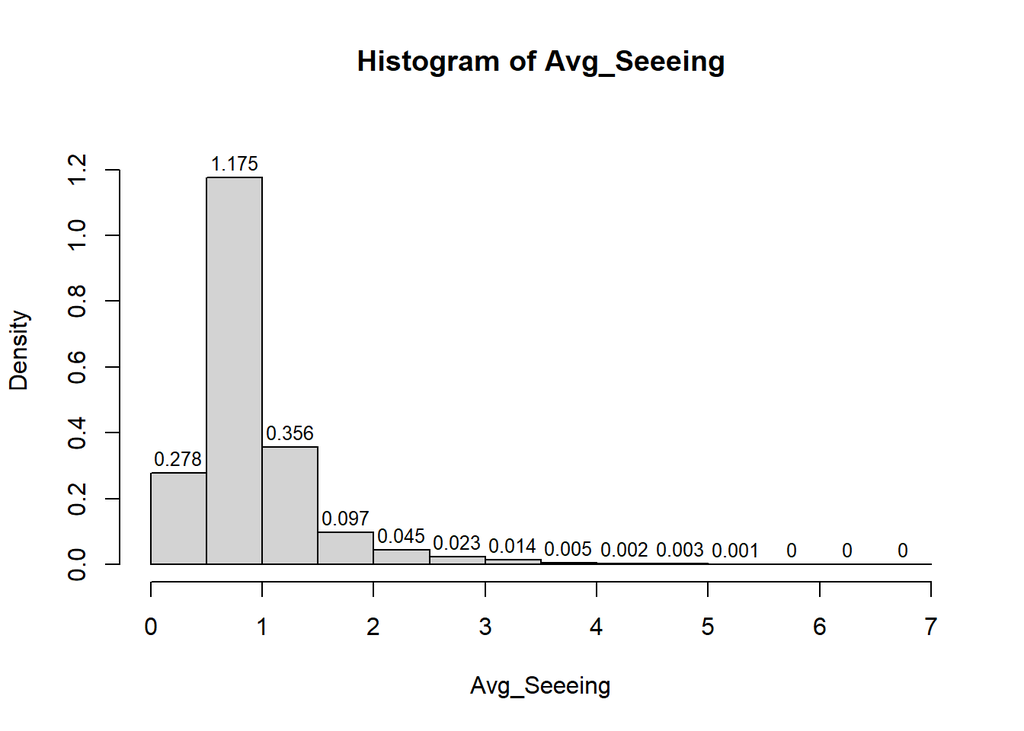

```r
#Produce a density histogram
Avg_Seeeing <- df202204_VG_P2_s$V2_seeing_mean

h <-hist(Avg_Seeeing, freq=FALSE, breaks=c(0,0.5,1,1.5,2,2.5,3,3.5,4,4.5,5,5.5,6,6.5,7),ylim=c(0,1.3))
text(h$mids,h$density,labels=round(h$density,digits=3), adj=c(0.5, -0.5), cex=.8)
```

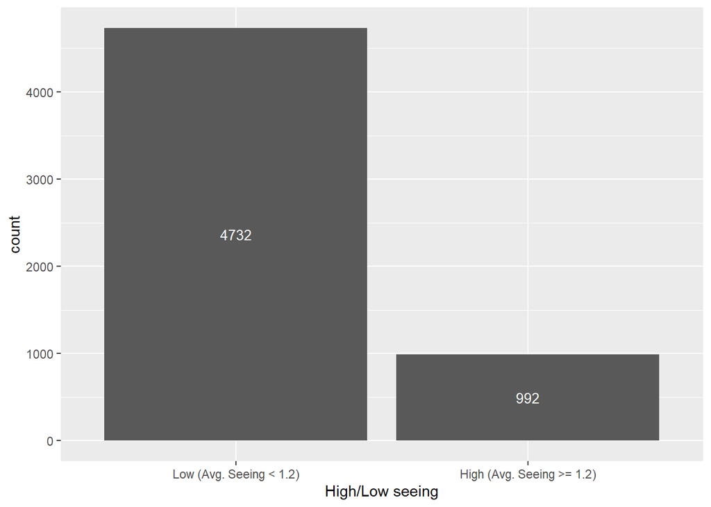

```r
# Frequency chart with High Low Seeing
library(ggplot2)

ggplot(data = df202204_VG_P2_s, aes(x=factor(Seeing_BG))) +
geom_bar(stat = "count") +
stat_count(geom = "text", colour = "white", size = 3.5, aes(label = ..count..),position=position_stack(vjust=0.5)) +
  labs(x="High/Low seeing") + scale_x_discrete(labels = c('Low (Avg. Seeing < 1.2)','High (Avg. Seeing >= 1.2)'))
```

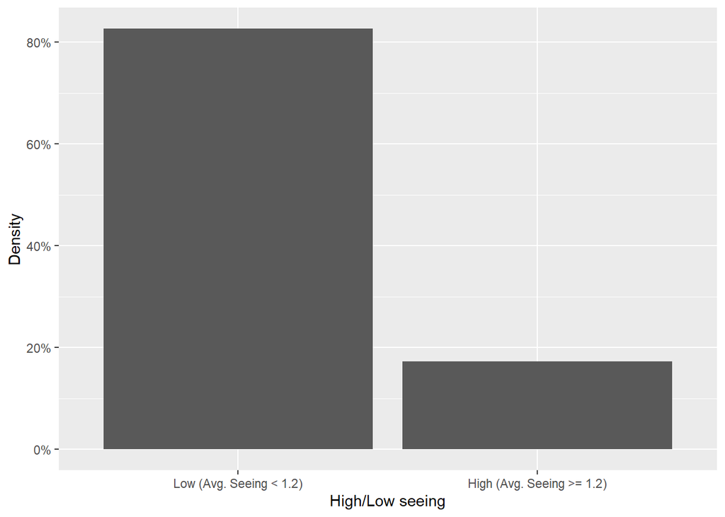

```r
# Density chart with High Low Seeing

ggplot(df202204_VG_P2_s, aes(x=factor(Seeing_BG))) + geom_bar(aes(y= (..count..)/sum(..count..))) + scale_y_continuous(labels=scales::percent_format(accuracy = 1L)) + labs(x="High/Low seeing", y="Density") + scale_x_discrete(labels = c('Low (Avg. Seeing < 1.2)','High (Avg. Seeing >= 1.2)'))
```

```r
summary(df202204_VG_P2_s[,c("V1_date","V1_date_time","lagvg_east","lagvg_west","V2_seeing_mean","Seeing_BG")])
```

```
##    V1_date           V1_date_time                   lagvg_east
##  Length:5724        Min.   :2022-04-02 23:01:14   Min.   :  0.00
##  Class :character   1st Qu.:2022-04-19 22:05:45   1st Qu.:  0.00
##  Mode  :character   Median :2022-04-22 21:36:25   Median : 15.00
##                     Mean   :2022-04-20 19:18:34   Mean   : 22.91
##                     3rd Qu.:2022-04-25 01:31:38   3rd Qu.: 30.00
##                     Max.   :2022-04-30 04:41:41   Max.   :100.00
##    lagvg_west     V2_seeing_mean     Seeing_BG
##  Min.   :  0.00   Min.   :0.1600   Min.   :0.0000
##  1st Qu.: 10.00   1st Qu.:0.5850   1st Qu.:0.0000
##  Median : 20.00   Median :0.7440   Median :0.0000
##  Mean   : 32.38   Mean   :0.9032   Mean   :0.1733
##  3rd Qu.: 50.00   3rd Qu.:1.0340   3rd Qu.:0.0000
##  Max.   :100.00   Max.   :6.7040   Max.   :1.0000
```

Generate vent gate bins

```r
df202204_VG_P2_t <- df202204_VG_P2_s %>% mutate(Vent_Gate_East_bin=cut(lagvg_east, breaks = c(-1,0,10,20,30,40,50,60,70,80,90,100)), Vent_Gate_West_bin=cut(lagvg_west, breaks = c(-1,0,10,20,30,40,50,60,70,80,90,100)))
str(df202204_VG_P2_t)
```

```
## 'data.frame':    5724 obs. of  12 variables:
##  $ group             : num  0 0 0 0 0 0 0 0 0 0 ...
##  $ P2_ind            : num  1 1 1 1 1 1 1 1 1 1 ...
##  $ V1_date           : chr  "04/02/2022" "04/02/2022" "04/02/2022" "04/02/2022" ...
##  $ V1_date_time      : POSIXct, format: "2022-04-02 23:01:14" "2022-04-02 23:01:44" ...
##  $ V1_date_time_num  : num  1.65e+09 1.65e+09 1.65e+09 1.65e+09 1.65e+09 ...
##  $ lagvg_east        : num  30 30 30 30 30 30 30 30 30 30 ...
##  $ lagvg_west        : num  30 30 30 30 30 30 30 30 30 30 ...
##  $ V2_seeing_mean    : num  0.398 0.446 0.429 0.418 0.339 ...
##  $ lag_date_time     : POSIXct, format: "2022-04-02 23:01:09" "2022-04-02 23:01:43" ...
##  $ Seeing_BG         : num  0 0 0 0 0 0 0 0 0 0 ...
##  $ Vent_Gate_East_bin: Factor w/ 11 levels "(-1,0]","(0,10]",..: 4 4 4 4 4 4 4 4 4 4 ...
##  $ Vent_Gate_West_bin: Factor w/ 11 levels "(-1,0]","(0,10]",..: 4 4 4 4 4 4 4 4 4 4 ...
```

```r
head(df202204_VG_P2_t, n=20L)
```

```
##    group P2_ind    V1_date        V1_date_time V1_date_time_num lagvg_east
## 1      0      1 04/02/2022 2022-04-02 23:01:14       1648965674         30
## 2      0      1 04/02/2022 2022-04-02 23:01:44       1648965704         30
## 3      0      1 04/02/2022 2022-04-02 23:02:14       1648965734         30
## 4      0      1 04/02/2022 2022-04-02 23:02:44       1648965765         30
## 5      0      1 04/02/2022 2022-04-02 23:03:14       1648965795         30
## 6      0      1 04/02/2022 2022-04-02 23:03:44       1648965825         30
## 7      0      1 04/02/2022 2022-04-02 23:04:15       1648965855         30
## 8      0      1 04/02/2022 2022-04-02 23:04:45       1648965885         30
## 9      0      1 04/02/2022 2022-04-02 23:05:15       1648965915         30
## 10     0      1 04/02/2022 2022-04-02 23:05:45       1648965946         30
## 11     0      1 04/02/2022 2022-04-02 23:06:15       1648965976         30
## 12     0      1 04/02/2022 2022-04-02 23:06:45       1648966006         30
## 13     0      1 04/02/2022 2022-04-02 23:07:16       1648966036         30
## 14     0      1 04/02/2022 2022-04-02 23:07:46       1648966066         30
```

[output cut: 48 more lines]

Seeing spread by vent gate bin

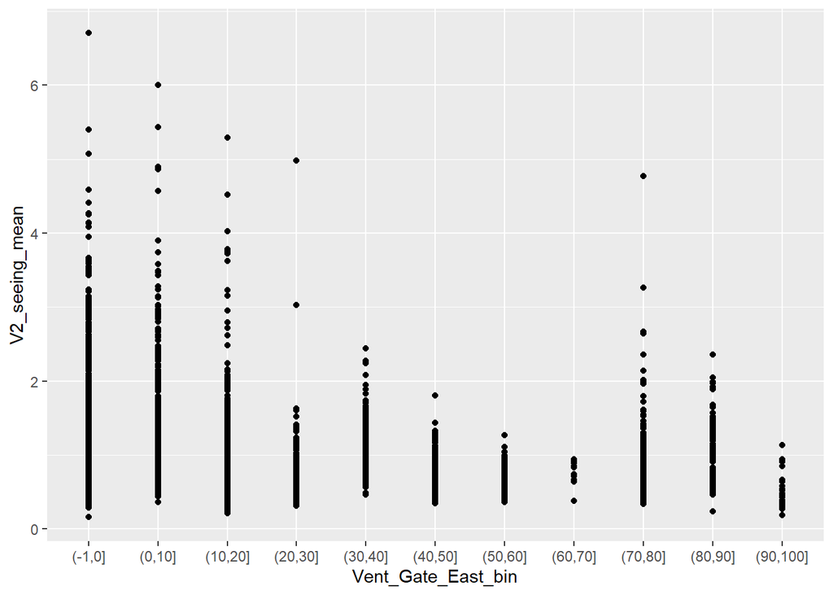

```r
#Mean Seeing neasurements per Vent gate plot
ggplot(df202204_VG_P2_t, aes(x=Vent_Gate_East_bin, y=V2_seeing_mean)) + geom_point()
```

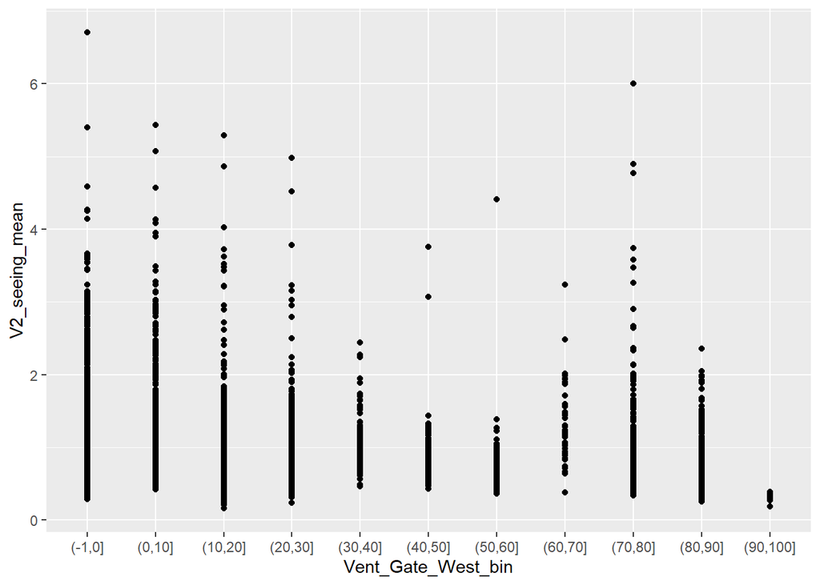

```r
ggplot(df202204_VG_P2_t, aes(x=Vent_Gate_West_bin, y=V2_seeing_mean)) + geom_point()
```

Seeing distributions when the Vent Gate East is closed.

```r
#Keep records with lagvg_east == 0
df_tmp1 =df202204_VG_P2_t[df202204_VG_P2_t$lagvg_east == 0,]
summary(df_tmp1[,c("lagvg_east")])
```

```
##    Min. 1st Qu.  Median    Mean 3rd Qu.    Max.
##       0       0       0       0       0       0
```

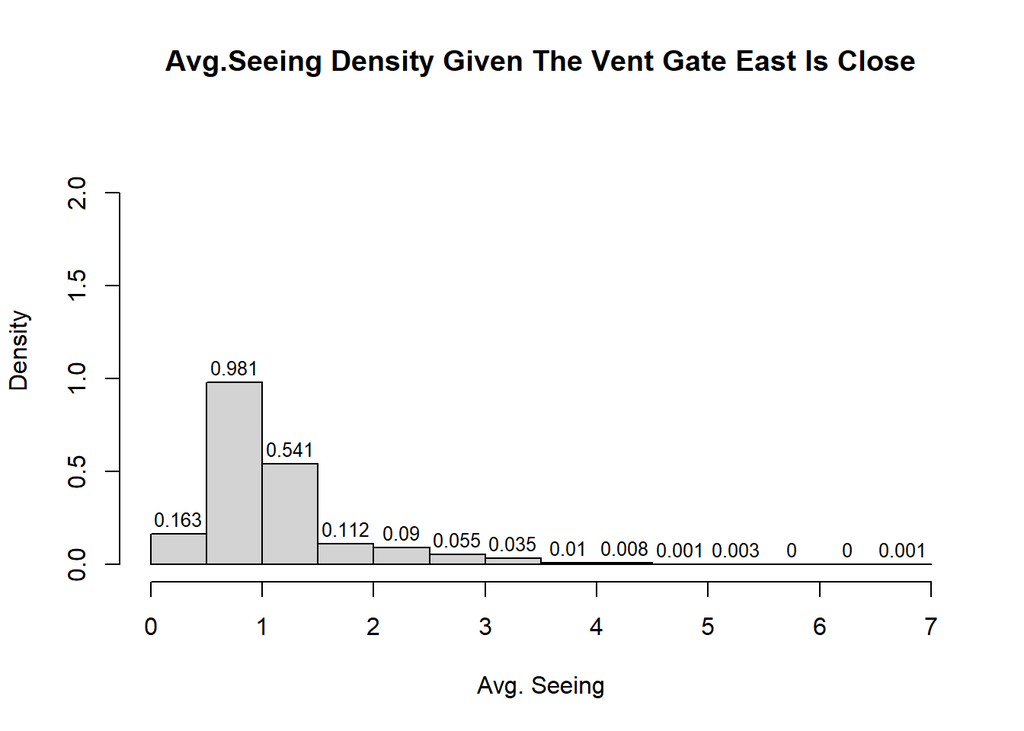

```r
#Produce a seeing density histogram given vent gate east == 0
h1 <-hist(df_tmp1$V2_seeing_mean, freq=FALSE, breaks=c(0,0.5,1,1.5,2,2.5,3,3.5,4,4.5,5,5.5,6,6.5,7),main="Avg.Seeing Density Given The Vent Gate East Is Close", xlab="Avg. Seeing",ylim=c(0,2.3))
text(h1$mids,h1$density,labels=round(h1$density,digits=3), adj=c(0.5, -0.5), cex=.8)
```

Seeing distributions when the Vent Gate East is fully opened

```r
#Keep records with lagvg_east == 100
df_tmp1 =df202204_VG_P2_t[df202204_VG_P2_t$lagvg_east == 100,]
summary(df_tmp1[,c("lagvg_east")])
```

```
##    Min. 1st Qu.  Median    Mean 3rd Qu.    Max.
##     100     100     100     100     100     100
```

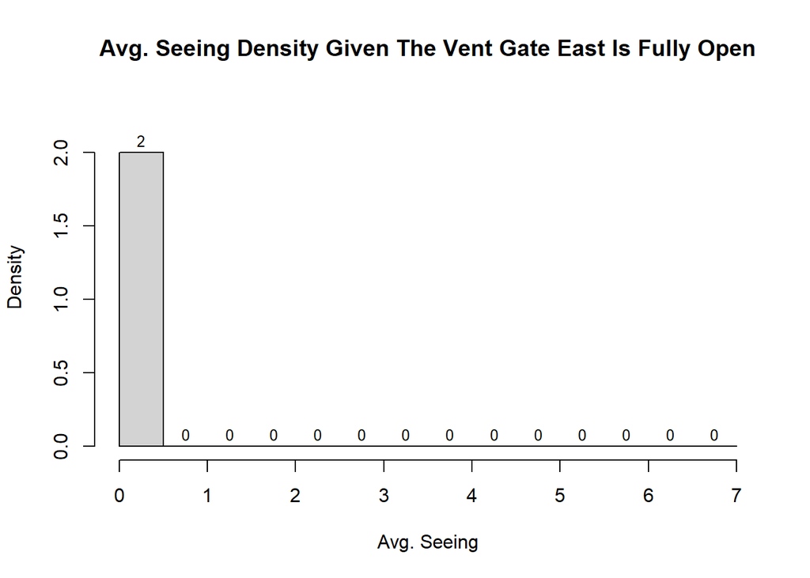

```r
#Produce a seeing density histogram given vent gate east == 100
h1 <-hist(df_tmp1$V2_seeing_mean, freq=FALSE, breaks=c(0,0.5,1,1.5,2,2.5,3,3.5,4,4.5,5,5.5,6,6.5,7),main="Avg. Seeing Density Given The Vent Gate East Is Fully Open", xlab="Avg. Seeing",ylim=c(0,2.3))
text(h1$mids,h1$density,labels=round(h1$density,digits=3), adj=c(0.5, -0.5), cex=.8)
```

Seeing distributions when the Vent Gate West is closed.

```r
#Keep records with lagvg_east == 0
df_tmp1 =df202204_VG_P2_t[df202204_VG_P2_t$lagvg_west == 0,]
summary(df_tmp1[,c("lagvg_west")])
```

```
##    Min. 1st Qu.  Median    Mean 3rd Qu.    Max.
##       0       0       0       0       0       0
```

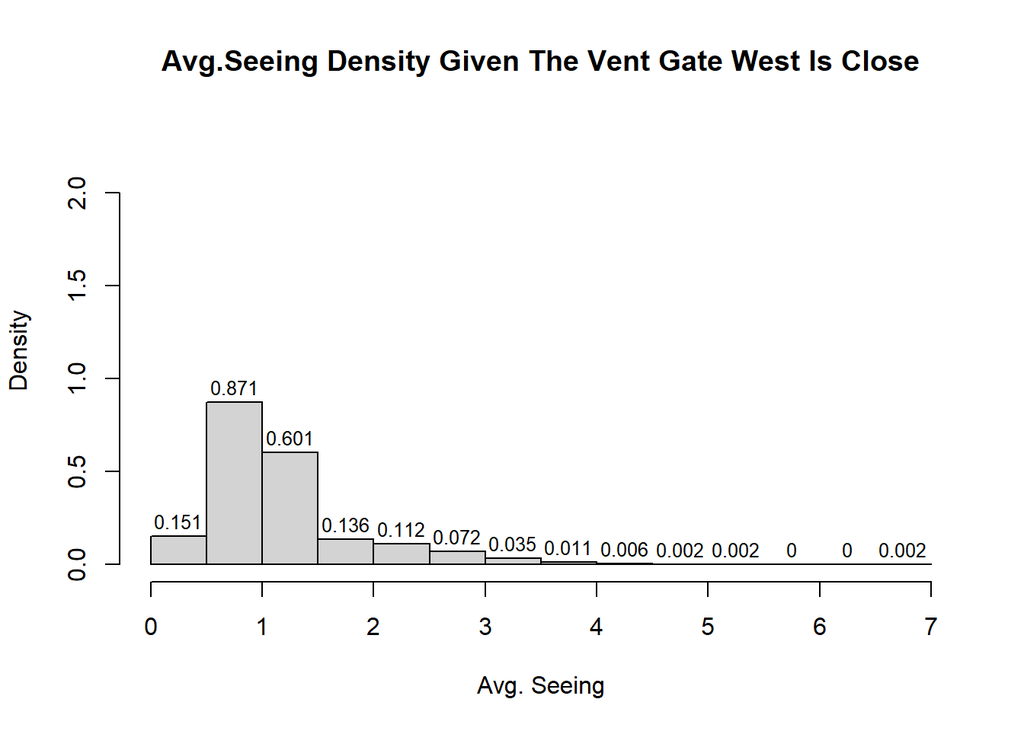

```r
#Produce a seeing density histogram given vent gate east == 0
h1 <-hist(df_tmp1$V2_seeing_mean, freq=FALSE, breaks=c(0,0.5,1,1.5,2,2.5,3,3.5,4,4.5,5,5.5,6,6.5,7),main="Avg.Seeing Density Given The Vent Gate West Is Close", xlab="Avg. Seeing",ylim=c(0,2.3))
text(h1$mids,h1$density,labels=round(h1$density,digits=3), adj=c(0.5, -0.5), cex=.8)
```

Seeing distributions when the Vent Gate West is fully opened

```r
#Keep records with lagvg_east == 100
df_tmp1 =df202204_VG_P2_t[df202204_VG_P2_t$lagvg_west == 100,]
summary(df_tmp1[,c("lagvg_west")])
```

```
##    Min. 1st Qu.  Median    Mean 3rd Qu.    Max.
##     100     100     100     100     100     100
```

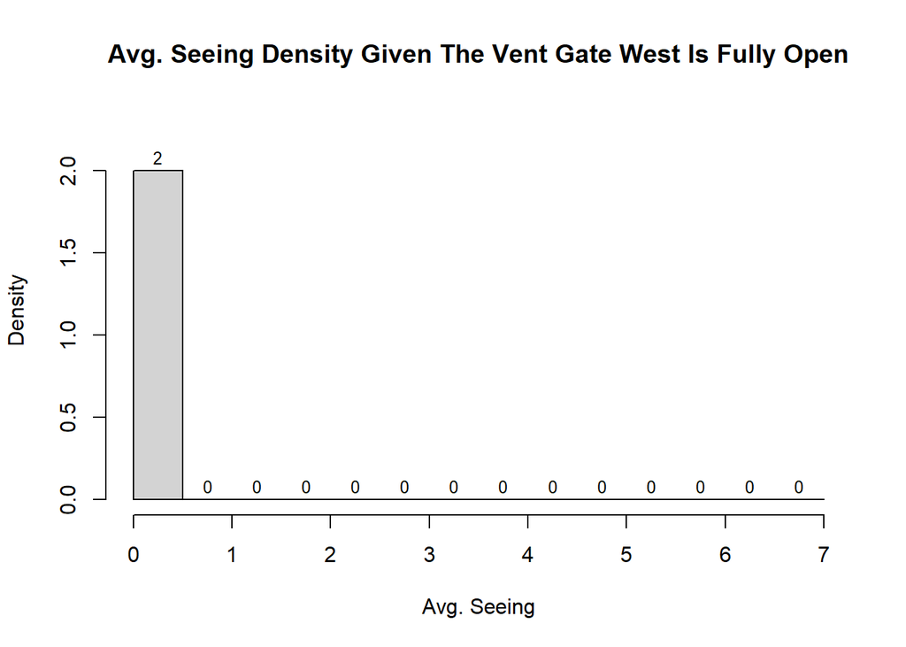

```r
#Produce a seeing density histogram given vent gate east == 100
h1 <-hist(df_tmp1$V2_seeing_mean, freq=FALSE, breaks=c(0,0.5,1,1.5,2,2.5,3,3.5,4,4.5,5,5.5,6,6.5,7),main="Avg. Seeing Density Given The Vent Gate West Is Fully Open", xlab="Avg. Seeing",ylim=c(0,2.3))
text(h1$mids,h1$density,labels=round(h1$density,digits=3), adj=c(0.5, -0.5), cex=.8)
```

Vent Gate frequency distributions.

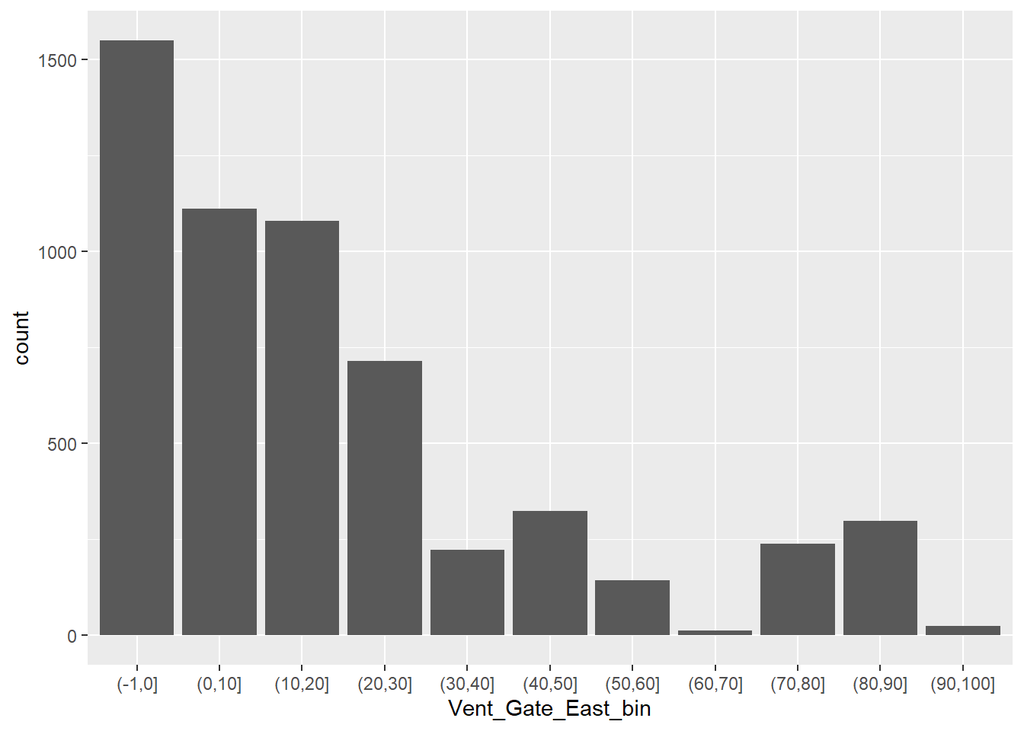

```r
#Frequency plots
ggplot(df202204_VG_P2_t, aes(x=Vent_Gate_East_bin)) + geom_bar()
```

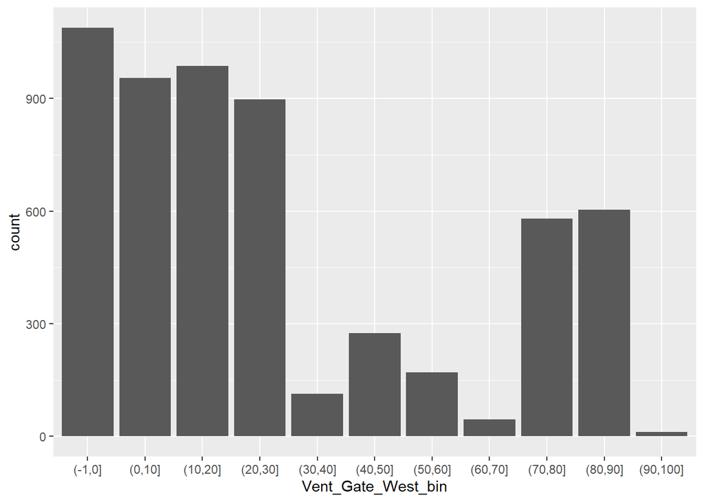

```r
ggplot(df202204_VG_P2_t, aes(x=Vent_Gate_West_bin)) + geom_bar()
```

Vent Gate density distributions

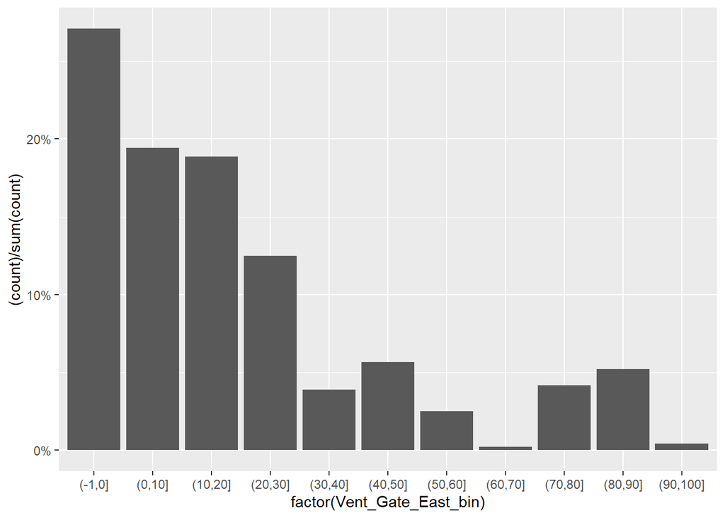

```r
#Density plots
ggplot(df202204_VG_P2_t, aes(x=factor(Vent_Gate_East_bin))) + geom_bar(aes(y= (..count..)/sum(..count..))) + scale_y_continuous(labels=scales::percent_format(accuracy = 1L))
```

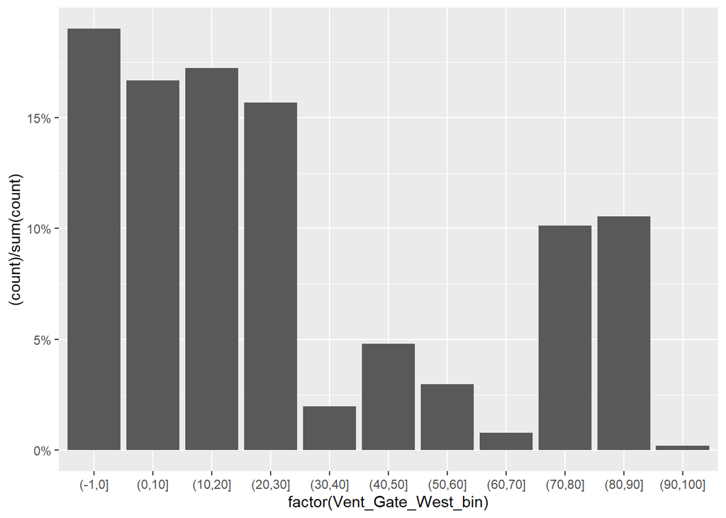

```r
ggplot(df202204_VG_P2_t, aes(x=factor(Vent_Gate_West_bin))) + geom_bar(aes(y= (..count..)/sum(..count..))) + scale_y_continuous(labels=scales::percent_format(accuracy = 1L))
```

## Wind Raw Data

Upload Wind raw data (for April, 2022) into R after manually removing header text, then check the structure and print a few records, and then save the data frame as *df_wind_202204a.Rdata*. Note that we extracted the tab delimited records first, this is because of the format the data was provided.

```r
df_wind_202204a = read.delim("D:/PROJECTS/R_Projects/Vent_Gates_Proj/VentGateProject-main/Datos_mes_edit_1/Vent_Gate_Project/wind_202204_dat.txt", header=FALSE, sep="\t")

str(df_wind_202204a)
```

```
## 'data.frame':    8540 obs. of  7 variables:
##  $ V1: chr  "07/25/2011 22:57:41.366517906" "09/26/2017 14:25:45.502542657" "03/31/2022 23:59:59.456302852" "04/01/2022 00:14:59.449931861" ...
##  $ V2: chr  "#N/A" "#N/A" "2.7" "2.7" ...
##  $ V3: chr  "<no data>" "<no data>" "" "Repeat 2" ...
##  $ V4: chr  "#N/A" "#N/A" "#N/A" "#N/A" ...
##  $ V5: chr  "<no data>" "Archive_Off" "<no data>" "<no data>" ...
##  $ V6: chr  "#N/A" "#N/A" "#N/A" "#N/A" ...
##  $ V7: chr  "Archive_Off" "<no data>" "<no data>" "<no data>" ...
```

```r
head(df_wind_202204a)
```

```
##                              V1   V2        V3   V4          V5   V6
## 1 07/25/2011 22:57:41.366517906 #N/A <no data> #N/A   <no data> #N/A
## 2 09/26/2017 14:25:45.502542657 #N/A <no data> #N/A Archive_Off #N/A
## 3 03/31/2022 23:59:59.456302852  2.7           #N/A   <no data> #N/A
## 4 04/01/2022 00:14:59.449931861  2.7  Repeat 2 #N/A   <no data> #N/A
## 5 04/01/2022 00:14:59.449931861    3           #N/A   <no data> #N/A
## 6 04/01/2022 00:19:59.447849646  2.5           #N/A   <no data> #N/A
##            V7
## 1 Archive_Off
## 2   <no data>
## 3   <no data>
## 4   <no data>
## 5   <no data>
## 6   <no data>
```

```r
save(df_wind_202204a, file="df_wind_202204a.Rdata")
```

Keep only columns *V1, V2, V3* and then check structure, print a few records, and save as *df_wind_202204b.Rdata*.

```r
df_wind_202204b = df_wind_202204a[, c('V1','V2','V3') ]

str(df_wind_202204b)
```

```
## 'data.frame':    8540 obs. of  3 variables:
##  $ V1: chr  "07/25/2011 22:57:41.366517906" "09/26/2017 14:25:45.502542657" "03/31/2022 23:59:59.456302852" "04/01/2022 00:14:59.449931861" ...
##  $ V2: chr  "#N/A" "#N/A" "2.7" "2.7" ...
##  $ V3: chr  "<no data>" "<no data>" "" "Repeat 2" ...
```

```r
head(df_wind_202204b, n=10L)
```

```
##                               V1   V2        V3
## 1  07/25/2011 22:57:41.366517906 #N/A <no data>
## 2  09/26/2017 14:25:45.502542657 #N/A <no data>
## 3  03/31/2022 23:59:59.456302852  2.7
## 4  04/01/2022 00:14:59.449931861  2.7  Repeat 2
## 5  04/01/2022 00:14:59.449931861    3
## 6  04/01/2022 00:19:59.447849646  2.5
## 7  04/01/2022 00:24:59.455778166    4
## 8  04/01/2022 00:29:59.453679113  1.9
## 9  04/01/2022 00:34:59.461580839  2.1
## 10 04/01/2022 00:39:59.459557191    3
```

```r
save(df_wind_202204b, file="df_wind_202204b.Rdata")
```

Note that all fields are character fields. Furthermore,inspection of the data shows some rows with *“#N/A”* values for *V2* and *V3*. The *“#N/A”* values were replaced by R missing values, and then a new data frame was produced and saved as *df_wind_202204c.Rdata*.

```r
library(naniar) #package to assign missing values to given values

df_wind_202204c <- df_wind_202204b %>% replace_with_na(replace = list( V2="#N/A", V3=""))

str(df_wind_202204c)
```

```
## 'data.frame':    8540 obs. of  3 variables:
##  $ V1: chr  "07/25/2011 22:57:41.366517906" "09/26/2017 14:25:45.502542657" "03/31/2022 23:59:59.456302852" "04/01/2022 00:14:59.449931861" ...
##  $ V2: chr  NA NA "2.7" "2.7" ...
##  $ V3: chr  "<no data>" "<no data>" NA "Repeat 2" ...
```

```r
head(df_wind_202204c, n=10L)
```

```
##                               V1   V2        V3
## 1  07/25/2011 22:57:41.366517906 <NA> <no data>
## 2  09/26/2017 14:25:45.502542657 <NA> <no data>
## 3  03/31/2022 23:59:59.456302852  2.7      <NA>
## 4  04/01/2022 00:14:59.449931861  2.7  Repeat 2
## 5  04/01/2022 00:14:59.449931861    3      <NA>
## 6  04/01/2022 00:19:59.447849646  2.5      <NA>
## 7  04/01/2022 00:24:59.455778166    4      <NA>
## 8  04/01/2022 00:29:59.453679113  1.9      <NA>
## 9  04/01/2022 00:34:59.461580839  2.1      <NA>
## 10 04/01/2022 00:39:59.459557191    3      <NA>
```

```r
save(df_wind_202204c, file="df_wind_202204c.RData")
```

Filter out records with *V2* values missing and *V3* not missing (e.g., repeat #, ).

```r
#Select Valid records
df_wind_202204d=df_wind_202204c[(is.na(df_wind_202204c$V2)==FALSE) & (is.na(df_wind_202204c$V3)==TRUE),]

str(df_wind_202204d)
```

```
## 'data.frame':    7982 obs. of  3 variables:
##  $ V1: chr  "03/31/2022 23:59:59.456302852" "04/01/2022 00:14:59.449931861" "04/01/2022 00:19:59.447849646" "04/01/2022 00:24:59.455778166" ...
##  $ V2: chr  "2.7" "3" "2.5" "4" ...
##  $ V3: chr  NA NA NA NA ...
```

```r
head(df_wind_202204d, n=10L)
```

```
##                               V1  V2   V3
## 3  03/31/2022 23:59:59.456302852 2.7 <NA>
## 5  04/01/2022 00:14:59.449931861   3 <NA>
## 6  04/01/2022 00:19:59.447849646 2.5 <NA>
## 7  04/01/2022 00:24:59.455778166   4 <NA>
## 8  04/01/2022 00:29:59.453679113 1.9 <NA>
## 9  04/01/2022 00:34:59.461580839 2.1 <NA>
## 10 04/01/2022 00:39:59.459557191   3 <NA>
## 11 04/01/2022 00:44:59.467373860 2.8 <NA>
## 12 04/01/2022 00:49:59.455258229 2.9 <NA>
## 13 04/01/2022 00:54:59.453127994 3.5 <NA>
```

```r
save(df_wind_202204d, file="df_wind_202204d.RData")
```

Keep only columns *V1, V2* and then check structure, print a few records, and save as *df_wind_202204e.Rdata*.

```r
df_wind_202204e = df_wind_202204d[, c('V1','V2') ]

str(df_wind_202204e)
```

```
## 'data.frame':    7982 obs. of  2 variables:
##  $ V1: chr  "03/31/2022 23:59:59.456302852" "04/01/2022 00:14:59.449931861" "04/01/2022 00:19:59.447849646" "04/01/2022 00:24:59.455778166" ...
##  $ V2: chr  "2.7" "3" "2.5" "4" ...
```

```r
head(df_wind_202204e, n=10L)
```

```
##                               V1  V2
## 3  03/31/2022 23:59:59.456302852 2.7
## 5  04/01/2022 00:14:59.449931861   3
## 6  04/01/2022 00:19:59.447849646 2.5
## 7  04/01/2022 00:24:59.455778166   4
## 8  04/01/2022 00:29:59.453679113 1.9
## 9  04/01/2022 00:34:59.461580839 2.1
## 10 04/01/2022 00:39:59.459557191   3
## 11 04/01/2022 00:44:59.467373860 2.8
## 12 04/01/2022 00:49:59.455258229 2.9
## 13 04/01/2022 00:54:59.453127994 3.5
```

```r
save(df_wind_202204e, file="df_wind_202204e.Rdata")
```

Convert *V2* to numeric (*V2_cpWindSpeed*). Note: the wind speed is measured in meters per second.

```r
#library(dplyr)  #package to add mutate fuction

df_wind_202204f=mutate(df_wind_202204e,V2_cpWindSpeed=as.numeric(df_wind_202204e$V2))
str(df_wind_202204f)
```

```
## 'data.frame':    7982 obs. of  3 variables:
##  $ V1            : chr  "03/31/2022 23:59:59.456302852" "04/01/2022 00:14:59.449931861" "04/01/2022 00:19:59.447849646" "04/01/2022 00:24:59.455778166" ...
##  $ V2            : chr  "2.7" "3" "2.5" "4" ...
##  $ V2_cpWindSpeed: num  2.7 3 2.5 4 1.9 2.1 3 2.8 2.9 3.5 ...
```

```r
head(df_wind_202204f)
```

```
##                              V1  V2 V2_cpWindSpeed
## 1 03/31/2022 23:59:59.456302852 2.7            2.7
## 2 04/01/2022 00:14:59.449931861   3            3.0
## 3 04/01/2022 00:19:59.447849646 2.5            2.5
## 4 04/01/2022 00:24:59.455778166   4            4.0
## 5 04/01/2022 00:29:59.453679113 1.9            1.9
## 6 04/01/2022 00:34:59.461580839 2.1            2.1
```

Split date-time field *V1* into *V1_date* and *V1_time* fields.

```r
#Split date-time field
df_wind_202204f$V1_date=substr(df_wind_202204f$V1,1,10)
df_wind_202204f$V1_time=substr(df_wind_202204f$V1,11,23)
str(df_wind_202204f)
```

```
## 'data.frame':    7982 obs. of  5 variables:
##  $ V1            : chr  "03/31/2022 23:59:59.456302852" "04/01/2022 00:14:59.449931861" "04/01/2022 00:19:59.447849646" "04/01/2022 00:24:59.455778166" ...
##  $ V2            : chr  "2.7" "3" "2.5" "4" ...
##  $ V2_cpWindSpeed: num  2.7 3 2.5 4 1.9 2.1 3 2.8 2.9 3.5 ...
##  $ V1_date       : chr  "03/31/2022" "04/01/2022" "04/01/2022" "04/01/2022" ...
##  $ V1_time       : chr  " 23:59:59.456" " 00:14:59.449" " 00:19:59.447" " 00:24:59.455" ...
```

```r
head(df_wind_202204f)
```

```
##                              V1  V2 V2_cpWindSpeed    V1_date       V1_time
## 1 03/31/2022 23:59:59.456302852 2.7            2.7 03/31/2022  23:59:59.456
## 2 04/01/2022 00:14:59.449931861   3            3.0 04/01/2022  00:14:59.449
## 3 04/01/2022 00:19:59.447849646 2.5            2.5 04/01/2022  00:19:59.447
## 4 04/01/2022 00:24:59.455778166   4            4.0 04/01/2022  00:24:59.455
## 5 04/01/2022 00:29:59.453679113 1.9            1.9 04/01/2022  00:29:59.453
## 6 04/01/2022 00:34:59.461580839 2.1            2.1 04/01/2022  00:34:59.461
```

Convert date-time field *V1* into a date-time field *V1_date_time* with POSIXct format. The numeric value of *V1_date_time* corresponds to the number of seconds since 1970. Then save data frame as *df_wind_202204f.RData*.

```r
op <- options(digits.sec=9)
df_wind_202204f$V1_date_time=as.POSIXct(df_wind_202204f$V1, format="%m/%d/%Y %H:%M:%OS")
class(df_wind_202204f$V1_date_time)
```

```
## [1] "POSIXct" "POSIXt"
```

```r
str(df_wind_202204f$V1_date_time)
```

```
##  POSIXct[1:7982], format: "2022-03-31 23:59:59" "2022-04-01 00:14:59" "2022-04-01 00:19:59" ...
```

```r
head(unclass(df_wind_202204f$V1_date_time)) # Number of seconds since 1970 for first 6 records
```

```
## [1] 1648796399 1648797299 1648797599 1648797899 1648798199 1648798499
```

```r
head(df_wind_202204f$V1_date_time)          # POSIXct format for first 6 records
```

```
## [1] "2022-03-31 23:59:59 PDT" "2022-04-01 00:14:59 PDT"
## [3] "2022-04-01 00:19:59 PDT" "2022-04-01 00:24:59 PDT"
## [5] "2022-04-01 00:29:59 PDT" "2022-04-01 00:34:59 PDT"
```

```r
head(df_wind_202204f)
```

```
##                              V1  V2 V2_cpWindSpeed    V1_date       V1_time
## 1 03/31/2022 23:59:59.456302852 2.7            2.7 03/31/2022  23:59:59.456
## 2 04/01/2022 00:14:59.449931861   3            3.0 04/01/2022  00:14:59.449
## 3 04/01/2022 00:19:59.447849646 2.5            2.5 04/01/2022  00:19:59.447
## 4 04/01/2022 00:24:59.455778166   4            4.0 04/01/2022  00:24:59.455
## 5 04/01/2022 00:29:59.453679113 1.9            1.9 04/01/2022  00:29:59.453
## 6 04/01/2022 00:34:59.461580839 2.1            2.1 04/01/2022  00:34:59.461
##          V1_date_time
## 1 2022-03-31 23:59:59
## 2 2022-04-01 00:14:59
## 3 2022-04-01 00:19:59
## 4 2022-04-01 00:24:59
## 5 2022-04-01 00:29:59
## 6 2022-04-01 00:34:59
```

```r
save(df_wind_202204f, file="df_wind_202204f.Rdata")
options(op)
```

```r
df_wind_202204g=mutate(df_wind_202204f, Ext_Wind_ind=1)
df_wind_202204h=df_wind_202204g[,c("Ext_Wind_ind","V1_date","V1_date_time","V2_cpWindSpeed")]

str(df_wind_202204h)
```

```
## 'data.frame':    7982 obs. of  4 variables:
##  $ Ext_Wind_ind  : num  1 1 1 1 1 1 1 1 1 1 ...
##  $ V1_date       : chr  "03/31/2022" "04/01/2022" "04/01/2022" "04/01/2022" ...
##  $ V1_date_time  : POSIXct, format: "2022-03-31 23:59:59" "2022-04-01 00:14:59" ...
##  $ V2_cpWindSpeed: num  2.7 3 2.5 4 1.9 2.1 3 2.8 2.9 3.5 ...
```

```r
head(df_wind_202204h)
```

```
##   Ext_Wind_ind    V1_date        V1_date_time V2_cpWindSpeed
## 1            1 03/31/2022 2022-03-31 23:59:59            2.7
## 2            1 04/01/2022 2022-04-01 00:14:59            3.0
## 3            1 04/01/2022 2022-04-01 00:19:59            2.5
## 4            1 04/01/2022 2022-04-01 00:24:59            4.0
## 5            1 04/01/2022 2022-04-01 00:29:59            1.9
## 6            1 04/01/2022 2022-04-01 00:34:59            2.1
```

```r
save(df_wind_202204h, file="df_wind_202204h.Rdata")
```

Prepare the data for concatenation with the vent-gate with valid P2 seeing measurment data.

```r
df_wind_202204i =mutate(df_wind_202204h,V1_date_time_num=as.numeric(df_wind_202204h$V1_date_time), WVG_lag_date_time=V1_date_time, Ext_Wind_ind=1, group=NA, P2_ind=NA, V2_seeing_mean=NA, lagvg_east=NA,   lagvg_west=NA)

str(df_wind_202204i)
```

```
## 'data.frame':    7982 obs. of  11 variables:
##  $ Ext_Wind_ind     : num  1 1 1 1 1 1 1 1 1 1 ...
##  $ V1_date          : chr  "03/31/2022" "04/01/2022" "04/01/2022" "04/01/2022" ...
##  $ V1_date_time     : POSIXct, format: "2022-03-31 23:59:59" "2022-04-01 00:14:59" ...
##  $ V2_cpWindSpeed   : num  2.7 3 2.5 4 1.9 2.1 3 2.8 2.9 3.5 ...
##  $ V1_date_time_num : num  1.65e+09 1.65e+09 1.65e+09 1.65e+09 1.65e+09 ...
##  $ WVG_lag_date_time: POSIXct, format: "2022-03-31 23:59:59" "2022-04-01 00:14:59" ...
##  $ group            : logi  NA NA NA NA NA NA ...
##  $ P2_ind           : logi  NA NA NA NA NA NA ...
##  $ V2_seeing_mean   : logi  NA NA NA NA NA NA ...
##  $ lagvg_east       : logi  NA NA NA NA NA NA ...
##  $ lagvg_west       : logi  NA NA NA NA NA NA ...
```

```r
head(df_wind_202204i)
```

```
##   Ext_Wind_ind    V1_date        V1_date_time V2_cpWindSpeed V1_date_time_num
## 1            1 03/31/2022 2022-03-31 23:59:59            2.7       1648796399
## 2            1 04/01/2022 2022-04-01 00:14:59            3.0       1648797299
## 3            1 04/01/2022 2022-04-01 00:19:59            2.5       1648797599
## 4            1 04/01/2022 2022-04-01 00:24:59            4.0       1648797899
## 5            1 04/01/2022 2022-04-01 00:29:59            1.9       1648798199
## 6            1 04/01/2022 2022-04-01 00:34:59            2.1       1648798499
##     WVG_lag_date_time group P2_ind V2_seeing_mean lagvg_east lagvg_west
## 1 2022-03-31 23:59:59    NA     NA             NA         NA         NA
## 2 2022-04-01 00:14:59    NA     NA             NA         NA         NA
## 3 2022-04-01 00:19:59    NA     NA             NA         NA         NA
## 4 2022-04-01 00:24:59    NA     NA             NA         NA         NA
## 5 2022-04-01 00:29:59    NA     NA             NA         NA         NA
## 6 2022-04-01 00:34:59    NA     NA             NA         NA         NA
```

```r
save(df_wind_202204i, file="df_wind_202204i.Rdata")
```

## Combining Wind and Vent-gate seeing data, and rename some columns

```r
df_wind_202204j <- df_wind_202204i
colnames(df_wind_202204j)
```

```
##  [1] "Ext_Wind_ind"      "V1_date"           "V1_date_time"
##  [4] "V2_cpWindSpeed"    "V1_date_time_num"  "WVG_lag_date_time"
##  [7] "group"             "P2_ind"            "V2_seeing_mean"
## [10] "lagvg_east"        "lagvg_west"
```

```r
names(df_wind_202204j)[names(df_wind_202204j) == "V2_cpWindSpeed"] <- "W2_cpWindSpeed"
names(df_wind_202204j)[names(df_wind_202204j) == "V1_date"       ] <- "W1_date"
names(df_wind_202204j)[names(df_wind_202204j) == "V1_date_time"  ] <- "W1_date_time"

df_wind_202204k=mutate(df_wind_202204j,V1_date=NA, V1_date_time=NA) #To concatenate with vent gate seeing data

colmn <- c("Ext_Wind_ind","W1_date","W1_date_time","W2_cpWindSpeed","WVG_lag_date_time","group","lagvg_east","lagvg_west","P2_ind","V1_date","V1_date_time","V2_seeing_mean")

df_wind_202204l=df_wind_202204k[,colmn] #final data frame column names
str(df_wind_202204l)
```

```
## 'data.frame':    7982 obs. of  12 variables:
##  $ Ext_Wind_ind     : num  1 1 1 1 1 1 1 1 1 1 ...
##  $ W1_date          : chr  "03/31/2022" "04/01/2022" "04/01/2022" "04/01/2022" ...
##  $ W1_date_time     : POSIXct, format: "2022-03-31 23:59:59" "2022-04-01 00:14:59" ...
##  $ W2_cpWindSpeed   : num  2.7 3 2.5 4 1.9 2.1 3 2.8 2.9 3.5 ...
##  $ WVG_lag_date_time: POSIXct, format: "2022-03-31 23:59:59" "2022-04-01 00:14:59" ...
##  $ group            : logi  NA NA NA NA NA NA ...
##  $ lagvg_east       : logi  NA NA NA NA NA NA ...
##  $ lagvg_west       : logi  NA NA NA NA NA NA ...
##  $ P2_ind           : logi  NA NA NA NA NA NA ...
##  $ V1_date          : logi  NA NA NA NA NA NA ...
##  $ V1_date_time     : logi  NA NA NA NA NA NA ...
##  $ V2_seeing_mean   : logi  NA NA NA NA NA NA ...
```

```r
colnames(df202204_VG_P2_r) #Vent gate seeing final data frame column names
```

```
## [1] "group"            "P2_ind"           "V1_date"          "V1_date_time"
## [5] "V1_date_time_num" "lagvg_east"       "lagvg_west"       "V2_seeing_mean"
## [9] "lag_date_time"
```

```r
df202204_VG_P2_u = mutate(df202204_VG_P2_r, Ext_Wind_ind=0, W1_date=NA, W1_date_time=NA,    W2_cpWindSpeed=NA,  WVG_lag_date_time=lag_date_time)


df202204_VG_P2_v=df202204_VG_P2_u[,colmn]

str(df202204_VG_P2_v)
```

```
## 'data.frame':    5724 obs. of  12 variables:
##  $ Ext_Wind_ind     : num  0 0 0 0 0 0 0 0 0 0 ...
##  $ W1_date          : logi  NA NA NA NA NA NA ...
##  $ W1_date_time     : logi  NA NA NA NA NA NA ...
##  $ W2_cpWindSpeed   : logi  NA NA NA NA NA NA ...
##  $ WVG_lag_date_time: POSIXct, format: "2022-04-02 23:01:09" "2022-04-02 23:01:43" ...
##  $ group            : num  0 0 0 0 0 0 0 0 0 0 ...
##  $ lagvg_east       : num  30 30 30 30 30 30 30 30 30 30 ...
##  $ lagvg_west       : num  30 30 30 30 30 30 30 30 30 30 ...
##  $ P2_ind           : num  1 1 1 1 1 1 1 1 1 1 ...
##  $ V1_date          : chr  "04/02/2022" "04/02/2022" "04/02/2022" "04/02/2022" ...
##  $ V1_date_time     : POSIXct, format: "2022-04-02 23:01:14" "2022-04-02 23:01:44" ...
##  $ V2_seeing_mean   : num  0.398 0.446 0.429 0.418 0.339 ...
```

```r
#Concatenate df_wind_202204l and df202204_VG_P2_v
df202204_VG_P2_W_a <-bind_rows(df_wind_202204l,df202204_VG_P2_v)
str(df202204_VG_P2_W_a)
```

```
## 'data.frame':    13706 obs. of  12 variables:
##  $ Ext_Wind_ind     : num  1 1 1 1 1 1 1 1 1 1 ...
##  $ W1_date          : chr  "03/31/2022" "04/01/2022" "04/01/2022" "04/01/2022" ...
##  $ W1_date_time     : POSIXct, format: "2022-03-31 23:59:59" "2022-04-01 00:14:59" ...
##  $ W2_cpWindSpeed   : num  2.7 3 2.5 4 1.9 2.1 3 2.8 2.9 3.5 ...
##  $ WVG_lag_date_time: POSIXct, format: "2022-03-31 23:59:59" "2022-04-01 00:14:59" ...
##  $ group            : num  NA NA NA NA NA NA NA NA NA NA ...
##  $ lagvg_east       : num  NA NA NA NA NA NA NA NA NA NA ...
##  $ lagvg_west       : num  NA NA NA NA NA NA NA NA NA NA ...
##  $ P2_ind           : num  NA NA NA NA NA NA NA NA NA NA ...
##  $ V1_date          : chr  NA NA NA NA ...
##  $ V1_date_time     : POSIXct, format: NA NA ...
##  $ V2_seeing_mean   : num  NA NA NA NA NA NA NA NA NA NA ...
```

```r
head(df202204_VG_P2_W_a)
```

```
##   Ext_Wind_ind    W1_date        W1_date_time W2_cpWindSpeed
## 1            1 03/31/2022 2022-03-31 23:59:59            2.7
## 2            1 04/01/2022 2022-04-01 00:14:59            3.0
## 3            1 04/01/2022 2022-04-01 00:19:59            2.5
## 4            1 04/01/2022 2022-04-01 00:24:59            4.0
## 5            1 04/01/2022 2022-04-01 00:29:59            1.9
## 6            1 04/01/2022 2022-04-01 00:34:59            2.1
##     WVG_lag_date_time group lagvg_east lagvg_west P2_ind V1_date V1_date_time
## 1 2022-03-31 23:59:59    NA         NA         NA     NA    <NA>         <NA>
## 2 2022-04-01 00:14:59    NA         NA         NA     NA    <NA>         <NA>
## 3 2022-04-01 00:19:59    NA         NA         NA     NA    <NA>         <NA>
## 4 2022-04-01 00:24:59    NA         NA         NA     NA    <NA>         <NA>
## 5 2022-04-01 00:29:59    NA         NA         NA     NA    <NA>         <NA>
## 6 2022-04-01 00:34:59    NA         NA         NA     NA    <NA>         <NA>
##   V2_seeing_mean
## 1             NA
## 2             NA
## 3             NA
## 4             NA
## 5             NA
## 6             NA
```

```r
save(df202204_VG_P2_W_a, file="df202204_VG_P2_W_a.RData")
```

Generate new variables *WVG_lag_date_time_num* and *P2_date_time*.

```r
df202204_VG_P2_W_b =mutate(df202204_VG_P2_W_a, WVG_lag_date_time_num=as.numeric(df202204_VG_P2_W_a$WVG_lag_date_time),P2_date_time=V1_date_time )

WVG_lag_date_time_sorted <- order(df202204_VG_P2_W_b$WVG_lag_date_time)
df202204_VG_P2_W_c <- df202204_VG_P2_W_b[WVG_lag_date_time_sorted, ]

str(df202204_VG_P2_W_c)
```

```
## 'data.frame':    13706 obs. of  14 variables:
##  $ Ext_Wind_ind         : num  1 1 1 1 1 1 1 1 1 1 ...
##  $ W1_date              : chr  "03/31/2022" "04/01/2022" "04/01/2022" "04/01/2022" ...
##  $ W1_date_time         : POSIXct, format: "2022-03-31 23:59:59" "2022-04-01 00:14:59" ...
##  $ W2_cpWindSpeed       : num  2.7 3 2.5 4 1.9 2.1 3 2.8 2.9 3.5 ...
##  $ WVG_lag_date_time    : POSIXct, format: "2022-03-31 23:59:59" "2022-04-01 00:14:59" ...
##  $ group                : num  NA NA NA NA NA NA NA NA NA NA ...
##  $ lagvg_east           : num  NA NA NA NA NA NA NA NA NA NA ...
##  $ lagvg_west           : num  NA NA NA NA NA NA NA NA NA NA ...
##  $ P2_ind               : num  NA NA NA NA NA NA NA NA NA NA ...
##  $ V1_date              : chr  NA NA NA NA ...
##  $ V1_date_time         : POSIXct, format: NA NA ...
##  $ V2_seeing_mean       : num  NA NA NA NA NA NA NA NA NA NA ...
##  $ WVG_lag_date_time_num: num  1.65e+09 1.65e+09 1.65e+09 1.65e+09 1.65e+09 ...
##  $ P2_date_time         : POSIXct, format: NA NA ...
```

```r
colmn1 <- c("W2_cpWindSpeed","WVG_lag_date_time","lagvg_east","lagvg_west","P2_date_time","V2_seeing_mean")

head(df202204_VG_P2_W_c[df202204_VG_P2_W_c$WVG_lag_date_time_num >1650784721,]) #sample all columns
```

```
##       Ext_Wind_ind    W1_date        W1_date_time W2_cpWindSpeed
## 11783            0       <NA>                <NA>             NA
## 11784            0       <NA>                <NA>             NA
## 11785            0       <NA>                <NA>             NA
## 6047             1 04/24/2022 2022-04-24 00:19:58            6.9
## 6048             1 04/24/2022 2022-04-24 00:24:58            7.0
## 11786            0       <NA>                <NA>             NA
##         WVG_lag_date_time group lagvg_east lagvg_west P2_ind    V1_date
## 11783 2022-04-24 00:18:41     0         20         20      1 04/24/2022
## 11784 2022-04-24 00:19:08     0         20         20      1 04/24/2022
## 11785 2022-04-24 00:19:42     0         20         20      1 04/24/2022
## 6047  2022-04-24 00:19:58    NA         NA         NA     NA       <NA>
## 6048  2022-04-24 00:24:58    NA         NA         NA     NA       <NA>
## 11786 2022-04-24 00:26:32     0         20         20      1 04/24/2022
##              V1_date_time V2_seeing_mean WVG_lag_date_time_num
## 11783 2022-04-24 00:18:42          0.322            1650784721
## 11784 2022-04-24 00:19:13          0.293            1650784749
## 11785 2022-04-24 00:19:43          0.309            1650784783
## 6047                 <NA>             NA            1650784799
## 6048                 <NA>             NA            1650785099
## 11786 2022-04-24 00:26:32          0.422            1650785192
##              P2_date_time
## 11783 2022-04-24 00:18:42
## 11784 2022-04-24 00:19:13
## 11785 2022-04-24 00:19:43
## 6047                 <NA>
## 6048                 <NA>
## 11786 2022-04-24 00:26:32
```

```r
head(df202204_VG_P2_W_c[df202204_VG_P2_W_c$WVG_lag_date_time_num >1650784721, colmn1], n=15L) #sample selected columns
```

```
##       W2_cpWindSpeed   WVG_lag_date_time lagvg_east lagvg_west
## 11783             NA 2022-04-24 00:18:41         20         20
## 11784             NA 2022-04-24 00:19:08         20         20
## 11785             NA 2022-04-24 00:19:42         20         20
## 6047             6.9 2022-04-24 00:19:58         NA         NA
## 6048             7.0 2022-04-24 00:24:58         NA         NA
## 11786             NA 2022-04-24 00:26:32         20         20
## 11787             NA 2022-04-24 00:27:02         20         20
## 11788             NA 2022-04-24 00:27:31         20         20
## 11789             NA 2022-04-24 00:28:02         20         20
## 11790             NA 2022-04-24 00:28:28         20         20
## 11791             NA 2022-04-24 00:29:02         20         20
## 11792             NA 2022-04-24 00:29:24         20         20
## 6049             6.8 2022-04-24 00:29:58         NA         NA
## 11793             NA 2022-04-24 00:30:00         20         20
```

[output cut: 17 more lines]

```r
save(df202204_VG_P2_W_c, file="df202204_VG_P2_W_c.RData")
```

Generate lag variables for wind data *after* sorting.

```r
df202204_VG_P2_W_d=mutate(df202204_VG_P2_W_c, lag_Ext_Wind_ind=lag(Ext_Wind_ind), lag_W1_date=lag(W1_date), lag_W1_date_time=lag(W1_date_time), lag_W2_cpWindSpeed=lag(W2_cpWindSpeed),lag_WVG_lag_date_time=lag(WVG_lag_date_time))

str(df202204_VG_P2_W_d)
```

```
## 'data.frame':    13706 obs. of  19 variables:
##  $ Ext_Wind_ind         : num  1 1 1 1 1 1 1 1 1 1 ...
##  $ W1_date              : chr  "03/31/2022" "04/01/2022" "04/01/2022" "04/01/2022" ...
##  $ W1_date_time         : POSIXct, format: "2022-03-31 23:59:59" "2022-04-01 00:14:59" ...
##  $ W2_cpWindSpeed       : num  2.7 3 2.5 4 1.9 2.1 3 2.8 2.9 3.5 ...
##  $ WVG_lag_date_time    : POSIXct, format: "2022-03-31 23:59:59" "2022-04-01 00:14:59" ...
##  $ group                : num  NA NA NA NA NA NA NA NA NA NA ...
##  $ lagvg_east           : num  NA NA NA NA NA NA NA NA NA NA ...
##  $ lagvg_west           : num  NA NA NA NA NA NA NA NA NA NA ...
##  $ P2_ind               : num  NA NA NA NA NA NA NA NA NA NA ...
##  $ V1_date              : chr  NA NA NA NA ...
##  $ V1_date_time         : POSIXct, format: NA NA ...
##  $ V2_seeing_mean       : num  NA NA NA NA NA NA NA NA NA NA ...
##  $ WVG_lag_date_time_num: num  1.65e+09 1.65e+09 1.65e+09 1.65e+09 1.65e+09 ...
##  $ P2_date_time         : POSIXct, format: NA NA ...
##  $ lag_Ext_Wind_ind     : num  NA 1 1 1 1 1 1 1 1 1 ...
##  $ lag_W1_date          : chr  NA "03/31/2022" "04/01/2022" "04/01/2022" ...
##  $ lag_W1_date_time     : POSIXct, format: NA "2022-03-31 23:59:59" ...
##  $ lag_W2_cpWindSpeed   : num  NA 2.7 3 2.5 4 1.9 2.1 3 2.8 2.9 ...
##  $ lag_WVG_lag_date_time: POSIXct, format: NA "2022-03-31 23:59:59" ...
```

```r
colmn1 <- c("Ext_Wind_ind","W1_date_time","WVG_lag_date_time","W2_cpWindSpeed","P2_ind","lag_Ext_Wind_ind","lag_W1_date_time","lag_WVG_lag_date_time","lag_W2_cpWindSpeed")

head(df202204_VG_P2_W_d[df202204_VG_P2_W_c$WVG_lag_date_time_num >1650784721,]) #sample all columns
```

```
##      Ext_Wind_ind    W1_date        W1_date_time W2_cpWindSpeed
## 9847            0       <NA>                <NA>             NA
## 9848            0       <NA>                <NA>             NA
## 9849            0       <NA>                <NA>             NA
## 9850            1 04/24/2022 2022-04-24 00:19:58            6.9
## 9851            1 04/24/2022 2022-04-24 00:24:58            7.0
## 9852            0       <NA>                <NA>             NA
##        WVG_lag_date_time group lagvg_east lagvg_west P2_ind    V1_date
## 9847 2022-04-24 00:18:41     0         20         20      1 04/24/2022
## 9848 2022-04-24 00:19:08     0         20         20      1 04/24/2022
## 9849 2022-04-24 00:19:42     0         20         20      1 04/24/2022
## 9850 2022-04-24 00:19:58    NA         NA         NA     NA       <NA>
## 9851 2022-04-24 00:24:58    NA         NA         NA     NA       <NA>
## 9852 2022-04-24 00:26:32     0         20         20      1 04/24/2022
##             V1_date_time V2_seeing_mean WVG_lag_date_time_num
```

[output cut: 20 more lines]

```r
head(df202204_VG_P2_W_d[df202204_VG_P2_W_c$WVG_lag_date_time_num >1650784721, colmn1], n=15L) #sample selected columns
```

```
##      Ext_Wind_ind        W1_date_time   WVG_lag_date_time W2_cpWindSpeed P2_ind
## 9847            0                <NA> 2022-04-24 00:18:41             NA      1
## 9848            0                <NA> 2022-04-24 00:19:08             NA      1
## 9849            0                <NA> 2022-04-24 00:19:42             NA      1
## 9850            1 2022-04-24 00:19:58 2022-04-24 00:19:58            6.9     NA
## 9851            1 2022-04-24 00:24:58 2022-04-24 00:24:58            7.0     NA
## 9852            0                <NA> 2022-04-24 00:26:32             NA      1
## 9853            0                <NA> 2022-04-24 00:27:02             NA      1
## 9854            0                <NA> 2022-04-24 00:27:31             NA      1
## 9855            0                <NA> 2022-04-24 00:28:02             NA      1
## 9856            0                <NA> 2022-04-24 00:28:28             NA      1
## 9857            0                <NA> 2022-04-24 00:29:02             NA      1
## 9858            0                <NA> 2022-04-24 00:29:24             NA      1
## 9859            1 2022-04-24 00:29:58 2022-04-24 00:29:58            6.8     NA
## 9860            0                <NA> 2022-04-24 00:30:00             NA      1
```

[output cut: 33 more lines]

```r
save(df202204_VG_P2_W_d, file="df202204_VG_P2_W_d.RData")
```

Keep only valid P2 records

```r
#Filter valid P2 records
df202204_VG_P2_W_e =df202204_VG_P2_W_d[is.na(df202204_VG_P2_W_d$P2_ind) ==FALSE,]
str(df202204_VG_P2_W_e)
```

```
## 'data.frame':    5724 obs. of  19 variables:
##  $ Ext_Wind_ind         : num  0 0 0 0 0 0 0 0 0 0 ...
##  $ W1_date              : chr  NA NA NA NA ...
##  $ W1_date_time         : POSIXct, format: NA NA ...
##  $ W2_cpWindSpeed       : num  NA NA NA NA NA NA NA NA NA NA ...
##  $ WVG_lag_date_time    : POSIXct, format: "2022-04-02 23:01:09" "2022-04-02 23:01:43" ...
##  $ group                : num  0 0 0 0 0 0 0 0 0 0 ...
##  $ lagvg_east           : num  30 30 30 30 30 30 30 30 30 30 ...
##  $ lagvg_west           : num  30 30 30 30 30 30 30 30 30 30 ...
##  $ P2_ind               : num  1 1 1 1 1 1 1 1 1 1 ...
##  $ V1_date              : chr  "04/02/2022" "04/02/2022" "04/02/2022" "04/02/2022" ...
##  $ V1_date_time         : POSIXct, format: "2022-04-02 23:01:14" "2022-04-02 23:01:44" ...
##  $ V2_seeing_mean       : num  0.398 0.446 0.429 0.418 0.339 ...
##  $ WVG_lag_date_time_num: num  1.65e+09 1.65e+09 1.65e+09 1.65e+09 1.65e+09 ...
##  $ P2_date_time         : POSIXct, format: "2022-04-02 23:01:14" "2022-04-02 23:01:44" ...
##  $ lag_Ext_Wind_ind     : num  1 0 0 0 0 0 0 0 1 0 ...
##  $ lag_W1_date          : chr  "04/02/2022" NA NA NA ...
##  $ lag_W1_date_time     : POSIXct, format: "2022-04-02 22:59:59" NA ...
##  $ lag_W2_cpWindSpeed   : num  2.7 NA NA NA NA NA NA NA 2.7 NA ...
##  $ lag_WVG_lag_date_time: POSIXct, format: "2022-04-02 22:59:59" "2022-04-02 23:01:09" ...
```

```r
head(df202204_VG_P2_W_e)
```

```
##     Ext_Wind_ind W1_date W1_date_time W2_cpWindSpeed   WVG_lag_date_time group
## 538            0    <NA>         <NA>             NA 2022-04-02 23:01:09     0
## 539            0    <NA>         <NA>             NA 2022-04-02 23:01:43     0
## 540            0    <NA>         <NA>             NA 2022-04-02 23:02:10     0
## 541            0    <NA>         <NA>             NA 2022-04-02 23:02:39     0
## 542            0    <NA>         <NA>             NA 2022-04-02 23:03:12     0
## 543            0    <NA>         <NA>             NA 2022-04-02 23:03:30     0
##     lagvg_east lagvg_west P2_ind    V1_date        V1_date_time V2_seeing_mean
## 538         30         30      1 04/02/2022 2022-04-02 23:01:14          0.398
## 539         30         30      1 04/02/2022 2022-04-02 23:01:44          0.446
## 540         30         30      1 04/02/2022 2022-04-02 23:02:14          0.429
## 541         30         30      1 04/02/2022 2022-04-02 23:02:44          0.418
## 542         30         30      1 04/02/2022 2022-04-02 23:03:14          0.339
## 543         30         30      1 04/02/2022 2022-04-02 23:03:44          0.589
##     WVG_lag_date_time_num        P2_date_time lag_Ext_Wind_ind lag_W1_date
## 538            1648965670 2022-04-02 23:01:14                1  04/02/2022
## 539            1648965703 2022-04-02 23:01:44                0        <NA>
## 540            1648965730 2022-04-02 23:02:14                0        <NA>
## 541            1648965760 2022-04-02 23:02:44                0        <NA>
## 542            1648965792 2022-04-02 23:03:14                0        <NA>
## 543            1648965811 2022-04-02 23:03:44                0        <NA>
##        lag_W1_date_time lag_W2_cpWindSpeed lag_WVG_lag_date_time
## 538 2022-04-02 22:59:59                2.7   2022-04-02 22:59:59
## 539                <NA>                 NA   2022-04-02 23:01:09
## 540                <NA>                 NA   2022-04-02 23:01:43
## 541                <NA>                 NA   2022-04-02 23:02:10
## 542                <NA>                 NA   2022-04-02 23:02:39
## 543                <NA>                 NA   2022-04-02 23:03:12
```

```r
summary(df202204_VG_P2_W_e)
```

```
##   Ext_Wind_ind   W1_date           W1_date_time  W2_cpWindSpeed
##  Min.   :0     Length:5724        Min.   :NA     Min.   : NA
##  1st Qu.:0     Class :character   1st Qu.:NA     1st Qu.: NA
##  Median :0     Mode  :character   Median :NA     Median : NA
##  Mean   :0                        Mean   :NA     Mean   :NaN
##  3rd Qu.:0                        3rd Qu.:NA     3rd Qu.: NA
##  Max.   :0                        Max.   :NA     Max.   : NA
##                                   NA's   :5724   NA's   :5724
##  WVG_lag_date_time                 group          lagvg_east
##  Min.   :2022-04-02 23:01:09   Min.   :  0.00   Min.   :  0.00
##  1st Qu.:2022-04-19 22:05:37   1st Qu.:  0.00   1st Qu.:  0.00
##  Median :2022-04-22 21:36:24   Median :  0.00   Median : 15.00
##  Mean   :2022-04-20 19:18:27   Mean   : 51.19   Mean   : 22.91
##  3rd Qu.:2022-04-25 01:31:36   3rd Qu.:  0.00   3rd Qu.: 30.00
##  Max.   :2022-04-30 04:41:40   Max.   :765.00   Max.   :100.00
##
##    lagvg_west         P2_ind    V1_date           V1_date_time
##  Min.   :  0.00   Min.   :1   Length:5724        Min.   :2022-04-02 23:01:14
##  1st Qu.: 10.00   1st Qu.:1   Class :character   1st Qu.:2022-04-19 22:05:45
##  Median : 20.00   Median :1   Mode  :character   Median :2022-04-22 21:36:25
##  Mean   : 32.38   Mean   :1                      Mean   :2022-04-20 19:18:34
##  3rd Qu.: 50.00   3rd Qu.:1                      3rd Qu.:2022-04-25 01:31:38
##  Max.   :100.00   Max.   :1                      Max.   :2022-04-30 04:41:41
##
##  V2_seeing_mean   WVG_lag_date_time_num  P2_date_time
##  Min.   :0.1600   Min.   :1.649e+09     Min.   :2022-04-02 23:01:14
##  1st Qu.:0.5850   1st Qu.:1.650e+09     1st Qu.:2022-04-19 22:05:45
##  Median :0.7440   Median :1.651e+09     Median :2022-04-22 21:36:25
##  Mean   :0.9032   Mean   :1.651e+09     Mean   :2022-04-20 19:18:34
##  3rd Qu.:1.0340   3rd Qu.:1.651e+09     3rd Qu.:2022-04-25 01:31:38
##  Max.   :6.7040   Max.   :1.651e+09     Max.   :2022-04-30 04:41:41
##
##  lag_Ext_Wind_ind lag_W1_date        lag_W1_date_time
##  Min.   :0.0000   Length:5724        Min.   :2022-04-02 22:59:59
##  1st Qu.:0.0000   Class :character   1st Qu.:2022-04-20 00:49:59
##  Median :0.0000   Mode  :character   Median :2022-04-23 04:39:59
##  Mean   :0.1469                      Mean   :2022-04-21 18:23:35
##  3rd Qu.:0.0000                      3rd Qu.:2022-04-26 01:54:59
##  Max.   :1.0000                      Max.   :2022-04-30 04:39:59
##                                      NA's   :4883
##  lag_W2_cpWindSpeed lag_WVG_lag_date_time
##  Min.   : 0.000     Min.   :2022-04-02 22:59:59
##  1st Qu.: 5.300     1st Qu.:2022-04-19 22:05:14
##  Median : 7.800     Median :2022-04-22 21:35:49
##  Mean   : 7.684     Mean   :2022-04-20 19:17:47
##  3rd Qu.:10.400     3rd Qu.:2022-04-25 01:30:58
##  Max.   :16.900     Max.   :2022-04-30 04:41:02
##  NA's   :4883
```

```r
save(df202204_VG_P2_W_e, file="df202204_VG_P2_W_e.RData")
```

Keep selected fields.

```r
df202204_VG_P2_W_f=df202204_VG_P2_W_e[,c("P2_ind", "lag_WVG_lag_date_time","WVG_lag_date_time","P2_date_time","WVG_lag_date_time_num"
,"lag_Ext_Wind_ind"
,"lag_W1_date_time"
,"lag_W2_cpWindSpeed"
,"lagvg_east"
,"lagvg_west"
,"V2_seeing_mean"
)]
str(df202204_VG_P2_W_f)
```

```
## 'data.frame':    5724 obs. of  11 variables:
##  $ P2_ind               : num  1 1 1 1 1 1 1 1 1 1 ...
##  $ lag_WVG_lag_date_time: POSIXct, format: "2022-04-02 22:59:59" "2022-04-02 23:01:09" ...
##  $ WVG_lag_date_time    : POSIXct, format: "2022-04-02 23:01:09" "2022-04-02 23:01:43" ...
##  $ P2_date_time         : POSIXct, format: "2022-04-02 23:01:14" "2022-04-02 23:01:44" ...
##  $ WVG_lag_date_time_num: num  1.65e+09 1.65e+09 1.65e+09 1.65e+09 1.65e+09 ...
##  $ lag_Ext_Wind_ind     : num  1 0 0 0 0 0 0 0 1 0 ...
##  $ lag_W1_date_time     : POSIXct, format: "2022-04-02 22:59:59" NA ...
##  $ lag_W2_cpWindSpeed   : num  2.7 NA NA NA NA NA NA NA 2.7 NA ...
##  $ lagvg_east           : num  30 30 30 30 30 30 30 30 30 30 ...
##  $ lagvg_west           : num  30 30 30 30 30 30 30 30 30 30 ...
##  $ V2_seeing_mean       : num  0.398 0.446 0.429 0.418 0.339 ...
```

```r
head(df202204_VG_P2_W_f)
```

```
##     P2_ind lag_WVG_lag_date_time   WVG_lag_date_time        P2_date_time
## 538      1   2022-04-02 22:59:59 2022-04-02 23:01:09 2022-04-02 23:01:14
## 539      1   2022-04-02 23:01:09 2022-04-02 23:01:43 2022-04-02 23:01:44
## 540      1   2022-04-02 23:01:43 2022-04-02 23:02:10 2022-04-02 23:02:14
## 541      1   2022-04-02 23:02:10 2022-04-02 23:02:39 2022-04-02 23:02:44
## 542      1   2022-04-02 23:02:39 2022-04-02 23:03:12 2022-04-02 23:03:14
## 543      1   2022-04-02 23:03:12 2022-04-02 23:03:30 2022-04-02 23:03:44
##     WVG_lag_date_time_num lag_Ext_Wind_ind    lag_W1_date_time
## 538            1648965670                1 2022-04-02 22:59:59
## 539            1648965703                0                <NA>
## 540            1648965730                0                <NA>
## 541            1648965760                0                <NA>
## 542            1648965792                0                <NA>
## 543            1648965811                0                <NA>
##     lag_W2_cpWindSpeed lagvg_east lagvg_west V2_seeing_mean
## 538                2.7         30         30          0.398
## 539                 NA         30         30          0.446
## 540                 NA         30         30          0.429
## 541                 NA         30         30          0.418
## 542                 NA         30         30          0.339
## 543                 NA         30         30          0.589
```

```r
summary(df202204_VG_P2_W_f)
```

```
##      P2_ind  lag_WVG_lag_date_time         WVG_lag_date_time
##  Min.   :1   Min.   :2022-04-02 22:59:59   Min.   :2022-04-02 23:01:09
##  1st Qu.:1   1st Qu.:2022-04-19 22:05:14   1st Qu.:2022-04-19 22:05:37
##  Median :1   Median :2022-04-22 21:35:49   Median :2022-04-22 21:36:24
##  Mean   :1   Mean   :2022-04-20 19:17:47   Mean   :2022-04-20 19:18:27
##  3rd Qu.:1   3rd Qu.:2022-04-25 01:30:58   3rd Qu.:2022-04-25 01:31:36
##  Max.   :1   Max.   :2022-04-30 04:41:02   Max.   :2022-04-30 04:41:40
##
##   P2_date_time                 WVG_lag_date_time_num lag_Ext_Wind_ind
##  Min.   :2022-04-02 23:01:14   Min.   :1.649e+09     Min.   :0.0000
##  1st Qu.:2022-04-19 22:05:45   1st Qu.:1.650e+09     1st Qu.:0.0000
##  Median :2022-04-22 21:36:25   Median :1.651e+09     Median :0.0000
##  Mean   :2022-04-20 19:18:34   Mean   :1.651e+09     Mean   :0.1469
##  3rd Qu.:2022-04-25 01:31:38   3rd Qu.:1.651e+09     3rd Qu.:0.0000
##  Max.   :2022-04-30 04:41:41   Max.   :1.651e+09     Max.   :1.0000
##
##  lag_W1_date_time              lag_W2_cpWindSpeed   lagvg_east
##  Min.   :2022-04-02 22:59:59   Min.   : 0.000     Min.   :  0.00
##  1st Qu.:2022-04-20 00:49:59   1st Qu.: 5.300     1st Qu.:  0.00
##  Median :2022-04-23 04:39:59   Median : 7.800     Median : 15.00
##  Mean   :2022-04-21 18:23:35   Mean   : 7.684     Mean   : 22.91
##  3rd Qu.:2022-04-26 01:54:59   3rd Qu.:10.400     3rd Qu.: 30.00
##  Max.   :2022-04-30 04:39:59   Max.   :16.900     Max.   :100.00
##  NA's   :4883                  NA's   :4883
##    lagvg_west     V2_seeing_mean
##  Min.   :  0.00   Min.   :0.1600
##  1st Qu.: 10.00   1st Qu.:0.5850
##  Median : 20.00   Median :0.7440
##  Mean   : 32.38   Mean   :0.9032
##  3rd Qu.: 50.00   3rd Qu.:1.0340
##  Max.   :100.00   Max.   :6.7040
##
```

```r
#save(df202204_VG_P2_W_f, file="df202204_VG_P2_W_f.RData")
```

In the data frame *df202204_VG_P2_W_f* flag the various groups of records for which the wind speed will be averaged. This is done calculating the cumulative sum for the field *lag_Ext_Wind_ind*.

```r
df202204_VG_P2_W_f$upchg_counter <- cumsum(df202204_VG_P2_W_f$lag_Ext_Wind_ind)
head(df202204_VG_P2_W_f, n=20L)
```

```
##     P2_ind lag_WVG_lag_date_time   WVG_lag_date_time        P2_date_time
## 538      1   2022-04-02 22:59:59 2022-04-02 23:01:09 2022-04-02 23:01:14
## 539      1   2022-04-02 23:01:09 2022-04-02 23:01:43 2022-04-02 23:01:44
## 540      1   2022-04-02 23:01:43 2022-04-02 23:02:10 2022-04-02 23:02:14
## 541      1   2022-04-02 23:02:10 2022-04-02 23:02:39 2022-04-02 23:02:44
## 542      1   2022-04-02 23:02:39 2022-04-02 23:03:12 2022-04-02 23:03:14
## 543      1   2022-04-02 23:03:12 2022-04-02 23:03:30 2022-04-02 23:03:44
## 544      1   2022-04-02 23:03:30 2022-04-02 23:04:14 2022-04-02 23:04:15
## 545      1   2022-04-02 23:04:14 2022-04-02 23:04:41 2022-04-02 23:04:45
## 548      1   2022-04-02 23:04:59 2022-04-02 23:05:14 2022-04-02 23:05:15
## 549      1   2022-04-02 23:05:14 2022-04-02 23:05:44 2022-04-02 23:05:45
## 550      1   2022-04-02 23:05:44 2022-04-02 23:06:13 2022-04-02 23:06:15
## 551      1   2022-04-02 23:06:13 2022-04-02 23:06:41 2022-04-02 23:06:45
## 552      1   2022-04-02 23:06:41 2022-04-02 23:07:15 2022-04-02 23:07:16
## 553      1   2022-04-02 23:07:15 2022-04-02 23:07:39 2022-04-02 23:07:46
```

[output cut: 48 more lines]

```r
save(df202204_VG_P2_W_f, file = "df202204_VG_P2_W_f.RData")
```

```r
df202204_VG_P2_W_g=df202204_VG_P2_W_f[,c("P2_ind", "lag_WVG_lag_date_time","WVG_lag_date_time","P2_date_time","WVG_lag_date_time_num"
,"lag_Ext_Wind_ind"
,"upchg_counter"
,"lag_W1_date_time"
,"lag_W2_cpWindSpeed"
,"lagvg_east"
,"lagvg_west"
,"V2_seeing_mean"
)]
head(df202204_VG_P2_W_g, n=20L)
```

```
##     P2_ind lag_WVG_lag_date_time   WVG_lag_date_time        P2_date_time
## 538      1   2022-04-02 22:59:59 2022-04-02 23:01:09 2022-04-02 23:01:14
## 539      1   2022-04-02 23:01:09 2022-04-02 23:01:43 2022-04-02 23:01:44
## 540      1   2022-04-02 23:01:43 2022-04-02 23:02:10 2022-04-02 23:02:14
## 541      1   2022-04-02 23:02:10 2022-04-02 23:02:39 2022-04-02 23:02:44
## 542      1   2022-04-02 23:02:39 2022-04-02 23:03:12 2022-04-02 23:03:14
## 543      1   2022-04-02 23:03:12 2022-04-02 23:03:30 2022-04-02 23:03:44
## 544      1   2022-04-02 23:03:30 2022-04-02 23:04:14 2022-04-02 23:04:15
## 545      1   2022-04-02 23:04:14 2022-04-02 23:04:41 2022-04-02 23:04:45
## 548      1   2022-04-02 23:04:59 2022-04-02 23:05:14 2022-04-02 23:05:15
## 549      1   2022-04-02 23:05:14 2022-04-02 23:05:44 2022-04-02 23:05:45
## 550      1   2022-04-02 23:05:44 2022-04-02 23:06:13 2022-04-02 23:06:15
## 551      1   2022-04-02 23:06:13 2022-04-02 23:06:41 2022-04-02 23:06:45
## 552      1   2022-04-02 23:06:41 2022-04-02 23:07:15 2022-04-02 23:07:16
## 553      1   2022-04-02 23:07:15 2022-04-02 23:07:39 2022-04-02 23:07:46
```

[output cut: 48 more lines]

```r
save(df202204_VG_P2_W_g, file = "df202204_VG_P2_W_g.RData")
```

#aggregate

```r
df202204_VG_P2_W_h = aggregate(df202204_VG_P2_W_g[, c("lag_W2_cpWindSpeed","lag_W1_date_time")], list(df202204_VG_P2_W_g$upchg_counter), mean, na.rm=TRUE)
str(df202204_VG_P2_W_h)
```

```
## 'data.frame':    841 obs. of  3 variables:
##  $ Group.1           : num  1 2 3 4 5 6 7 8 9 10 ...
##  $ lag_W2_cpWindSpeed: num  2.7 2.7 2.2 2 1.6 2.2 2.6 9.2 10.2 9.8 ...
##  $ lag_W1_date_time  : POSIXct, format: "2022-04-02 22:59:59" "2022-04-02 23:04:59" ...
```

```r
head(df202204_VG_P2_W_h, n=20L)
```

```
##    Group.1 lag_W2_cpWindSpeed    lag_W1_date_time
## 1        1                2.7 2022-04-02 22:59:59
## 2        2                2.7 2022-04-02 23:04:59
## 3        3                2.2 2022-04-02 23:09:59
## 4        4                2.0 2022-04-02 23:14:59
## 5        5                1.6 2022-04-02 23:19:59
## 6        6                2.2 2022-04-02 23:24:59
## 7        7                2.6 2022-04-02 23:29:59
## 8        8                9.2 2022-04-04 23:49:59
## 9        9               10.2 2022-04-04 23:54:59
## 10      10                9.8 2022-04-04 23:59:59
## 11      11               11.1 2022-04-05 00:04:59
## 12      12               11.4 2022-04-05 00:09:59
## 13      13               11.2 2022-04-05 00:14:59
## 14      14               11.7 2022-04-05 00:19:59
## 15      15               10.0 2022-04-05 00:24:59
## 16      16               11.5 2022-04-05 00:29:59
## 17      17                9.2 2022-04-05 00:39:59
## 18      18                9.8 2022-04-05 00:44:59
## 19      19               11.5 2022-04-05 00:49:59
## 20      20               12.9 2022-04-05 00:54:59
```

```r
names(df202204_VG_P2_W_h)[names(df202204_VG_P2_W_h) == "Group.1"] <- "upchg_counter"
names(df202204_VG_P2_W_h)[names(df202204_VG_P2_W_h) == "lag_W2_cpWindSpeed"] <- "WVP_cpWindSpeed_mean"
names(df202204_VG_P2_W_h)[names(df202204_VG_P2_W_h) == "lag_W1_date_time"] <- "WVP_cpWind_date_time"

colnames(df202204_VG_P2_W_h)
```

```
## [1] "upchg_counter"        "WVP_cpWindSpeed_mean" "WVP_cpWind_date_time"
```

```r
head(df202204_VG_P2_W_h, n=20L)
```

```
##    upchg_counter WVP_cpWindSpeed_mean WVP_cpWind_date_time
## 1              1                  2.7  2022-04-02 22:59:59
## 2              2                  2.7  2022-04-02 23:04:59
## 3              3                  2.2  2022-04-02 23:09:59
## 4              4                  2.0  2022-04-02 23:14:59
## 5              5                  1.6  2022-04-02 23:19:59
## 6              6                  2.2  2022-04-02 23:24:59
## 7              7                  2.6  2022-04-02 23:29:59
## 8              8                  9.2  2022-04-04 23:49:59
## 9              9                 10.2  2022-04-04 23:54:59
## 10            10                  9.8  2022-04-04 23:59:59
## 11            11                 11.1  2022-04-05 00:04:59
## 12            12                 11.4  2022-04-05 00:09:59
## 13            13                 11.2  2022-04-05 00:14:59
## 14            14                 11.7  2022-04-05 00:19:59
## 15            15                 10.0  2022-04-05 00:24:59
## 16            16                 11.5  2022-04-05 00:29:59
## 17            17                  9.2  2022-04-05 00:39:59
## 18            18                  9.8  2022-04-05 00:44:59
## 19            19                 11.5  2022-04-05 00:49:59
## 20            20                 12.9  2022-04-05 00:54:59
```

```r
save(df202204_VG_P2_W_h, file = "df202204_VG_P2_W_h.RData")
```

```r
df202204_VG_P2_W_i = merge(df202204_VG_P2_W_g, df202204_VG_P2_W_h, by = "upchg_counter")
str(df202204_VG_P2_W_i)
```

```
## 'data.frame':    5724 obs. of  14 variables:
##  $ upchg_counter        : num  1 1 1 1 1 1 1 1 2 2 ...
##  $ P2_ind               : num  1 1 1 1 1 1 1 1 1 1 ...
##  $ lag_WVG_lag_date_time: POSIXct, format: "2022-04-02 22:59:59" "2022-04-02 23:01:09" ...
##  $ WVG_lag_date_time    : POSIXct, format: "2022-04-02 23:01:09" "2022-04-02 23:01:43" ...
##  $ P2_date_time         : POSIXct, format: "2022-04-02 23:01:14" "2022-04-02 23:01:44" ...
##  $ WVG_lag_date_time_num: num  1.65e+09 1.65e+09 1.65e+09 1.65e+09 1.65e+09 ...
##  $ lag_Ext_Wind_ind     : num  1 0 0 0 0 0 0 0 1 0 ...
##  $ lag_W1_date_time     : POSIXct, format: "2022-04-02 22:59:59" NA ...
##  $ lag_W2_cpWindSpeed   : num  2.7 NA NA NA NA NA NA NA 2.7 NA ...
##  $ lagvg_east           : num  30 30 30 30 30 30 30 30 30 30 ...
##  $ lagvg_west           : num  30 30 30 30 30 30 30 30 30 30 ...
##  $ V2_seeing_mean       : num  0.398 0.446 0.429 0.418 0.339 ...
##  $ WVP_cpWindSpeed_mean : num  2.7 2.7 2.7 2.7 2.7 2.7 2.7 2.7 2.7 2.7 ...
##  $ WVP_cpWind_date_time : POSIXct, format: "2022-04-02 22:59:59" "2022-04-02 22:59:59" ...
```

```r
head(df202204_VG_P2_W_i)
```

```
##   upchg_counter P2_ind lag_WVG_lag_date_time   WVG_lag_date_time
## 1             1      1   2022-04-02 22:59:59 2022-04-02 23:01:09
## 2             1      1   2022-04-02 23:01:09 2022-04-02 23:01:43
## 3             1      1   2022-04-02 23:01:43 2022-04-02 23:02:10
## 4             1      1   2022-04-02 23:02:10 2022-04-02 23:02:39
## 5             1      1   2022-04-02 23:02:39 2022-04-02 23:03:12
## 6             1      1   2022-04-02 23:03:12 2022-04-02 23:03:30
##          P2_date_time WVG_lag_date_time_num lag_Ext_Wind_ind
## 1 2022-04-02 23:01:14            1648965670                1
## 2 2022-04-02 23:01:44            1648965703                0
## 3 2022-04-02 23:02:14            1648965730                0
## 4 2022-04-02 23:02:44            1648965760                0
## 5 2022-04-02 23:03:14            1648965792                0
## 6 2022-04-02 23:03:44            1648965811                0
##      lag_W1_date_time lag_W2_cpWindSpeed lagvg_east lagvg_west V2_seeing_mean
## 1 2022-04-02 22:59:59                2.7         30         30          0.398
## 2                <NA>                 NA         30         30          0.446
## 3                <NA>                 NA         30         30          0.429
## 4                <NA>                 NA         30         30          0.418
## 5                <NA>                 NA         30         30          0.339
## 6                <NA>                 NA         30         30          0.589
##   WVP_cpWindSpeed_mean WVP_cpWind_date_time
## 1                  2.7  2022-04-02 22:59:59
## 2                  2.7  2022-04-02 22:59:59
## 3                  2.7  2022-04-02 22:59:59
## 4                  2.7  2022-04-02 22:59:59
## 5                  2.7  2022-04-02 22:59:59
## 6                  2.7  2022-04-02 22:59:59
```

```r
save(df202204_VG_P2_W_i, file = "df202204_VG_P2_W_i.RData")
```

Keep selected columns and reorder columns

```r
#Filter valid P2 records
df202204_VG_P2_W_j =df202204_VG_P2_W_i[, c("P2_ind"
                                           ,"lag_Ext_Wind_ind"
                                           ,"upchg_counter"
                                           ,"WVP_cpWind_date_time"
                                           ,"WVG_lag_date_time"
                                           ,"P2_date_time"
                                           ,"WVG_lag_date_time_num"
                                           ,"WVP_cpWindSpeed_mean"
                                           ,"lagvg_east"
                                           ,"lagvg_west"
                                           ,"V2_seeing_mean"
)]

#Rename columns
names(df202204_VG_P2_W_j)[names(df202204_VG_P2_W_j) == "P2_ind"                 ] <- "WVP_P2_ind"
names(df202204_VG_P2_W_j)[names(df202204_VG_P2_W_j) =="lag_Ext_Wind_ind"        ] <- "WVP_Ext_Wind_ind"
names(df202204_VG_P2_W_j)[names(df202204_VG_P2_W_j) =="upchg_counter"           ] <- "WVP_Eq_Wind_group"
names(df202204_VG_P2_W_j)[names(df202204_VG_P2_W_j) =="WVG_lag_date_time"       ] <- "WVP_VG_date_time" #Vent Gate measurment date time associated to P2_date_time
names(df202204_VG_P2_W_j)[names(df202204_VG_P2_W_j) =="P2_date_time"            ] <- "WVP_P2_date_time" #P2 measurment date time
names(df202204_VG_P2_W_j)[names(df202204_VG_P2_W_j) =="WVG_lag_date_time_num"   ] <- "WVP_VG_date_time_num" #Vent Gate measurment date time as seconds since 1970.
names(df202204_VG_P2_W_j)[names(df202204_VG_P2_W_j) =="lagvg_east"              ] <- "WVP_VG_East"
names(df202204_VG_P2_W_j)[names(df202204_VG_P2_W_j) =="lagvg_west"              ] <- "WVP_VG_West"
names(df202204_VG_P2_W_j)[names(df202204_VG_P2_W_j) =="V2_seeing_mean"          ] <- "WVP_seeing_mean"

str(df202204_VG_P2_W_j)
```

```
## 'data.frame':    5724 obs. of  11 variables:
##  $ WVP_P2_ind          : num  1 1 1 1 1 1 1 1 1 1 ...
##  $ WVP_Ext_Wind_ind    : num  1 0 0 0 0 0 0 0 1 0 ...
##  $ WVP_Eq_Wind_group   : num  1 1 1 1 1 1 1 1 2 2 ...
##  $ WVP_cpWind_date_time: POSIXct, format: "2022-04-02 22:59:59" "2022-04-02 22:59:59" ...
##  $ WVP_VG_date_time    : POSIXct, format: "2022-04-02 23:01:09" "2022-04-02 23:01:43" ...
##  $ WVP_P2_date_time    : POSIXct, format: "2022-04-02 23:01:14" "2022-04-02 23:01:44" ...
##  $ WVP_VG_date_time_num: num  1.65e+09 1.65e+09 1.65e+09 1.65e+09 1.65e+09 ...
##  $ WVP_cpWindSpeed_mean: num  2.7 2.7 2.7 2.7 2.7 2.7 2.7 2.7 2.7 2.7 ...
##  $ WVP_VG_East         : num  30 30 30 30 30 30 30 30 30 30 ...
##  $ WVP_VG_West         : num  30 30 30 30 30 30 30 30 30 30 ...
##  $ WVP_seeing_mean     : num  0.398 0.446 0.429 0.418 0.339 ...
```

```r
head(df202204_VG_P2_W_j)
```

```
##   WVP_P2_ind WVP_Ext_Wind_ind WVP_Eq_Wind_group WVP_cpWind_date_time
## 1          1                1                 1  2022-04-02 22:59:59
## 2          1                0                 1  2022-04-02 22:59:59
## 3          1                0                 1  2022-04-02 22:59:59
## 4          1                0                 1  2022-04-02 22:59:59
## 5          1                0                 1  2022-04-02 22:59:59
## 6          1                0                 1  2022-04-02 22:59:59
##      WVP_VG_date_time    WVP_P2_date_time WVP_VG_date_time_num
## 1 2022-04-02 23:01:09 2022-04-02 23:01:14           1648965670
## 2 2022-04-02 23:01:43 2022-04-02 23:01:44           1648965703
## 3 2022-04-02 23:02:10 2022-04-02 23:02:14           1648965730
## 4 2022-04-02 23:02:39 2022-04-02 23:02:44           1648965760
## 5 2022-04-02 23:03:12 2022-04-02 23:03:14           1648965792
## 6 2022-04-02 23:03:30 2022-04-02 23:03:44           1648965811
##   WVP_cpWindSpeed_mean WVP_VG_East WVP_VG_West WVP_seeing_mean
## 1                  2.7          30          30           0.398
## 2                  2.7          30          30           0.446
## 3                  2.7          30          30           0.429
## 4                  2.7          30          30           0.418
## 5                  2.7          30          30           0.339
## 6                  2.7          30          30           0.589
```

```r
#Save a copy of dataframe
save(df202204_VG_P2_W_j, file="df202204_VG_P2_W_j.Rdata")
```

## Data Exploration II

Data Exploration of Wind Vent Gate and Seeing.

```r
#Produce a density histogram
Avg_cpWindSpeed <- df202204_VG_P2_W_j$WVP_cpWindSpeed_mean
summary(df202204_VG_P2_W_j$WVP_cpWindSpeed_mean,df202204_VG_P2_W_j$WVP_seeing_mean)
```

```
##    Min. 1st Qu.  Median    Mean 3rd Qu.    Max.
##   0.000   5.100   7.200   7.209   9.500  16.900
```

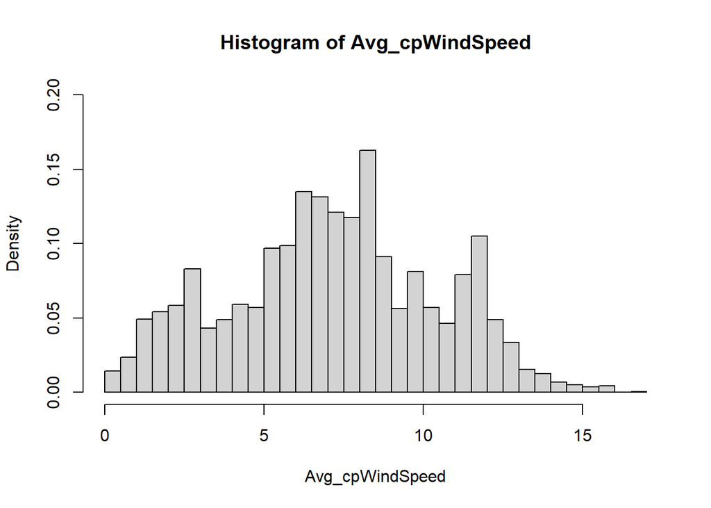

```r
h <-hist(Avg_cpWindSpeed, freq=FALSE, breaks=40,ylim=c(0,0.2))
```

```r
#text(h$mids,h$density,labels=round(h$density,digits=3), adj=c(0.5, -0.5), cex=.8)
#breaks=c(0,0.5,1,1.5,2,2.5,3,3.5,4,4.5,5,5.5,6,6.5,7,7.5,8,8.5,9,9.5,10,10.5,11,11.5,12,12.5,13,13.5,14,14.5,15,15.5,16,16.5,17,17.5,18)
```

Mean seeing spread vs wind speed

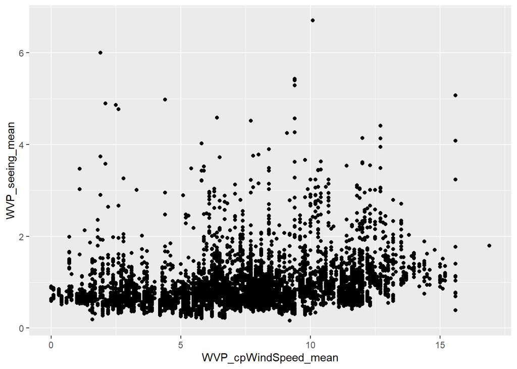

```r
ggplot(df202204_VG_P2_W_j, aes(x=WVP_cpWindSpeed_mean, y=WVP_seeing_mean)) + geom_point()
```

Wind speed neasurements vs vent gate East plot

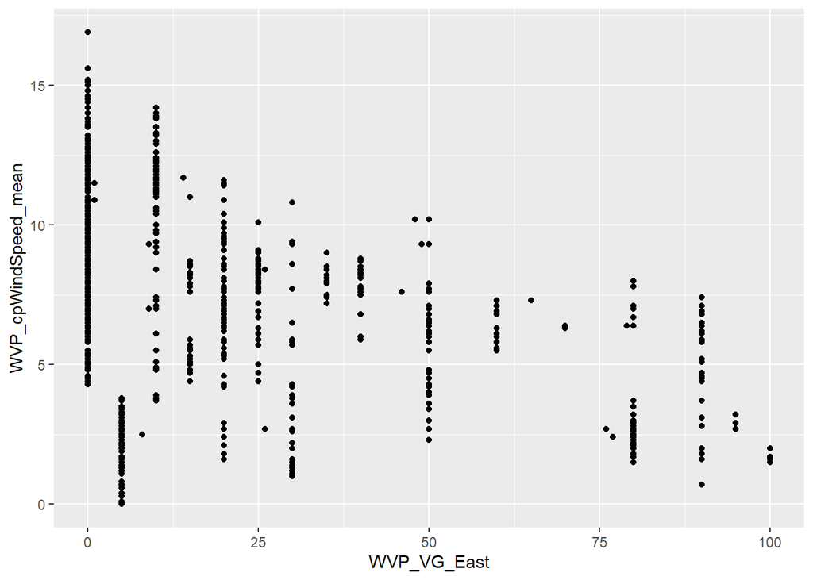

```r
#Mean wind speed neasurements per Vent gate plot
ggplot(df202204_VG_P2_W_j, aes(x=WVP_VG_East, y=WVP_cpWindSpeed_mean)) + geom_point()
```

Wind speed neasurements vs vent gate West plot

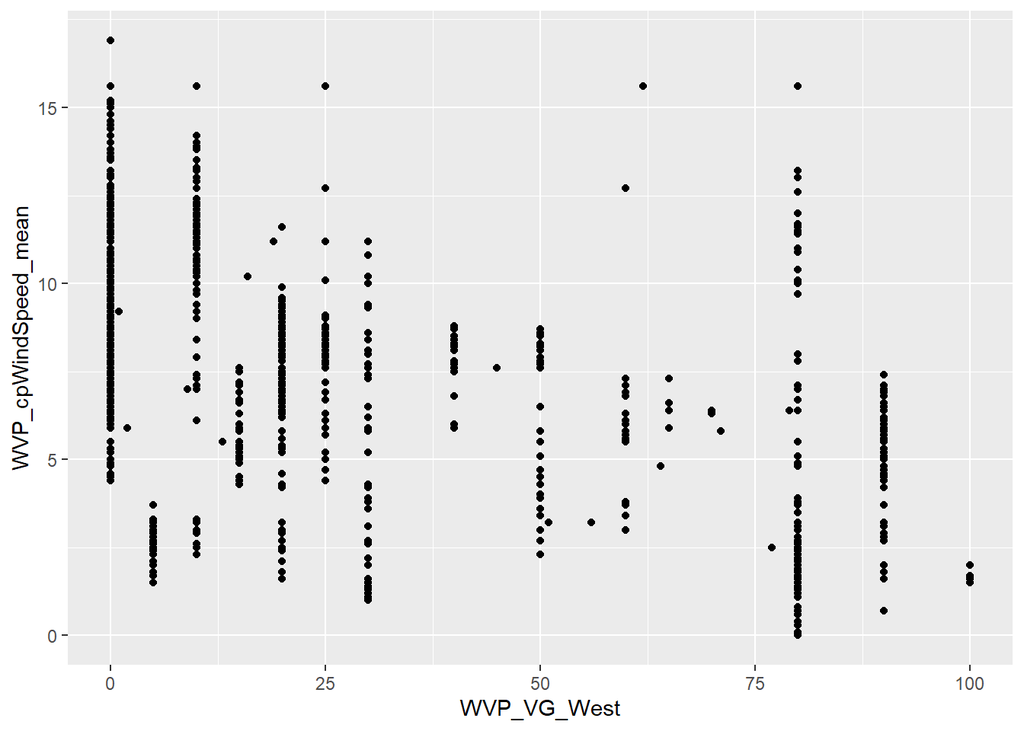

```r
ggplot(df202204_VG_P2_W_j, aes(x=WVP_VG_West, y=WVP_cpWindSpeed_mean)) + geom_point()
```

Total effect of wind on seeing

```r
y <- df202204_VG_P2_W_j$WVP_seeing_mean
x <- df202204_VG_P2_W_j$WVP_cpWindSpeed_mean

relation <- lm(y~x)

print(summary(relation))
```

```
##
## Call:
## lm(formula = y ~ x)
##
## Residuals:
##     Min      1Q  Median      3Q     Max
## -0.8819 -0.3074 -0.1186  0.1106  5.6738
##
## Coefficients:
##             Estimate Std. Error t value Pr(>|t|)
## (Intercept) 0.586410   0.017244   34.01   <2e-16 ***
## x           0.043943   0.002179   20.17   <2e-16 ***
## ---
## Signif. codes:  0 '***' 0.001 '**' 0.01 '*' 0.05 '.' 0.1 ' ' 1
##
## Residual standard error: 0.5386 on 5722 degrees of freedom
## Multiple R-squared:  0.06638,    Adjusted R-squared:  0.06622
## F-statistic: 406.8 on 1 and 5722 DF,  p-value: < 2.2e-16
```

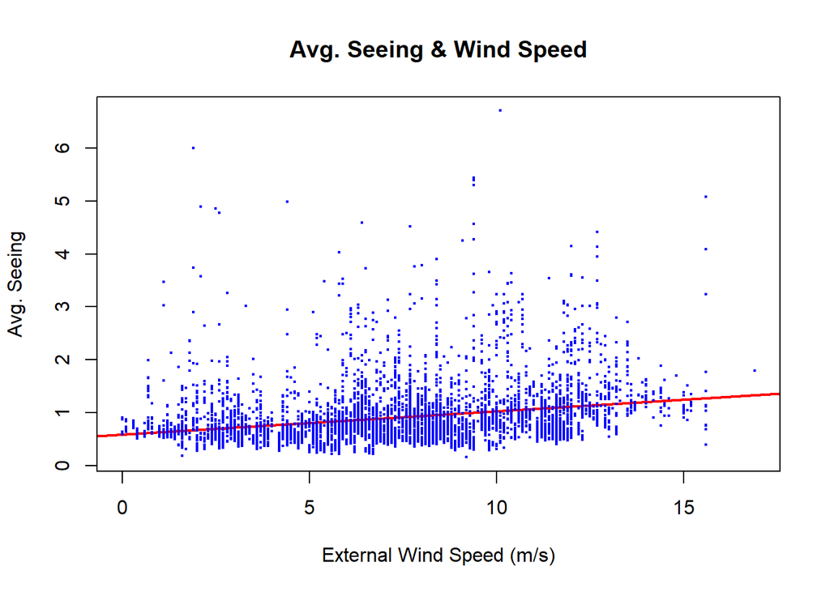

```r
# Plot the chart.
plot(x,y,col = "blue", main = "Avg. Seeing & Wind Speed",abline(lm(y~x), col="red", lwd=2),cex = .25,pch = 1,xlab = "External Wind Speed (m/s)",ylab = "Avg. Seeing")
```

Total effect of wind on seeing. Vent gate openess class is identified by color.

```r
#Generate vent gate bins

df202204_VG_P2_W_k <- df202204_VG_P2_W_j %>% mutate(WVP_VG_East_bin=cut(WVP_VG_East, breaks = c(-1,0,20,40,60,80,100)), WVP_VG_West_bin=cut(WVP_VG_West, breaks = c(-1,0,20,40,60,80,100)))

y <- df202204_VG_P2_W_k$WVP_seeing_mean
x <- df202204_VG_P2_W_k$WVP_cpWindSpeed_mean
vg_east <- df202204_VG_P2_W_k$WVP_VG_East_bin
vg_west <- df202204_VG_P2_W_k$WVP_VG_West_bin

relation <- lm(y~x)

print(summary(relation))
```

```
##
## Call:
## lm(formula = y ~ x)
##
## Residuals:
##     Min      1Q  Median      3Q     Max
## -0.8819 -0.3074 -0.1186  0.1106  5.6738
##
## Coefficients:
##             Estimate Std. Error t value Pr(>|t|)
## (Intercept) 0.586410   0.017244   34.01   <2e-16 ***
## x           0.043943   0.002179   20.17   <2e-16 ***
## ---
## Signif. codes:  0 '***' 0.001 '**' 0.01 '*' 0.05 '.' 0.1 ' ' 1
##
## Residual standard error: 0.5386 on 5722 degrees of freedom
## Multiple R-squared:  0.06638,    Adjusted R-squared:  0.06622
## F-statistic: 406.8 on 1 and 5722 DF,  p-value: < 2.2e-16
```

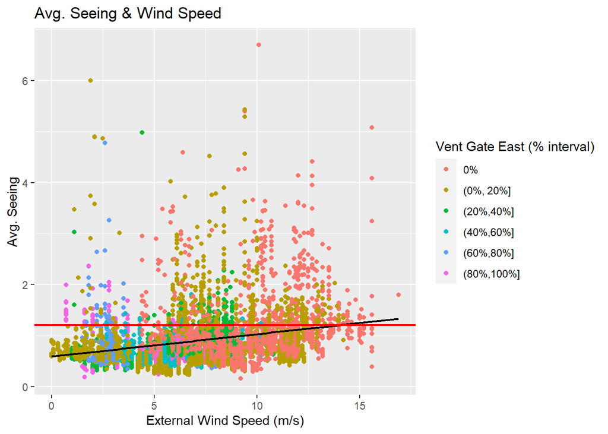

```r
ggplot(df202204_VG_P2_W_k, aes(x,y, color=factor(vg_east))) + geom_point(alpha = 1) + geom_smooth(method = "lm",formula=y~x, colour="black", se = FALSE, size=.8) + labs(title="Avg. Seeing & Wind Speed") + xlab("External Wind Speed (m/s)") + ylab("Avg. Seeing") + geom_hline(yintercept = 1.2, colour="red", size=.8) + scale_colour_discrete(name="Vent Gate East (% interval)", labels=c("0%","(0%, 20%]","(20%,40%]", "(40%,60%]", "(60%,80%]", "(80%,100%]"))
```

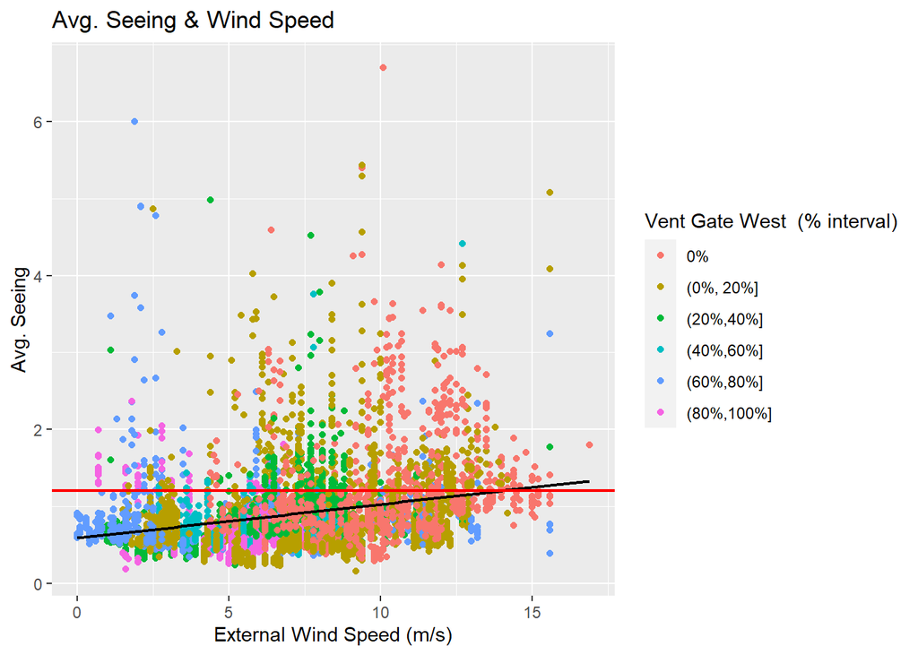

```r
ggplot(df202204_VG_P2_W_k, aes(x,y, color=factor(vg_west))) + geom_point(alpha = 1) + geom_smooth(method = "lm",formula=y~x, colour="black", se = FALSE, size=.8) + labs(title="Avg. Seeing & Wind Speed") + xlab("External Wind Speed (m/s)") + ylab("Avg. Seeing") + geom_hline(yintercept = 1.2, colour="red", size=.8) + scale_colour_discrete(name="Vent Gate West  (% interval)", labels=c("0%","(0%, 20%]","(20%,40%]", "(40%,60%]", "(60%,80%]", "(80%,100%]"))
```

Direct effect of wind on seeing (controling for vent gate openess).

```r
y <- df202204_VG_P2_W_j$WVP_seeing_mean
wind <- df202204_VG_P2_W_j$WVP_cpWindSpeed_mean
vg_east <- df202204_VG_P2_W_j$WVP_VG_East
vg_west <- df202204_VG_P2_W_j$WVP_VG_West


relation <- lm(y~wind + vg_east + vg_west)

print(summary(relation))
```

```
##
## Call:
## lm(formula = y ~ wind + vg_east + vg_west)
##
## Residuals:
##     Min      1Q  Median      3Q     Max
## -0.8609 -0.2952 -0.1155  0.0986  5.6232
##
## Coefficients:
##               Estimate Std. Error t value Pr(>|t|)
## (Intercept)  0.7543012  0.0247135  30.522  < 2e-16 ***
## wind         0.0323310  0.0024901  12.984  < 2e-16 ***
## vg_east     -0.0014919  0.0003373  -4.422 9.94e-06 ***
## vg_west     -0.0015437  0.0002965  -5.206 1.99e-07 ***
## ---
## Signif. codes:  0 '***' 0.001 '**' 0.01 '*' 0.05 '.' 0.1 ' ' 1
##
## Residual standard error: 0.5345 on 5720 degrees of freedom
## Multiple R-squared:  0.08093,    Adjusted R-squared:  0.08045
## F-statistic: 167.9 on 3 and 5720 DF,  p-value: < 2.2e-16
```

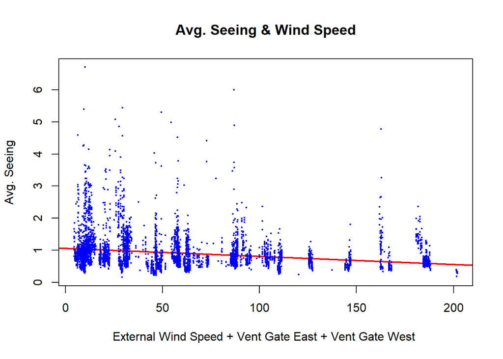

```r
# Plot the chart.
x <- wind + vg_east + vg_west

plot(x,y,col = "blue", main = "Avg. Seeing & Wind Speed",abline(lm(y~x), col="red", lwd=2),cex = .25,pch = 1,xlab = "External Wind Speed + Vent Gate East + Vent Gate West ",ylab = "Avg. Seeing")
```

Get date part

```r
library(lubridate)
df202204_VG_P2_W_l <- df202204_VG_P2_W_j %>% mutate(WVP_VG_date=lubridate::date(df202204_VG_P2_W_j$WVP_VG_date_time))
str(df202204_VG_P2_W_l)
```

```
## 'data.frame':    5724 obs. of  12 variables:
##  $ WVP_P2_ind          : num  1 1 1 1 1 1 1 1 1 1 ...
##  $ WVP_Ext_Wind_ind    : num  1 0 0 0 0 0 0 0 1 0 ...
##  $ WVP_Eq_Wind_group   : num  1 1 1 1 1 1 1 1 2 2 ...
##  $ WVP_cpWind_date_time: POSIXct, format: "2022-04-02 22:59:59" "2022-04-02 22:59:59" ...
##  $ WVP_VG_date_time    : POSIXct, format: "2022-04-02 23:01:09" "2022-04-02 23:01:43" ...
##  $ WVP_P2_date_time    : POSIXct, format: "2022-04-02 23:01:14" "2022-04-02 23:01:44" ...
##  $ WVP_VG_date_time_num: num  1.65e+09 1.65e+09 1.65e+09 1.65e+09 1.65e+09 ...
##  $ WVP_cpWindSpeed_mean: num  2.7 2.7 2.7 2.7 2.7 2.7 2.7 2.7 2.7 2.7 ...
##  $ WVP_VG_East         : num  30 30 30 30 30 30 30 30 30 30 ...
##  $ WVP_VG_West         : num  30 30 30 30 30 30 30 30 30 30 ...
##  $ WVP_seeing_mean     : num  0.398 0.446 0.429 0.418 0.339 ...
##  $ WVP_VG_date         : Date, format: "2022-04-02" "2022-04-02" ...
```

```r
head(df202204_VG_P2_W_l)
```

```
##   WVP_P2_ind WVP_Ext_Wind_ind WVP_Eq_Wind_group WVP_cpWind_date_time
## 1          1                1                 1  2022-04-02 22:59:59
## 2          1                0                 1  2022-04-02 22:59:59
## 3          1                0                 1  2022-04-02 22:59:59
## 4          1                0                 1  2022-04-02 22:59:59
## 5          1                0                 1  2022-04-02 22:59:59
## 6          1                0                 1  2022-04-02 22:59:59
##      WVP_VG_date_time    WVP_P2_date_time WVP_VG_date_time_num
## 1 2022-04-02 23:01:09 2022-04-02 23:01:14           1648965670
## 2 2022-04-02 23:01:43 2022-04-02 23:01:44           1648965703
## 3 2022-04-02 23:02:10 2022-04-02 23:02:14           1648965730
## 4 2022-04-02 23:02:39 2022-04-02 23:02:44           1648965760
## 5 2022-04-02 23:03:12 2022-04-02 23:03:14           1648965792
## 6 2022-04-02 23:03:30 2022-04-02 23:03:44           1648965811
##   WVP_cpWindSpeed_mean WVP_VG_East WVP_VG_West WVP_seeing_mean WVP_VG_date
## 1                  2.7          30          30           0.398  2022-04-02
## 2                  2.7          30          30           0.446  2022-04-02
## 3                  2.7          30          30           0.429  2022-04-02
## 4                  2.7          30          30           0.418  2022-04-02
## 5                  2.7          30          30           0.339  2022-04-02
## 6                  2.7          30          30           0.589  2022-04-02
```

```r
df202204_VG_P2_W_l$OP_in = 7*(df202204_VG_P2_W_l$WVP_VG_date == as.numeric(as.Date("2022-04-01"))) +
1*(df202204_VG_P2_W_l$WVP_VG_date == as.numeric(as.Date("2022-04-02"))) +
1*(df202204_VG_P2_W_l$WVP_VG_date == as.numeric(as.Date("2022-04-03"))) +
1*(df202204_VG_P2_W_l$WVP_VG_date == as.numeric(as.Date("2022-04-04"))) +
1*(df202204_VG_P2_W_l$WVP_VG_date == as.numeric(as.Date("2022-04-05"))) +
1*(df202204_VG_P2_W_l$WVP_VG_date == as.numeric(as.Date("2022-04-06"))) +
3*(df202204_VG_P2_W_l$WVP_VG_date == as.numeric(as.Date("2022-04-07"))) +
3*(df202204_VG_P2_W_l$WVP_VG_date == as.numeric(as.Date("2022-04-08"))) +
3*(df202204_VG_P2_W_l$WVP_VG_date == as.numeric(as.Date("2022-04-09"))) +
3*(df202204_VG_P2_W_l$WVP_VG_date == as.numeric(as.Date("2022-04-10"))) +
4*(df202204_VG_P2_W_l$WVP_VG_date == as.numeric(as.Date("2022-04-11"))) +
4*(df202204_VG_P2_W_l$WVP_VG_date == as.numeric(as.Date("2022-04-12"))) +
4*(df202204_VG_P2_W_l$WVP_VG_date == as.numeric(as.Date("2022-04-13"))) +
4*(df202204_VG_P2_W_l$WVP_VG_date == as.numeric(as.Date("2022-04-14"))) +
6*(df202204_VG_P2_W_l$WVP_VG_date == as.numeric(as.Date("2022-04-15"))) +
6*(df202204_VG_P2_W_l$WVP_VG_date == as.numeric(as.Date("2022-04-16"))) +
6*(df202204_VG_P2_W_l$WVP_VG_date == as.numeric(as.Date("2022-04-17"))) +
9*(df202204_VG_P2_W_l$WVP_VG_date == as.numeric(as.Date("2022-04-18"))) +
9*(df202204_VG_P2_W_l$WVP_VG_date == as.numeric(as.Date("2022-04-19"))) +
9*(df202204_VG_P2_W_l$WVP_VG_date == as.numeric(as.Date("2022-04-20"))) +
9*(df202204_VG_P2_W_l$WVP_VG_date == as.numeric(as.Date("2022-04-21"))) +
9*(df202204_VG_P2_W_l$WVP_VG_date == as.numeric(as.Date("2022-04-22"))) +
7*(df202204_VG_P2_W_l$WVP_VG_date == as.numeric(as.Date("2022-04-23"))) +
7*(df202204_VG_P2_W_l$WVP_VG_date == as.numeric(as.Date("2022-04-24"))) +
7*(df202204_VG_P2_W_l$WVP_VG_date == as.numeric(as.Date("2022-04-25"))) +
7*(df202204_VG_P2_W_l$WVP_VG_date == as.numeric(as.Date("2022-04-26"))) +
7*(df202204_VG_P2_W_l$WVP_VG_date == as.numeric(as.Date("2022-04-27"))) +
3*(df202204_VG_P2_W_l$WVP_VG_date == as.numeric(as.Date("2022-04-28"))) +
3*(df202204_VG_P2_W_l$WVP_VG_date == as.numeric(as.Date("2022-04-29"))) +
3*(df202204_VG_P2_W_l$WVP_VG_date == as.numeric(as.Date("2022-04-30")))

str(df202204_VG_P2_W_l)
```

```
## 'data.frame':    5724 obs. of  13 variables:
##  $ WVP_P2_ind          : num  1 1 1 1 1 1 1 1 1 1 ...
##  $ WVP_Ext_Wind_ind    : num  1 0 0 0 0 0 0 0 1 0 ...
##  $ WVP_Eq_Wind_group   : num  1 1 1 1 1 1 1 1 2 2 ...
##  $ WVP_cpWind_date_time: POSIXct, format: "2022-04-02 22:59:59" "2022-04-02 22:59:59" ...
##  $ WVP_VG_date_time    : POSIXct, format: "2022-04-02 23:01:09" "2022-04-02 23:01:43" ...
##  $ WVP_P2_date_time    : POSIXct, format: "2022-04-02 23:01:14" "2022-04-02 23:01:44" ...
##  $ WVP_VG_date_time_num: num  1.65e+09 1.65e+09 1.65e+09 1.65e+09 1.65e+09 ...
##  $ WVP_cpWindSpeed_mean: num  2.7 2.7 2.7 2.7 2.7 2.7 2.7 2.7 2.7 2.7 ...
##  $ WVP_VG_East         : num  30 30 30 30 30 30 30 30 30 30 ...
##  $ WVP_VG_West         : num  30 30 30 30 30 30 30 30 30 30 ...
##  $ WVP_seeing_mean     : num  0.398 0.446 0.429 0.418 0.339 ...
##  $ WVP_VG_date         : Date, format: "2022-04-02" "2022-04-02" ...
##  $ OP_in               : num  1 1 1 1 1 1 1 1 1 1 ...
```

```r
head(df202204_VG_P2_W_l)
```

```
##   WVP_P2_ind WVP_Ext_Wind_ind WVP_Eq_Wind_group WVP_cpWind_date_time
## 1          1                1                 1  2022-04-02 22:59:59
## 2          1                0                 1  2022-04-02 22:59:59
## 3          1                0                 1  2022-04-02 22:59:59
## 4          1                0                 1  2022-04-02 22:59:59
## 5          1                0                 1  2022-04-02 22:59:59
## 6          1                0                 1  2022-04-02 22:59:59
##      WVP_VG_date_time    WVP_P2_date_time WVP_VG_date_time_num
## 1 2022-04-02 23:01:09 2022-04-02 23:01:14           1648965670
## 2 2022-04-02 23:01:43 2022-04-02 23:01:44           1648965703
## 3 2022-04-02 23:02:10 2022-04-02 23:02:14           1648965730
## 4 2022-04-02 23:02:39 2022-04-02 23:02:44           1648965760
## 5 2022-04-02 23:03:12 2022-04-02 23:03:14           1648965792
## 6 2022-04-02 23:03:30 2022-04-02 23:03:44           1648965811
##   WVP_cpWindSpeed_mean WVP_VG_East WVP_VG_West WVP_seeing_mean WVP_VG_date
## 1                  2.7          30          30           0.398  2022-04-02
## 2                  2.7          30          30           0.446  2022-04-02
## 3                  2.7          30          30           0.429  2022-04-02
## 4                  2.7          30          30           0.418  2022-04-02
## 5                  2.7          30          30           0.339  2022-04-02
## 6                  2.7          30          30           0.589  2022-04-02
##   OP_in
## 1     1
## 2     1
## 3     1
## 4     1
## 5     1
## 6     1
```

```r
summary(df202204_VG_P2_W_l$OP_in)
```

```
##    Min. 1st Qu.  Median    Mean 3rd Qu.    Max.
##   1.000   3.000   7.000   6.382   9.000   9.000
```

```r
save(df202204_VG_P2_W_l, file="df202204_VG_P2_W_l.RData")
write.csv(df202204_VG_P2_W_l, "df202204_VG_P2_W_l.csv")
```

```r
#Generate vent gate bins


y <- df202204_VG_P2_W_l$WVP_seeing_mean
x <- df202204_VG_P2_W_l$WVP_cpWindSpeed_mean

relation <- lm(y~x)

print(summary(relation))
```

```
##
## Call:
## lm(formula = y ~ x)
##
## Residuals:
##     Min      1Q  Median      3Q     Max
## -0.8819 -0.3074 -0.1186  0.1106  5.6738
##
## Coefficients:
##             Estimate Std. Error t value Pr(>|t|)
## (Intercept) 0.586410   0.017244   34.01   <2e-16 ***
## x           0.043943   0.002179   20.17   <2e-16 ***
## ---
## Signif. codes:  0 '***' 0.001 '**' 0.01 '*' 0.05 '.' 0.1 ' ' 1
##
## Residual standard error: 0.5386 on 5722 degrees of freedom
## Multiple R-squared:  0.06638,    Adjusted R-squared:  0.06622
## F-statistic: 406.8 on 1 and 5722 DF,  p-value: < 2.2e-16
```

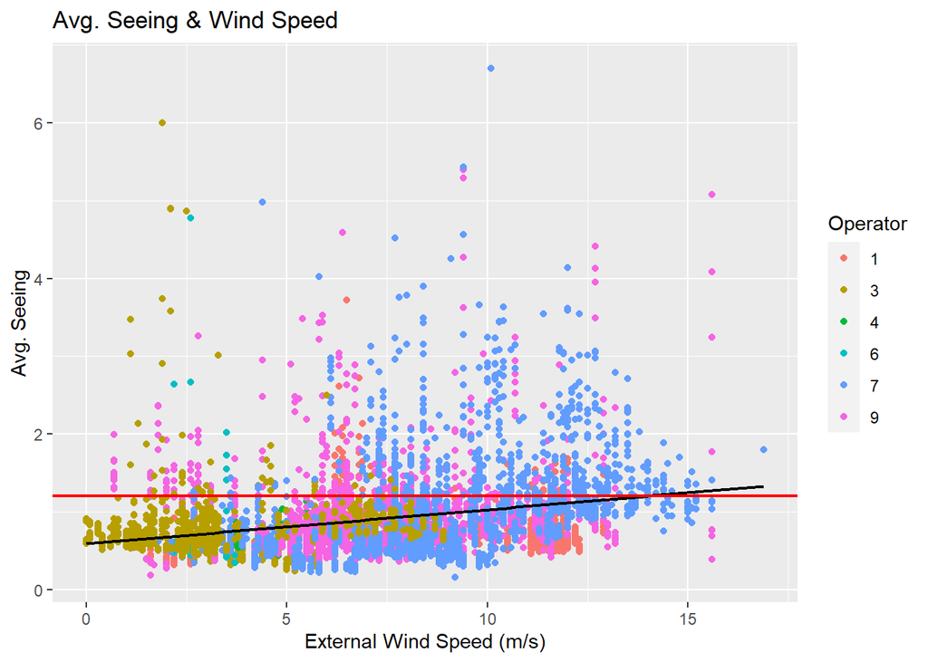

```r
ggplot(df202204_VG_P2_W_l, aes(x,y, color=factor(OP_in))) + geom_point(alpha = 1) + geom_smooth(method = "lm",formula=y~x, colour="black", se = FALSE, size=.8) + labs(title="Avg. Seeing & Wind Speed") + xlab("External Wind Speed (m/s)") + ylab("Avg. Seeing") + geom_hline(yintercept = 1.2, colour="red", size=.8) + scale_colour_discrete(name="Operator")
```

```r
library(gmodels)
CrossTable(df202204_VG_P2_W_l$OP_in)
```

```
##
##
##    Cell Contents
## |-------------------------|
## |                       N |
## |         N / Table Total |
## |-------------------------|
##
##
## Total Observations in Table:  5724
##
##
##           |         1 |         3 |         4 |         6 |         7 |
##           |-----------|-----------|-----------|-----------|-----------|
##           |       546 |      1072 |        62 |        29 |      1895 |
##           |     0.095 |     0.187 |     0.011 |     0.005 |     0.331 |
##           |-----------|-----------|-----------|-----------|-----------|
##
##
##           |         9 |
##           |-----------|
##           |      2120 |
##           |     0.370 |
##           |-----------|
##
##
##
##
```

Operator #1

```r
#Generate vent gate bins
df202204_VG_P2_W_m=df202204_VG_P2_W_l[df202204_VG_P2_W_l$OP_in==1,]

y <- df202204_VG_P2_W_m$WVP_seeing_mean
x <- df202204_VG_P2_W_m$WVP_cpWindSpeed_mean

relation <- lm(y~x)

print(summary(relation))
```

```
##
## Call:
## lm(formula = y ~ x)
##
## Residuals:
##      Min       1Q   Median       3Q      Max
## -0.54016 -0.20442 -0.07085  0.07042  2.89424
##
## Coefficients:
##              Estimate Std. Error t value Pr(>|t|)
## (Intercept)  0.871210   0.048106  18.110   <2e-16 ***
## x           -0.006839   0.004961  -1.379    0.169
## ---
## Signif. codes:  0 '***' 0.001 '**' 0.01 '*' 0.05 '.' 0.1 ' ' 1
##
## Residual standard error: 0.3597 on 544 degrees of freedom
## Multiple R-squared:  0.003481,   Adjusted R-squared:  0.001649
## F-statistic:   1.9 on 1 and 544 DF,  p-value: 0.1686
```

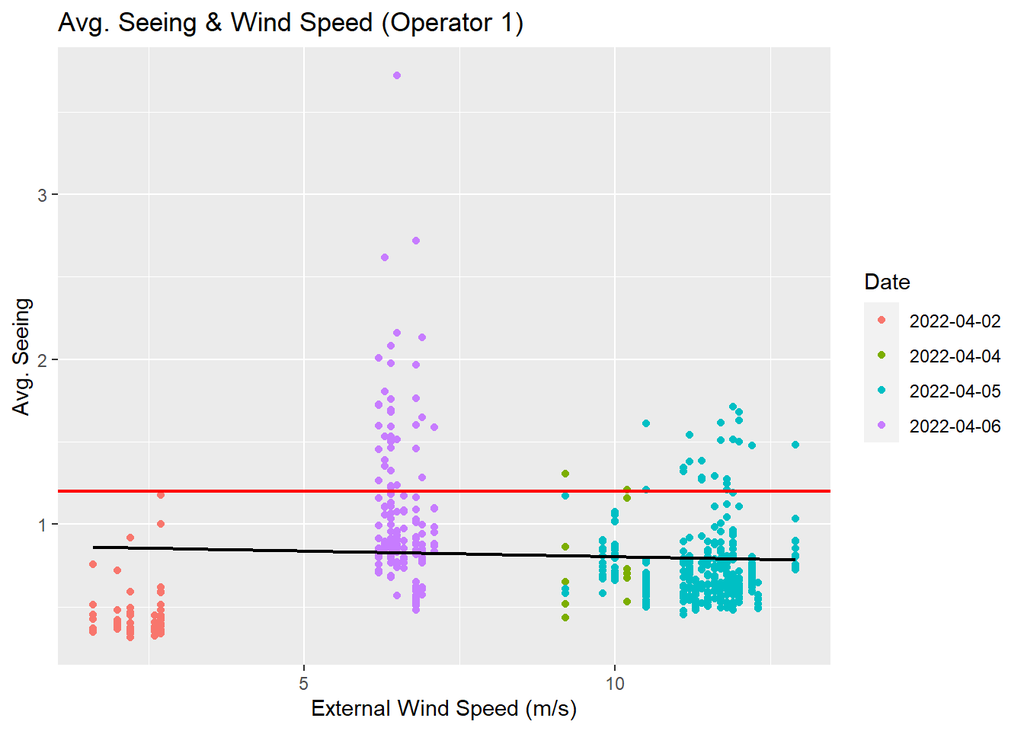

```r
ggplot(df202204_VG_P2_W_m, aes(x,y, color=factor(WVP_VG_date))) + geom_point(alpha = 1) + geom_smooth(method = "lm",formula=y~x, colour="black", se = FALSE, size=.8) + labs(title="Avg. Seeing & Wind Speed (Operator 1)") + xlab("External Wind Speed (m/s)") + ylab("Avg. Seeing") + geom_hline(yintercept = 1.2, colour="red", size=.8) + scale_colour_discrete(name="Date")
```

Operator #3

```r
#Generate vent gate bins
df202204_VG_P2_W_m=df202204_VG_P2_W_l[df202204_VG_P2_W_l$OP_in==3,]

y <- df202204_VG_P2_W_m$WVP_seeing_mean
x <- df202204_VG_P2_W_m$WVP_cpWindSpeed_mean

relation <- lm(y~x)

print(summary(relation))
```

```
##
## Call:
## lm(formula = y ~ x)
##
## Residuals:
##     Min      1Q  Median      3Q     Max
## -0.5095 -0.1753 -0.0603  0.0768  5.2720
##
## Coefficients:
##             Estimate Std. Error t value Pr(>|t|)
## (Intercept) 0.718396   0.023995  29.939   <2e-16 ***
## x           0.005606   0.006115   0.917    0.359
## ---
## Signif. codes:  0 '***' 0.001 '**' 0.01 '*' 0.05 '.' 0.1 ' ' 1
##
## Residual standard error: 0.413 on 1070 degrees of freedom
## Multiple R-squared:  0.0007848,  Adjusted R-squared:  -0.000149
## F-statistic: 0.8404 on 1 and 1070 DF,  p-value: 0.3595
```

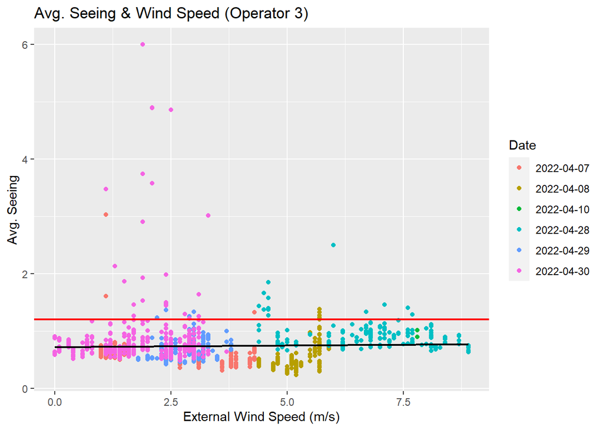

```r
ggplot(df202204_VG_P2_W_m, aes(x,y, color=factor(WVP_VG_date))) + geom_point(alpha = 1) + geom_smooth(method = "lm",formula=y~x, colour="black", se = FALSE, size=.8) + labs(title="Avg. Seeing & Wind Speed (Operator 3)") + xlab("External Wind Speed (m/s)") + ylab("Avg. Seeing") + geom_hline(yintercept = 1.2, colour="red", size=.8) + scale_colour_discrete(name="Date")
```

Operator #7

```r
#Generate vent gate bins
df202204_VG_P2_W_m=df202204_VG_P2_W_l[df202204_VG_P2_W_l$OP_in==7,]

y <- df202204_VG_P2_W_m$WVP_seeing_mean
x <- df202204_VG_P2_W_m$WVP_cpWindSpeed_mean

relation <- lm(y~x)

print(summary(relation))
```

```
##
## Call:
## lm(formula = y ~ x)
##
## Residuals:
##     Min      1Q  Median      3Q     Max
## -0.9235 -0.4130 -0.1712  0.1928  5.5394
##
## Coefficients:
##             Estimate Std. Error t value Pr(>|t|)
## (Intercept) 0.254514   0.047679   5.338 1.05e-07 ***
## x           0.090103   0.005178  17.403  < 2e-16 ***
## ---
## Signif. codes:  0 '***' 0.001 '**' 0.01 '*' 0.05 '.' 0.1 ' ' 1
##
## Residual standard error: 0.6418 on 1893 degrees of freedom
## Multiple R-squared:  0.1379, Adjusted R-squared:  0.1375
## F-statistic: 302.9 on 1 and 1893 DF,  p-value: < 2.2e-16
```

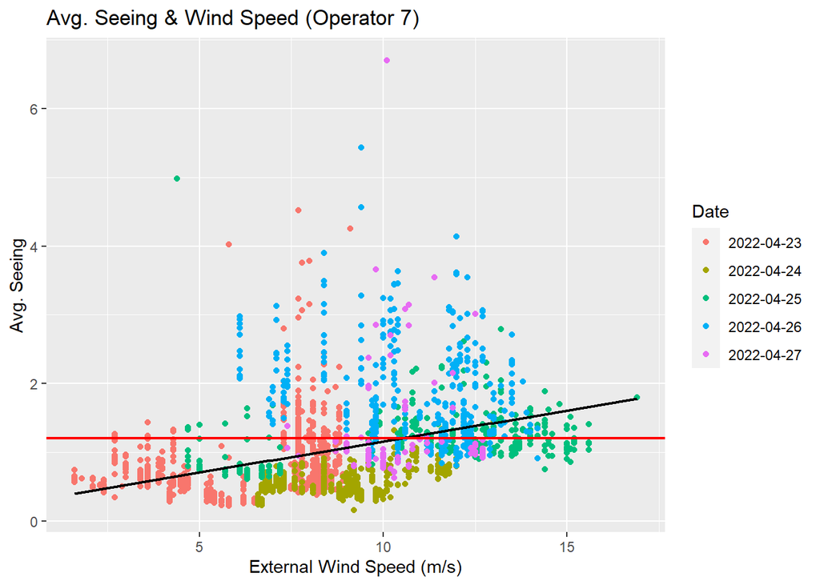

```r
ggplot(df202204_VG_P2_W_m, aes(x,y, color=factor(WVP_VG_date))) + geom_point(alpha = 1) + geom_smooth(method = "lm",formula=y~x, colour="black", se = FALSE, size=.8) + labs(title="Avg. Seeing & Wind Speed (Operator 7)") + xlab("External Wind Speed (m/s)") + ylab("Avg. Seeing") + geom_hline(yintercept = 1.2, colour="red", size=.8) + scale_colour_discrete(name="Date")
```

Operator #9

```r
#Generate vent gate bins
df202204_VG_P2_W_m=df202204_VG_P2_W_l[df202204_VG_P2_W_l$OP_in==9,]

y <- df202204_VG_P2_W_m$WVP_seeing_mean
x <- df202204_VG_P2_W_m$WVP_cpWindSpeed_mean

relation <- lm(y~x)

print(summary(relation))
```

```
##
## Call:
## lm(formula = y ~ x)
##
## Residuals:
##     Min      1Q  Median      3Q     Max
## -0.7023 -0.2673 -0.1336  0.0826  4.4577
##
## Coefficients:
##             Estimate Std. Error t value Pr(>|t|)
## (Intercept) 0.707341   0.034687  20.392  < 2e-16 ***
## x           0.024675   0.004457   5.537 3.46e-08 ***
## ---
## Signif. codes:  0 '***' 0.001 '**' 0.01 '*' 0.05 '.' 0.1 ' ' 1
##
## Residual standard error: 0.4909 on 2118 degrees of freedom
## Multiple R-squared:  0.01427,    Adjusted R-squared:  0.0138
## F-statistic: 30.66 on 1 and 2118 DF,  p-value: 3.462e-08
```

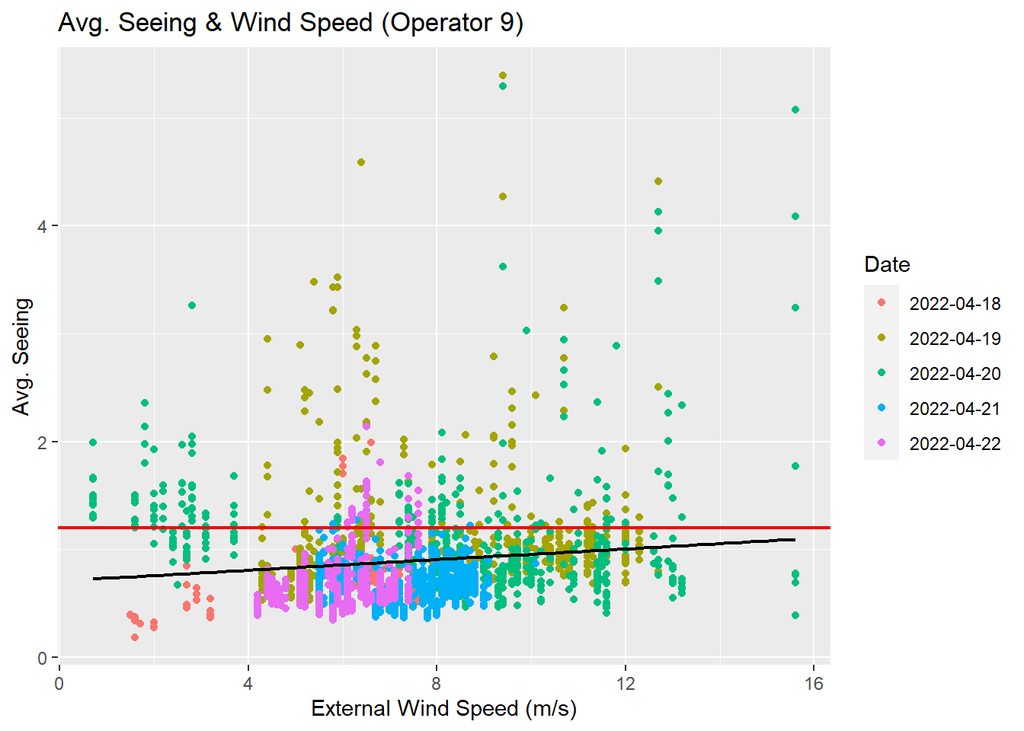

```r
ggplot(df202204_VG_P2_W_m, aes(x,y, color=factor(WVP_VG_date))) + geom_point(alpha = 1) + geom_smooth(method = "lm",formula=y~x, colour="black", se = FALSE, size=.8) + labs(title="Avg. Seeing & Wind Speed (Operator 9)") + xlab("External Wind Speed (m/s)") + ylab("Avg. Seeing") + geom_hline(yintercept = 1.2, colour="red", size=.8) + scale_colour_discrete(name="Date")
```

## ====================End===================